> CSCI 440 Machine Learning  
> Spring 2021, Biola University  
> Instructor : Genti Buzi

# Some Python Preliminaries (Probability, MatPlotLib, NumPy, etc)

## Importing Libraries

```
matplotlib : used for plotting
numpy      : implementation of many useful mathematical operations
```

```python
import numpy as np
import matplotlib.pyplot as plt
```

## Plots in $\mathbb{R}^2$

### Example plotting simple functions.

The sign function \begin{equation*} f(x)=\text{sign}(x) \end{equation*} can be approximated by the hyperbolic tangent function  
\begin{equation*} f(x)=\tanh(kx) \end{equation*} for $k$ large enough.  
The numpy library has implementations of all the above functions.

```python
x=np.linspace(-5,5,200)  #generates 200 equally spaced points in  [-5, 5),  starting from value -5 not including 5
y1=np.sign(x);           #gets the corresponding value for those points based on the sign function

#plot the sign function based on the points generated above
f1, ax=plt.subplots()
ax.plot(x,y1, color='black', linewidth=2)
ax.set_title("Approximations of the Sign function")
#plot the tanh function on the same plot, for 4 different k values
k=[0.5,1,2,10]
col=["red","brown","green", "blue"]
for i in range(4):
    yk=np.tanh(k[i]*x)
    ax.plot(x,yk,color=col[i], linewidth=2)
ax.set_xlabel("x")
ax.set_ylabel("y")
#create a grid and a legend
ax.grid()
ax.legend(("sign(x)", "tanh(x/2)", "tanh(x)", "tanh(2x)", "tanh(10x)"))
```

[figure not shown]

## Probability and Random Variables

### Generating random values

One can use the *random* module of *numpy* to generate random numbers from different distributions.  
Lets try a few different distributions.

> - Simulating the roll of a die : randomnly generate $n$ numbers from the {1,2,3,4,5,6} set, each equally likely to be picked.  
>   Use **randint** function in the *random* module of *numpy*, can be used to generate integer numbers from a uniform distribution.
>   > - Generate 10,000 random numbers. Count and plot the frequency of occurence for each value

```python
n=10000
# 1
r=np.random.randint(1,7,size=n)
print("First 10 random values generated :", r[:10])

x=list(r);
values=[1,2,3,4,5,6]
frequency=[];
for v in values:
    frequency.append(x.count(v))

fig, ax1=plt.subplots();
ax1.bar(values, frequency)
ax1.set_ylabel('frequency')
ax1.set_xlabel('value')
ax1.set_title('Distribution of values for 10,000 rolls')
```

```
First 10 random values generated : [4 4 1 6 2 5 2 1 2 4]
```

[figure not shown]

> - Randomly generate numbers uniformly in the $\left[0,1\right]$ interval.  
>   Can use **rand** function in the *random* module of *numpy*.
> - Randomly generate numbers uniformly in the $\left[-5,5\right]$ interval.
>   > 1. Generate numbers uniformly in $\left[0,1\right]$
>   > 2. Scale the by 10 by multiplying by 10), so the numbers are distributed uniformly in $\left[0,10\right]$
>   > 3. Shift by 5 by subtracting 5, so the numbers are distributed uniformly in $\left[-5,5\right]$

```python
n=10000
ru=np.random.rand(n)
print(10, "random numbers between 0 and 1:\n", ru[:10])

ru2=ru*10-5
print("The numbers above shifted to -5,5 range:\n", ru2[:10])
```

```
10 random numbers between 0 and 1:
 [0.91513287 0.2429633  0.22091642 0.70134504 0.81035603 0.87256332
 0.47538636 0.47408078 0.08027397 0.4694664 ]
The numbers above shifted to -5,5 range:
 [ 4.15132873 -2.57036701 -2.79083575  2.01345044  3.10356026  3.72563317
 -0.24613637 -0.25919219 -4.19726028 -0.305336  ]
```

> - Randomly generate 10,000 values from a Gaussian (normal) distribution with mean $\mu$ and standard deviation $\sigma$.  
>   Using **normal** function in the *random* module of *numpy*.  
>   Density function of the Gaussian is the bell-shaped curve given by \begin{equation*} f(x)=\frac{1}{\sqrt{2\pi \sigma ^2}}e^{-\frac{1}{2}\left(\frac{x-\mu}{\sigma}\right)^2} \end{equation*}
> - Plot the empirical distribution

Note: *scipy.stats* library has a large amount of statistical functions and distributions implemented (https://docs.scipy.org/doc/scipy/reference/stats.html)

```python
n=10000

mu=2
sigma=3
rn=np.random.normal(mu, sigma,n);

print(10, "gaussian random numbers with mean=",mu," and std=", sigma, ":")
print(rn[:10], "\n")

#get histograms - play around with the number of bins etc.
a1, b1=np.histogram(rn,50)
f1, ax2 = plt.subplots()

x=b1[1:];
dx=x[1]-x[0];
y=1./(np.sqrt(2.*np.pi)*sigma)*np.exp(-np.power((x - mu)/sigma, 2.)/2)
ax2.plot(x,y,color='red');
ax2.bar(x-dx/2,a1/n/dx);
ax2.set_title("Gaussian Distribution")
ax2.set_ylabel("density")
ax2.set_xlabel("value")
ax2.legend(['Theoretical','Empirical'])
```

```
10 gaussian random numbers with mean= 2  and std= 3 :
[ 4.88744063 -1.52529125  3.39675928  2.155589    4.64688286  2.40485209
  0.25920088 -1.19943666  0.64332945  0.83581829]
```

[figure not shown]

## NumPy Arrays

NumPy’s main data structure is the (multidimensional) array.

Note: here is a good resource for learning more about NumPy arrays (https://www.oreilly.com/library/view/machine-learning-with/9781491989371/ch01.html)

### Vectors (1D arrays)

```python
v=np.array(np.random.randint(1,100, size=10)) #generate a random array of size 10

a=v[3]   #the 4th element of v (element of index 3, counting starts at 0)
b=v[-1]  #the last element of v
c=v[:4]  #the first 4 elements of v
d=v[2:]  #the last elements of v starting from index 2
e=v[1:5] #the elements of v with index 1,2,3,4
f=v[v>50] #the elements of v that are greater than 50

print("v :", v, "\n")
print(a,b,c,d,e,f, sep="\n")
```

```
v : [ 2 33  5 60 13 61 39 81 24 17]

60
17
[ 2 33  5 60]
[ 5 60 13 61 39 81 24 17]
[33  5 60 13]
[60 61 81]
```

#### Operations

1. operators +,-,* , /, ** (power) are defined as element by element operations
2. Given two vectors \begin{equation*} \begin{matrix} v & = & \left[ v_0,v_1, ...,v_n \right] \\ u & = & \left[ u_0,u_1, ...,u_n \right] \\ \end{matrix} \end{equation*} the **dot product**: $v\cdot u$ is defined \begin{equation*} v\cdot u=v_0u_0+v_1u_1+...+v_nu_n=\sum_{i=0}^{n}v_iu_i \end{equation*}

```python
n=5
v=np.array(np.random.randint(1,100, size=n)) #generate a random array of size n
a=v*10    #the elements of v multiplied by 10
b=v-50   #the elements of v substracted 50
c=v**2   #the square of the elements of v
d=np.sqrt(v) #the square root of the elements of v
e=-v #the negation of v
print("v :", v, "\n")
print(a,b,c,d,e, sep="\n")

u=np.array(np.linspace(0,16,n)) #array consisting of n points between 0 and 16 inclusive
print("\n\nu :", u, "\n")

f=v*u #element by element multiplication
print("f=u*v : ", f, "\n")
g=v+u #element by element addition
print("g=u+v : ", g, "\n")

h=np.dot(u,v)  #dot product of the array
print("h= np.dot(u,v) : ", h, "\n")

#alternatives ways of doing the dot product
h1=u.dot(v)
h2=u @ v #python 3.5 and after only

print(h1,h2, sep="\n")
```

```
v : [22 39  4 79 74]

[220 390  40 790 740]
[-28 -11 -46  29  24]
[ 484 1521   16 6241 5476]
[4.69041576 6.244998   2.         8.88819442 8.60232527]
[-22 -39  -4 -79 -74]


u : [ 0.  4.  8. 12. 16.]

f=u*v :  [   0.  156.   32.  948. 1184.]

g=u+v :  [22. 43. 12. 91. 90.]

h= np.dot(u,v) :  2320.0

2320.0
2320.0
```

### Two dimensional arrays

```python
v1=np.array([[10,20,30,45]]) # 1x4 array (you can think of as row vector)
print(v1, "\n")
v2=np.array([[11],[21],[31],[45]]) # 4x1 array (you can think of as a column vector)
print(v2, "\n")
v3= np.array([[1, 2],[3, 4],[5, 6],[7, 8]]) #2x4 array (you can think of as a matrix)
print(v3,"\n")
v4=v3.T #the transpose of v3
print(v4,"\n")
```

```
[[10 20 30 45]]

[[11]
 [21]
 [31]
 [45]]

[[1 2]
 [3 4]
 [5 6]
 [7 8]]

[[1 3 5 7]
 [2 4 6 8]]
```

#### Operations

1. Selection of elements etc. similar to vectors
2. operators +,-,* , /, ** (power) are defined as element by element operations (as in vectors)
3. Matrix multiplication: use the dot product.

```python
A=np.array(np.random.rand(5,3)) #generate a 5x3 array with random values in 0..1
print("A : \n", A, "\n")

a21=A[2,1] #the element with row index 2 and column index 1
c1=A[:,1] #the column with index 1
r2=A[2,:] #the row with index 2
rl=A[3:, :] #the rows of A with index >=3

print(a21,c1,r2,rl, sep="\n")

v=np.array(np.random.randint(1,100, size=5)) #generate a random row vector of size 5
print("v :", v, "\n")

u=v @ A #vector-matrix multiplication
print("u= v @ A : \n", u, "\n")
```

```
A :
 [[0.74117468 0.74938218 0.10913808]
 [0.85646168 0.78471416 0.33491499]
 [0.43740461 0.92936231 0.27988694]
 [0.79743927 0.05017839 0.05364916]
 [0.41477954 0.11597268 0.03934672]]

0.9293623055499857
[0.74938218 0.78471416 0.92936231 0.05017839 0.11597268]
[0.43740461 0.92936231 0.27988694]
[[0.79743927 0.05017839 0.05364916]
 [0.41477954 0.11597268 0.03934672]]
v : [92 63 13 61 85]

u= v @ A :
 [211.73147186 143.38042192  41.39594739]
```

#### More Operations on Arrays

```python
A=np.array(np.random.rand(5,3)) #generate a 5x3 array with random values in 0..1
print("A : \n", A, "\n")

a=np.mean(A) # average of all the elements
b=np.mean(A,axis=0) #average of each column
c=np.mean(A,axis=1) #average of each row
print(a,b,c, sep="\n")

#sum, std (standard deviation) work similarly d=np.std(A), e=np.sum(A,axis=1), etc.
```

```
A :
 [[0.82215101 0.04872044 0.37227996]
 [0.63353584 0.00560583 0.96978225]
 [0.6205067  0.38662442 0.14682825]
 [0.47395164 0.86482195 0.89665995]
 [0.9554669  0.56638288 0.18379234]]

0.529807357355747
[0.70112242 0.3744311  0.51386855]
[0.4143838  0.53630797 0.38465312 0.74514451 0.56854737]
```

## Linear functions in $\mathbb{R}^2$

Consider the function \begin{equation*} f(x_1,x_2)=w_0 + w_1x_1 + w_2x_2 \end{equation*}

What is the set of points $x_1,x_2$ where the function becomes 0? For $ w_2\neq 0 $ \begin{equation*} \begin{matrix} 0=f(x_1,x_2)=w_0 + w_1x_1 + w_2x_2 & \implies & x_2=-\frac{1}{w_2}\left(w_0 + w_1x_1\right)\\ \end{matrix} \end{equation*}

Let's generate a few random values for $w_i$ and plot the results. Without loss of generality $-1\leq w_i\leq 1$

```python
x1=np.linspace(-5,5,200)

f3, ax3=plt.subplots();
col=["red","brown","green", "blue", "black"]

for i in range(5):
    w=np.random.rand(3)*2-1
    print(w)
    x2=-(w[0]+w[1]*x1)/w[2]
    ax3.plot(x1,x2, color=col[i], linewidth=2)
ax3.grid()
ax3.set_xlabel("$x_1$")
ax3.set_ylabel("$x_2$")
ax3.set_title("Drawing Random Lines on a Plane");
```

```
[ 0.76452516 -0.26482083 -0.2367013 ]
[0.31825275 0.39374472 0.73847403]
[-0.63540484 -0.37342094  0.27154717]
[-0.50068398 -0.9481619   0.08255818]
[-0.64448417  0.83016368  0.86549156]
```

[figure not shown]

As we can see, interpreted this way, any set of 3 weights $(w_0,w_1,w_2)$ defines a line in the plane. Indeed since we can always normalize by $w_2$, any two weights define a line on the plane.

## Random points in $\mathbb{R}^2$

Let us now generate a list of $N$ random points in the plane, $(x_1,x_2)\in [-5,5]^2$

```python
N=20
data=np.random.rand(N,2)*10-5
#print(data)
f4,ax4=plt.subplots()
ax4.plot(data[:,0],data[:,1], 'k+')
ax4.set_xlabel("$x_1$")
ax4.set_ylabel("$x_2$")
ax4.set_title("Random Points in $\mathbb{R}^2$");
```

[figure not shown]

## Synthetic Linearly-Separable Data

Let us now generate a synthetic data set in $\mathbb{R}^2$ following these steps:

1-Randomly generate a line (i.e., generate $w_0,w_1,w_2$)

2-Randomly generate $N$ data points as above

3-For each point $(x_2,x_1)$, calculate \begin{equation*} f(x_1,x_2)= w_0+w_1x_1+w_2x_2 \end{equation*} If $f(x_1,x_2)>0$, label the point $+1$, otherwise label $-1$

```python
N=200
w=np.random.rand(3)*2-1
datax=np.random.rand(N,2)*10-5
#print(w)
#print(datax)

z=-(w[0]+w[1]*datax[:,0])/w[2]
datay=((w[0]+w[1]*datax[:,0]+w[2]*datax[:,1])>0)*2-1
#print(datay)
f5, ax5=plt.subplots()
ax5.plot(datax[datay>0,0],datax[datay>0,1], 'r+')
ax5.plot(datax[datay<0,0],datax[datay<0,1], 'bo')
ax5.plot(datax[:,0],z,'k')
ax5.set_xlabel("$x_1$")
ax5.set_ylabel("$x_2$")
ax5.set_title("Linearly Separable Points in  $\mathbb{R}^2$");
ax5.axis([-5.5,5.5,-5.5,5.5])
```

```
[-5.5, 5.5, -5.5, 5.5]
```

[figure not shown]

## Files

### Save the data

Write the data in a simple csv format, using savetxt.

```python
data2d=np.zeros((N,3))
data2d[:,0:2]=datax
data2d[:,2]=datay
filename="C:\\Users\\gentib\\Documents\\Teaching\\Spring 2021\\CSCI 440 Machine Learning\\Datasets\\Synthetic\\Assig1data.txt"
np.savetxt(filename, data2d, delimiter=',')
```

### Load the data

Given the data stored in the file as csv (in the simple format: x1,x2,y), let us load it using loadtxt

```python
filename="C:\\Users\\gentib\\Documents\\Teaching\\Spring 2021\\CSCI 440 Machine Learning\\Datasets\\Synthetic\\Assig1data.txt"
ddd=np.loadtxt(filename, delimiter=',')
print(np.shape(ddd))
print(ddd[:10,:])
```

```
(200, 3)
[[-0.48606028  2.61108304 -1.        ]
 [ 3.33751572 -4.31506895  1.        ]
 [ 4.08571543  3.67526521 -1.        ]
 [-3.14184104  1.86861585 -1.        ]
 [ 4.25815011 -3.84091065  1.        ]
 [ 4.95574765 -4.1083209   1.        ]
 [-2.99713837 -2.12738238  1.        ]
 [-1.62058093  4.14585521 -1.        ]
 [ 4.869891    3.67927395 -1.        ]
 [ 1.44277036  0.16665854 -1.        ]]
```

## Plotting in 3D

```python
from mpl_toolkits import mplot3d
```

### 3D Plots and Linear functions in $\mathbb{R}^3$

Consider \begin{equation*} f(x_1,x_2,x_3)=w_0 + w_1x_1 + w_2x_2 +w_3x_3 \end{equation*} Let's generate a few random values for $w_i$ and plot the results. Wlog $-1\leq w_i\leq 1$

```python
fig, ax = plt.subplots()
ax = plt.axes(projection='3d')
x = np.linspace(-5, 5, 40)
y = np.linspace(-5, 5, 40)
X, Y = np.meshgrid(x, y)

w=np.random.rand(4)*2-1
Z = (w[0]+w[1]*X+w[2]*Y)/w[3]
ax.plot_surface(X, Y, Z)
ax.set_title('A Separating Plane');
ax.set_xlabel('x')
ax.set_ylabel('y')
ax.set_zlabel('z');
```

[figure not shown]

```python
angle=90
ax.view_init(30, angle)
ax.get_figure()
```

[figure not shown]

As we can see, and set of 4 weights $(w_0,w_1,w_2,w_3)$ defines a plane in 3-D. In fact three weights are enough (the fourth one can be normalized away).

## Random points in $\mathbb{R}^3$

Let us now generate a list of $N$ random points, $(x_1,x_2,x_3)\in [-5,5]^3$

```python
N=40
data=np.random.rand(N,3)*10-5
fig, ax2 =plt.subplots()
ax2 = plt.axes(projection='3d')
ax2.plot3D(data[:,0],data[:,1], data[:,2], 'k+')
```

```
[<mpl_toolkits.mplot3d.art3d.Line3D at 0x24ec54eee48>]
```

[figure not shown]

### Synthetic Data in $\mathbb{R}^3$

Let us now generate a synthetic data set in $\mathbb{R}^3$ following these steps: 1-Randomly generate a plane (i.e., generate $w_0,w_1,w_2, w_3$)

2-Randomly generate $N$ data points as above

3-For each point $(x_1,x_2,x_3)$, calculate \begin{equation*} f(x_1,x_2,x_3)= w_0+w_1x_1+w_2x_2+w_3x_3 \end{equation*} If $f(x_1,x_2,x_3)>0$, label the point $+1$, otherwise label $-1$

```python
N=100
w=np.random.rand(4)*2-1
datax=np.random.rand(N,3)*10-5
datay=((w[0]+w[1]*datax[:,0]+w[2]*datax[:,1]+w[3]*datax[:,2])>0)*2-1
#plt.figure()

x = np.linspace(-5, 5, 40)
y = np.linspace(-5, 5, 40)
X, Y = np.meshgrid(x, y)
Z =-(w[0]+w[1]*X+w[2]*Y)/w[3]
fig, ax3=plt.subplots()
ax3 = plt.axes(projection='3d')
ax3.plot3D(datax[datay>0,0],datax[datay>0,1],datax[datay>0,2],'r+')
ax3.plot3D(datax[datay<0,0],datax[datay<0,1],datax[datay<0,2],'bo')
ax3.plot_surface(X,Y,Z)
```

[figure not shown]

# Linear classification using a synthetic data set

- Given the input $x=(x_1, x_2, \ldots , x_n)\in \mathbb{R}^n$ and
- the output $y \in \left\{-1, +1\right\}$,
- the goal is to find a function $g : \mathbb{R}^n \rightarrow \left\{-1, +1\right\}$, so that $g(x)$ *predicts* y correctly most of the time.

One approach would be to take a weighted sum of the coordinates $x_1, x_2, \ldots, x_n$, and to check if the average is above a certain threshold $\theta$. If it is above the threshold, it predicts the label +1, otherwise it predicts the label -1.  
i.e.,

\begin{equation*} g(x) = \left\{ \begin{matrix} -1 & \text{if}\quad w_1x_1+w_2x_2+\ldots +w_nx_n < \theta \\ +1 & \text{if}\quad w_1x_1+w_2x_2+\ldots +w_nx_n \geq \theta \\ \end{matrix} \right. \end{equation*}

This is called a **linear classifier**.

Lets do a bit of notation change by letting $w_0=-\theta$  
Then \begin{equation*} w_1x_1+w_2x_2+\ldots +w_nx_n < \theta \end{equation*} becomes \begin{equation*} w_0 + w_1x_1+w_2x_2+\ldots +w_nx_n < 0 \end{equation*}

and $g(x)$ can be rewritten as

\begin{equation*} g(x)=\text{sign}\left(w_0 + w_1x_1+w_2x_2+\ldots +w_nx_n\right) \end{equation*}

**Vector Notation**

- *Augment* the input $x$, so that it has a *zero-th* coordinate $x_0$ which is always set to 1.  
  i.e., $x=\left(x_0, x_1, x_2, \ldots , x_n\right)$, where $x_0=1$.
- Let $w=\left(w_0,w_1,\ldots, w_n\right) $, then  
  \begin{equation*} g(x)=\text{sign}\left(x\cdot w\right) \end{equation*}

**Task of learning for linear classifiers** : *Find $w$ so that $g$ is a good predictor of y given different inputs x*.

```python
import numpy as np
import matplotlib.pyplot as plt
from mpl_toolkits import mplot3d
```

> **Loading and plotting the data**
> 1. Given the data stored in the file as csv (in the simple format: $x_1,x_2,y$), let us load it using `loadtxt`
> 2. Plot the data, making sure to label the axes and label the points appropriately (using different color/symbols for point +1 and -1).

> The data is in this format

> ```
> x1           x2             y
>  2.5055315,   3.1243139,     1
> -3.8724829,  -4.55520539,   -1
> -1.41786264, -3.9505169,    -1
> -4.77589568,  3.61261014,    1
>  0.54364724, -3.27139691,   -1
>  ...
> ```

> $N$ data points, loaded in the $N\times3$ array $D$
> - vector $x_1$ will contain the values of the first coordinate of the data points
> - vector $x_2$ will contain the values of the second coordinate of the data points
> - vector $y$ will contain the labels for each of the data points

```python
#1
filename="C:\\Users\\gentib\\Documents\\Teaching\\Spring 2021\\CSCI 440 Machine Learning\\Datasets\\Synthetic\\data1.txt"
D=np.loadtxt(filename, delimiter=',')
[N,dim]=np.shape(D)
print(N)

#2
x1=D[:,0]
x2=D[:,1]
y=D[:,2]

fig1, ax1=plt.subplots()
ax1.plot(x1[y>0],x2[y>0],'r+')
ax1.plot(x1[y<0],x2[y<0],'bo')
ax1.set_xlabel("$x_1$")
ax1.set_ylabel("$x_2$")
ax1.axis([-5.1,5.1,-5.1,5.1])
```

```
100
```

```
[-5.1, 5.1, -5.1, 5.1]
```

[figure not shown]

## Classification Error

Given a linear classifier (i.e., given the weights that define the line), calculate the classification error.

1. First, lets generate a random classifier for the data above (i.e, generate $w=(w_0,w_1,w_2)$)
2. Plot the classifier
3. Calculate the classification error

To calculate the error, for each point $(x_1,x_2,y)$ :

> - Calculate

\begin{equation*} h(x_1,x_2)=\text{sign}(w_0+w_1x_1+w_2x_2) \end{equation*}

> - \begin{equation*} error = \left\{ \begin{matrix} 1 & \text{if}\quad h(x_1,x_2)\neq y \\ 0 & \text{otherwise} \\ \end{matrix} \right. \end{equation*}

Sum over all the points and divide by $N$ to get the error

```python
#1 generating a random classifier
w=np.random.rand(3)*2-1

#plotting the points
fig1, ax1=plt.subplots()
ax1.plot(x1[y>0],x2[y>0],'r+')
ax1.plot(x1[y<0],x2[y<0],'bo')
ax1.set_xlabel("$x_1$")
ax1.set_ylabel("$x_2$")
ax1.axis([-5.1,5.1,-5.1,5.1])

#2 plotting the classifier
z=-(w[0]+w[1]*x1)/w[2]
ax1.plot(x1,z, color='black', linewidth=2)


#3 calculating the error
h=np.sign(w[0]+w[1]*x1+w[2]*x2)
ey=(h!=y)
error=100*sum(ey)/N
print("Error: ", error, "%")
```

```
Error:  35.0 %
```

[figure not shown]

## Random Classifiers

Given a performance bound (say error smaller than $\epsilon$), how many tries would it take to achieve said performance by generating random linear classifiers?

```python
epsilon=10
i=0
error=100
while (error>epsilon):
    w=np.random.rand(3)*2-1
    i=i+1
    h=np.sign(w[0]+w[1]*x1+w[2]*x2)
    ey=(h!=y)
    error=100*sum(ey)/N
    #print (i, "Error: ", error, "%" )
print ("Try #", i, "\tError: ", error, "%" )
print("Best Classifier Weights :", w)
```

```
Try # 2 	Error:  5.0 %
Best Classifier Weights : [ 0.54802495 -0.15926753 -0.72048377]
```

### Plot the best random classifier

```python
fig1=plt.figure()
ax1=plt.axes();
ax1.plot(x1[y>0],x2[y>0],'r+')
ax1.plot(x1[y<0],x2[y<0],'bo')

z=-(w[0]+w[1]*x1)/w[2]
ax1.plot(x1,z, color='black', linewidth=2)
ax1.set_xlabel("$x_1$")
ax1.set_ylabel("$x_2$")
ax1.axis([-5.1,5.1,-5.1,5.1])
```

```
[-5.1, 5.1, -5.1, 5.1]
```

[figure not shown]

## Using matrix notation

Let's try do do the same thing using matrix notation.

> The data is given by $D$, an $N \times 3$ array.  
> The first $2$ columns is the input and the last column is the output.  
> Let's create an $N\times 3$ array $X$ for the input (the first column is all ones).

> $X$ will look like

> ```
> 1       x1            x2
>  1       2.5055315     3.1243139
>  1      -3.8724829    -4.55520539
>  1      -1.41786264   -3.9505169
>  1      -4.77589568    3.61261014
>  1       0.54364724   -3.27139691
>  ...
> ```

i.e, \begin{equation*} X= \begin{bmatrix} 1 & 2.5055315 & 3.1243139 \\ 1 & -3.8724829 & -4.55520539 \\ 1 & -1.41786264 & -3.9505169 \\ 1 & -4.77589568 & 3.61261014 \\ 1 & 0.54364724 & -3.27139691 \\ \vdots & \vdots & \vdots \\ \end{bmatrix} \end{equation*}

> Then calculating $ℎ(𝑥_1,𝑥_2)=\text{sign}\left(𝑤_0+𝑤_1𝑥_1+𝑤_2𝑥_2\right)$ for all the points can be done in one shot by calculating the dot product of $X$ and $w$, so \begin{equation*} h(x)=\text{sign}\left(Xw\right) \end{equation*}

```python
X=np.ones((N,3))
X[:, 1:3]=D[:, 0:2]
y=D[:,2]
```

```python
epsilon=10
i=0
error=100
while (error>epsilon):
    w=np.random.rand(dim)*2-1
    i=i+1
    h=np.sign(X @ w)
    ey=(h!=y)
    error=100*sum(ey)/N
    #print (i, "Error: ", error, "%" )
print ("Try #", i, "\tError: ", error, "%" )
print("Best Classifier Weights :", w)
```

```
Try # 4 	Error:  1.0 %
Best Classifier Weights : [ 0.41437938 -0.1022863  -0.27595974]
```

```python
fig1=plt.figure()
ax1=plt.axes();
ax1.plot(x1[y>0],x2[y>0],'r+')
ax1.plot(x1[y<0],x2[y<0],'bo')

z=-(w[0]+w[1]*x1)/w[2]
ax1.plot(x1,z, color='black', linewidth=2)
ax1.set_xlabel("$x_1$")
ax1.set_ylabel("$x_2$")
ax1.axis([-5.1,5.1,-5.1,5.1])
```

```
[-5.1, 5.1, -5.1, 5.1]
```

[figure not shown]

## Perceptron Learning Algorithm (PLA)

> Construct $X$

> ```
> 1       x1            x2
>  1       2.5055315     3.1243139
>  1      -3.8724829    -4.55520539
>  1      -1.41786264   -3.9505169
>  1      -4.77589568    3.61261014
>  1       0.54364724   -3.27139691
>  ...
> ```

> $y$ is the vector will all the point labels stacked.

> Get the classifier weights using the following algorithm:
> 1. Start with a random w
> 2. classify points using the weights w (i.e, $\;\;h=sign(X \cdot w)$
> 3. Pick a misclassified point (i.e, pick $k$ such that $h[k]\neq y[k]$. Lets call this point $(\tilde{x}, \tilde{y})$
> 4. Update weights $w\leftarrow w+\tilde{y}\cdot \tilde{x}$
> 5. Repeat 2-4 until no misclassified points.

```python
def PLA(data):
    """ Given data, use PLA to find the separating hyper plane"""
    [N, d]=np.shape(data)
    X=np.ones((N,d))
    X[:, 1:d]=data[:, 0:d-1]
    Y=data[:,d-1]
    w=np.random.rand(d)*2-1 #randomly initialize the weights
    i=0
    while 1:
        h=np.sign(X @ w).T
        ey=(h!=Y)  #missmatched points
        trainerr=sum(ey);  #number of missmatched
        if trainerr==0:
            break
        #pick a random missmatched
        if trainerr==1:
            k=0
        else:
            k=np.random.randint(0,trainerr-1)
        xx=(X[ey,:])[k]
        yy=(Y[ey])[k]
        #update weights
        w=w+yy*xx;
        #print("Epoch: ", i, "Error :", trainerr/N*100, "%")
        i=i+1;
    print ("Epoch: ", i, "Error: ", trainerr/N*100, "%")
    return w
```

```python
w_pla=PLA(D)
x1=D[:,0]
x2=D[:,1]
y=D[:,2]

fig2, ax2=plt.subplots()
ax2.plot(x1[y>0],x2[y>0],'r+')
ax2.plot(x1[y<0],x2[y<0],'bo')

z=-(w_pla[0]+w_pla[1]*x1)/w_pla[2]
ax2.plot(x1,z, color='black', linewidth=2)
ax2.set_xlabel("$x_1$")
ax2.set_ylabel("$x_2$")
ax2.axis([-5.1,5.1,-5.1,5.1])
print('PLA Classifier Weights', w_pla)
```

```
Epoch:  30 Error:  0.0 %
PLA Classifier Weights [12.40362721 -2.88260558 -7.11091006]
```

[figure not shown]

```python
def PLA_Illustration(data, steps=None):
    """ Given data, use PLA to find the separating hyper plane"""
    [N, d]=np.shape(data)
    x1=data[:,0]
    x2=data[:,1]
    y=data[:,2]
    if steps is None:
        mm=10
    else:
        mm=steps
    fig2, ax2=plt.subplots(1,mm, figsize=(8*mm,6))



    X=np.ones((N,3))
    X[:, 1:3]=data[:, 0:2]
    Y=data[:,2]
    w=np.random.rand(3)*2-1 #randomly initialize the weights



    i=0
    while 1:
        if (i>=mm):
            break;


        h=np.sign(X @ w).T
        ey=(h!=Y)  #missmatched points
        trainerr=sum(ey);  #number of missmatched
        if trainerr==0:
            break
        #pick a random missmatched
        if trainerr==1:
            k=0
        else:
            k=np.random.randint(0,trainerr-1)
        xx=(X[ey,:])[k]
        yy=(Y[ey])[k]
        #update weights
        z=-(w[0]+w[1]*x1)/w[2]
        ax2[i].plot(xx[1],xx[2],'y*', markersize=14)
        ax2[i].plot(x1[y>0],x2[y>0],'r+')
        ax2[i].plot(x1[y<0],x2[y<0],'bo')
        ax2[i].plot(x1,z, color='black', linewidth=2)
        ax2[i].arrow(0,0,w[1],w[2], head_width=0.5, color='green', length_includes_head=True)
        ax2[i].set_xlabel("$x_1$")
        ax2[i].set_ylabel("$x_2$")
        ax2[i].axis([-5.1,5.1,-5.1,5.1])
        ax2[i].set_title("Error = "+str(int(trainerr)))
        w=w+yy*xx;
        #print("Epoch: ", i, "Error :", trainerr/N*100, "%")

        z=-(w[0]+w[1]*x1)/w[2]
        ax2[i].plot(x1,z, color='magenta', linewidth=2)
        ax2[i].arrow(0,0,w[1],w[2], head_width=0.5, color='red', length_includes_head=True)
        ax2[i].arrow(0,0,xx[1],xx[2], head_width=0.5, color='cyan', length_includes_head=True)
        i=i+1;
    print ("Epoch: ", i, "Error: ", trainerr/N*100, "%")
    return w
```

```python
w_pla=PLA_Illustration(D[:25,:], 10)
```

```
Epoch:  10 Error:  24.0 %
```

[figure not shown]

## Linear Regression Classifier

> Construct $X$

> ```
> 1       x1            x2
>  1       2.5055315     3.1243139
>  1      -3.8724829    -4.55520539
>  1      -1.41786264   -3.9505169
>  1      -4.77589568    3.61261014
>  1       0.54364724   -3.27139691
>  ...
> ```

i.e, \begin{equation*} X= \begin{bmatrix} 1 & 2.5055315 & 3.1243139 \\ 1 & -3.8724829 & -4.55520539 \\ 1 & -1.41786264 & -3.9505169 \\ 1 & -4.77589568 & 3.61261014 \\ 1 & 0.54364724 & -3.27139691 \\ \vdots & \vdots & \vdots \\ \end{bmatrix} \end{equation*}

> $y$ is the vector will all the point labels stacked.

Question: Are there linear combinations of the data that predict the output?

> i.e., are there weights $w_0, w_1, w_2$, such that $y= w_0+ w_1x_1+w_2x_2$ for all the points? Basically what we want is

In matrix notation this would be

or \begin{equation*} \begin{matrix} X & w &= &y\\ \end{matrix} \end{equation*}

\begin{equation*} w=(X^TX)^{-1}X^Ty \end{equation*}

> Alternatively get $w$ by getting the least square solution of matrix equation $Xw=y$ by calling the numpy.linalg.lstsq function.

```python
[N, d]=np.shape(D)
X=np.ones((N,d))
X[:, 1:d]=D[:, 0:d-1]
y=D[:,d-1]
sol=np.linalg.lstsq(X,y,rcond=None)
w_lr=sol[0]

#w_lr=(np.linalg.inv(X.T @ X) @ X.T) @ Y

xp=np.linspace(-5,5,100)
z=-(w_lr[0]+w_lr[1]*xp)/w_lr[2]

x1=D[:,0]
x2=D[:,1]
y=D[:,2]

fig3, ax3=plt.subplots()
ax3.plot(x1[y>0],x2[y>0],'r+')
ax3.plot(x1[y<0],x2[y<0],'bo')
ax3.plot(xp,z, color='black', linewidth=2)
ax3.set_xlabel("$x_1$")
ax3.set_ylabel("$x_2$")
ax3.axis([-5.1,5.1,-5.1,5.1])

print('Linear Regression Classifier Weights', w_lr)
```

```
Linear Regression Classifier Weights [ 0.2564037  -0.1033169  -0.25637788]
```

[figure not shown]

```python
xg = np.linspace(-5, 5, 20)
yg = np.linspace(-5, 5, 20)
Xg, Yg = np.meshgrid(xg, yg)
Zg =w_lr[0]+w_lr[1]*Xg+w_lr[2]*Yg
fig, ax3=plt.subplots()
ax3 = plt.axes(projection='3d')
angle=30
ax3.view_init(30, angle)
ax3.plot3D(X[y>0,1],X[y>0,2], y[y>0], 'r+', markersize=5)
ax3.plot3D(X[y<0,1],X[y<0,2], y[y<0], 'bo', markersize=5)

ax3.axes.set_xlim3d(-5.1, 5.1)
ax3.axes.set_ylim3d(-5.1, 5.1)
ax3.axes.set_zlim3d(-1.1, 1.1)
```

```
(-1.1, 1.1)
```

[figure not shown]

```python
ax3.plot_wireframe(Xg,Yg,Zg, color='green')
ax3.view_init(30, angle)
ax3.get_figure()
```

[figure not shown]

```python
ax3.plot_wireframe(Xg,Yg,np.sign(Zg),color='gray')
ax3.view_init(30, angle)
ax3.get_figure()
```

[figure not shown]

```python
xg = np.linspace(-5, 5, 50)
yg = np.linspace(-5, 5, 50)
Xg, Yg = np.meshgrid(xg, yg)
Zg =w_lr[0]+w_lr[1]*Xg+w_lr[2]*Yg
fig4, ax4=plt.subplots(figsize=(12,8))
ax4 = plt.axes(projection='3d')
angle=-90
ax4.view_init(80, angle)
ax4.plot_wireframe(Xg,Yg,np.sign(Zg),color='gray')
ax4.plot3D(X[y>0,1],X[y>0,2], y[y>0], 'r+', markersize=10)
ax4.plot3D(X[y<0,1],X[y<0,2], y[y<0], 'bo', markersize=10)

ax4.axes.set_xlim3d(-5.1, 5.1)
ax4.axes.set_ylim3d(-5.1, 5.1)
ax4.axes.set_zlim3d(-1.1, 1.1)
```

```
(-1.1, 1.1)
```

[figure not shown]

## Nonlinear Transformations and Linear Regression

Let's start by looking some inputs in $\mathbb{R}$, i.e., one dimensional data.

```python
N=20
x=np.random.rand(N)*4-2
y=np.sin(x**3+x**2)

print("x:",x)
print("y:",y)

fig, ax=plt.subplots()
ax.plot(x,y,'bo')
ax.set_xlabel("$x$")
ax.set_ylabel("$y$")
```

```
x: [ 0.31214534 -1.7093768   1.62754419 -1.46337879 -0.40346423 -0.64963181
 -1.51318127  0.93178826  0.80410413 -0.27391176  1.47123263  0.93064205
  0.88068306 -0.32436841 -0.9086372   0.95745888  1.62175919 -1.31150558
  1.56817544  0.79119607]
y: [ 0.12750051 -0.87663124  0.6263926  -0.83729408  0.09695357  0.1473247
 -0.92270532  0.99434072  0.91938096  0.05444975 -0.80408773  0.99487128
  0.99371962  0.07102663  0.07535959  0.97509218  0.57476019 -0.5105327
  0.03239983  0.90065434]
```

[figure not shown]

Given the data points above, fit the best line to the data : **Linear Regression**  
What we are doing is that best function of the form \begin{equation*} h(x)=w_0+w_1x \end{equation*} that fits the data

- Form the matrix X  
  \begin{equation*} X= \begin{bmatrix} 1 & -0.97475132 \\ 1 & -0.51516923 \\ 1 & 1.12807075 \\ \vdots & \vdots \\ \end{bmatrix} \end{equation*}
- Reminder that y \begin{equation*} y= \begin{bmatrix} 0.02398749 \\ 0.12831898 \\ 0.42007667 \\ \vdots \\ \end{bmatrix} \end{equation*}
- Solve for $w$ \begin{equation*} Xw=y \end{equation*}

```python
X=np.ones((N,2))
X[:,1]=x;
print(X)
sol=np.linalg.lstsq(X,y,rcond=None)
w=sol[0]
print(w)

#xr=np.linspace(-2,2,100)
#yr= w[0]+xr*w[1]

yreg=X @ w
fig, ax=plt.subplots()
ax.plot(x,y,'bo')
ax.plot(x,yreg,'r*')
ax.set_xlabel("$x$")
ax.set_ylabel("$y$")
```

```
[[ 1.          0.31214534]
 [ 1.         -1.7093768 ]
 [ 1.          1.62754419]
 [ 1.         -1.46337879]
 [ 1.         -0.40346423]
 [ 1.         -0.64963181]
 [ 1.         -1.51318127]
 [ 1.          0.93178826]
 [ 1.          0.80410413]
 [ 1.         -0.27391176]
 [ 1.          1.47123263]
 [ 1.          0.93064205]
 [ 1.          0.88068306]
 [ 1.         -0.32436841]
 [ 1.         -0.9086372 ]
 [ 1.          0.95745888]
 [ 1.          1.62175919]
 [ 1.         -1.31150558]
 [ 1.          1.56817544]
 [ 1.          0.79119607]]
[0.11491931 0.39966453]
```

[figure not shown]

What if we wanted to fit the best quadratic function? Than we need to find the best function of the form \begin{equation*} h(x)=w_0+w_1x+w_2x^2 \end{equation*} that fits the data.  
I.e., we approximate $y$ by:

Find $w_0, w_1, w_2$ so that \begin{equation*} \begin{matrix} w_0 &+& −0.97475132\cdot w_1&+& (−0.97475132)^2 \cdot w_2 & = & 0.02398749 \\ w_0 &+& −0.51516923\cdot w_1&+& (−0.51516923)^2 \cdot w_2 & = & 0.12831898 \\ w_0 &+& 1.12807075\cdot w_1&+& (1.12807075)^2 \cdot w_2 & = & 0.42007667 \\ &&\vdots & &&\vdots & \vdots \\ \end{matrix} \end{equation*}

In matrix notation this would be

\begin{equation*} \begin{bmatrix} 1 & −0.97475132 & (−0.97475132)^2 \\ 1 & −0.51516923 & (−0.51516923)^2 \\ 1 & 1.12807075 & (1.12807075)^2 \\ \vdots & \vdots & \vdots \\ \end{bmatrix} \begin{bmatrix} w_0 \\ w_1 \\ w_2 \\ \end{bmatrix} = \begin{bmatrix} 0.02398749 \\ 0.12831898 \\ 0.42007667\\ \vdots\\ \end{bmatrix} \end{equation*}

or \begin{equation*} Zw=y \end{equation*}

where \begin{equation*} Z=\begin{bmatrix} 1 & −0.97475132 & (−0.97475132)^2 \\ 1 & −0.51516923 & (−0.51516923)^2 \\ 1 & 1.12807075 & (1.12807075)^2 \\ \vdots & \vdots & \vdots \\ \end{bmatrix} = \begin{bmatrix}1 & x & x^2 \\ \end{bmatrix} \end{equation*}

So all we have to do is solve $Zw=y$ for $w$.

```python
Z=np.ones((N,3))
Z[:,1]=x;
Z[:,2]=x**2;
print(Z)
sol=np.linalg.lstsq(Z,y,rcond=None)
w=sol[0]
print(w)

#xr=np.linspace(-2,2,100)
#yr= w[0]+xr*w[1]

yreg=Z @ w
fig, ax=plt.subplots()
ax.plot(x,y,'bo')
ax.plot(x,yreg,'r*')
ax.set_xlabel("$x$")
ax.set_ylabel("$y$")
```

```
[[ 1.          0.31214534  0.09743472]
 [ 1.         -1.7093768   2.92196904]
 [ 1.          1.62754419  2.6489001 ]
 [ 1.         -1.46337879  2.14147747]
 [ 1.         -0.40346423  0.16278339]
 [ 1.         -0.64963181  0.42202149]
 [ 1.         -1.51318127  2.28971754]
 [ 1.          0.93178826  0.86822936]
 [ 1.          0.80410413  0.64658345]
 [ 1.         -0.27391176  0.07502765]
 [ 1.          1.47123263  2.16452545]
 [ 1.          0.93064205  0.86609463]
 [ 1.          0.88068306  0.77560265]
 [ 1.         -0.32436841  0.10521487]
 [ 1.         -0.9086372   0.82562156]
 [ 1.          0.95745888  0.91672751]
 [ 1.          1.62175919  2.63010287]
 [ 1.         -1.31150558  1.72004688]
 [ 1.          1.56817544  2.45917421]
 [ 1.          0.79119607  0.62599122]]
[ 0.52356381  0.40761924 -0.32328089]
```

[figure not shown]

**What about higher order polynomials?**  
Use the same procedure:

- Construct Z \begin{equation*} Z=\begin{bmatrix}1 & x & x^2 &\cdots& x^d \\ \end{bmatrix} \end{equation*}
- Solve \begin{equation*} Zw=y \end{equation*} for $w$.

Let's try it below for d=7

```python
d=7
Z=np.ones((N,d+1))
for i in range(d):
    k=i+1
    Z[:,k]=x**k;

#print(Z)
sol=np.linalg.lstsq(Z,y,rcond=None)
w=sol[0]
print(w)

yreg=Z @ w
fig, ax=plt.subplots()
ax.plot(x,y,'bo')
ax.plot(x,yreg,'r*')
ax.set_xlabel("$x$")
ax.set_ylabel("$y$")


xr=np.linspace(-2,2,1000)
yr=xr*0;
for i in range(d+1):
    yr= yr+w[i]*(xr**i)

ytarget=np.sin(xr**3+xr**2)
ax.plot(xr,yr,'m')
ax.plot(xr,ytarget,'k')
ax.axis([-2.1,2.1,-1.1, 1.5])
ax.legend(['data points', 'point approximations', 'approximating function', 'target function'])
```

```
[-0.17866666  0.02859161  2.91481409  1.6236146  -3.15145191 -1.62336441
  0.77857866  0.4055312 ]
```

[figure not shown]

### Nonlinear Transformation for the Polynomial Fitting

Let's switch a bit of perspective.  
Let's create a transformation that takes $x$ and maps it to $[1,x,x^2,\cdots, x^d]$, \begin{equation*} z=T(x)=\begin{bmatrix}1 & x & x^2 &\cdots& x^d \\ \end{bmatrix} \end{equation*} i.e. the new point $z$ has coordinates \begin{equation*} \begin{bmatrix} z_0=1\; \\ z_1=x\; \\ z_2=x^2\\ \vdots \\ z_d=x^d \\ \end{bmatrix} \end{equation*}

And the approximating linear function in this new space is the best function of the form \begin{equation*} h(z)=w_0z_0+w_1z_1+\cdots +w_dz_d \end{equation*}

- Then form $Z$ by stacking the coordinates of each transformed point \begin{equation*} Z=\begin{bmatrix}z_0 & z_1 & z_2 &\cdots& z_d \\ \end{bmatrix} \end{equation*}
- Solve for $w$ \begin{equation*} Zw=y \end{equation*}

### General Nonlinear Transformation

Given the original point $x\in\mathbb{R}^n$, (i.e., $n$ real coordinates) \begin{equation*} x=\left[x_0,x_1,\ldots,x_n \right] \end{equation*} we can use a transformation \begin{equation*} \begin{matrix} T&:&\mathbb{R}^n & \rightarrow & \mathbb{R}^d\\ \end{matrix} \end{equation*} to transform to a point $z\in \mathbb{R}^d$ (i.e., $d$ real coordinates),

\begin{equation*} z=T(x)=\left[z_0,z_1,\ldots,z_n \right] \end{equation*}

**We now work with the transform data points**  
I.e.,

- Find the best linear function  
  \begin{equation*} h(z)=w_0z_0+w_1z_1+\cdots +w_dz_d \end{equation*} by solving for $w$ \begin{equation*} Zw=y \end{equation*} where $Z$ is formed stacking the coordinates of each transformed point \begin{equation*} Z=\begin{bmatrix}z_0 & z_1 & z_2 &\cdots& z_d \\ \end{bmatrix} \end{equation*}

# Introducing Some Datasets

> We are going to look at a few dataset that we are going to use as example throughout the course (to test different ideas, algorithms etc.)

## Scikit-learn Datasets

Available through scikit-learn (*sklearn*) *datasets* module (https://scikit-learn.org/stable/datasets)

```python
from sklearn import datasets
import numpy as np
import matplotlib.pyplot as plt
```

### Iris Dataset

> Classification dataset

```python
iris=datasets.load_iris()
Y_iris=iris.target
X_iris=iris.data
print("Dimensions of the X data : ", np.shape(X_iris),"\n")

print("Feature Names :", iris.feature_names)
print("The first 5 data entries : ")
print(X_iris[:5,:])

print("Categories : ", iris.target_names)
print("All the labels :")
print(Y_iris)
```

```
Dimensions of the X data :  (150, 4)

Feature Names : ['sepal length (cm)', 'sepal width (cm)', 'petal length (cm)', 'petal width (cm)']
The first 5 data entries :
[[5.1 3.5 1.4 0.2]
 [4.9 3.  1.4 0.2]
 [4.7 3.2 1.3 0.2]
 [4.6 3.1 1.5 0.2]
 [5.  3.6 1.4 0.2]]
Categories :  ['setosa' 'versicolor' 'virginica']
All the labels :
[0 0 0 0 0 0 0 0 0 0 0 0 0 0 0 0 0 0 0 0 0 0 0 0 0 0 0 0 0 0 0 0 0 0 0 0 0
 0 0 0 0 0 0 0 0 0 0 0 0 0 1 1 1 1 1 1 1 1 1 1 1 1 1 1 1 1 1 1 1 1 1 1 1 1
 1 1 1 1 1 1 1 1 1 1 1 1 1 1 1 1 1 1 1 1 1 1 1 1 1 1 2 2 2 2 2 2 2 2 2 2 2
 2 2 2 2 2 2 2 2 2 2 2 2 2 2 2 2 2 2 2 2 2 2 2 2 2 2 2 2 2 2 2 2 2 2 2 2 2
 2 2]
```

### Diabetes Dataset

> Regression dataset  
> target : a quantitative measure of disease progression one year after baseline

```python
diabetes=datasets.load_diabetes()

Y_dia=diabetes.target
X_dia=diabetes.data
print("Dimensions of the X data : ", np.shape(X_dia),"\n")

print("Feature Names :", diabetes.feature_names)
print("The first 5 data entries : ")
print(X_dia[:5,:])

#print("Categories : ", diabetes.target_names)
print("First 5 target values:")
print(Y_dia[:5])
```

```
Dimensions of the X data :  (442, 10)

Feature Names : ['age', 'sex', 'bmi', 'bp', 's1', 's2', 's3', 's4', 's5', 's6']
The first 5 data entries :
[[ 0.03807591  0.05068012  0.06169621  0.02187235 -0.0442235  -0.03482076
  -0.04340085 -0.00259226  0.01990842 -0.01764613]
 [-0.00188202 -0.04464164 -0.05147406 -0.02632783 -0.00844872 -0.01916334
   0.07441156 -0.03949338 -0.06832974 -0.09220405]
 [ 0.08529891  0.05068012  0.04445121 -0.00567061 -0.04559945 -0.03419447
  -0.03235593 -0.00259226  0.00286377 -0.02593034]
 [-0.08906294 -0.04464164 -0.01159501 -0.03665645  0.01219057  0.02499059
  -0.03603757  0.03430886  0.02269202 -0.00936191]
 [ 0.00538306 -0.04464164 -0.03638469  0.02187235  0.00393485  0.01559614
   0.00814208 -0.00259226 -0.03199144 -0.04664087]]
First 5 target values:
[151.  75. 141. 206. 135.]
```

### Breast cancer wisconsin (diagnostic) dataset

> Classification dataset

```python
bcw=datasets.load_breast_cancer()
Y_bcw=bcw.target
X_bcw=bcw.data
print("Dimensions of the X data : ", np.shape(X_bcw),"\n")

print("Feature Names :", bcw.feature_names)
print("The first 5 data entries : ")
print(X_bcw[:5,:])

print("Categories : ", bcw.target_names)
print("All the labels :")
print(Y_bcw)
```

```
Dimensions of the X data :  (569, 30)

Feature Names : ['mean radius' 'mean texture' 'mean perimeter' 'mean area'
 'mean smoothness' 'mean compactness' 'mean concavity'
 'mean concave points' 'mean symmetry' 'mean fractal dimension'
 'radius error' 'texture error' 'perimeter error' 'area error'
 'smoothness error' 'compactness error' 'concavity error'
 'concave points error' 'symmetry error' 'fractal dimension error'
 'worst radius' 'worst texture' 'worst perimeter' 'worst area'
 'worst smoothness' 'worst compactness' 'worst concavity'
 'worst concave points' 'worst symmetry' 'worst fractal dimension']
The first 5 data entries :
[[1.799e+01 1.038e+01 1.228e+02 1.001e+03 1.184e-01 2.776e-01 3.001e-01
  1.471e-01 2.419e-01 7.871e-02 1.095e+00 9.053e-01 8.589e+00 1.534e+02
  6.399e-03 4.904e-02 5.373e-02 1.587e-02 3.003e-02 6.193e-03 2.538e+01
  1.733e+01 1.846e+02 2.019e+03 1.622e-01 6.656e-01 7.119e-01 2.654e-01
  4.601e-01 1.189e-01]
 [2.057e+01 1.777e+01 1.329e+02 1.326e+03 8.474e-02 7.864e-02 8.690e-02
  7.017e-02 1.812e-01 5.667e-02 5.435e-01 7.339e-01 3.398e+00 7.408e+01
  5.225e-03 1.308e-02 1.860e-02 1.340e-02 1.389e-02 3.532e-03 2.499e+01
  2.341e+01 1.588e+02 1.956e+03 1.238e-01 1.866e-01 2.416e-01 1.860e-01
  2.750e-01 8.902e-02]
 [1.969e+01 2.125e+01 1.300e+02 1.203e+03 1.096e-01 1.599e-01 1.974e-01
  1.279e-01 2.069e-01 5.999e-02 7.456e-01 7.869e-01 4.585e+00 9.403e+01
  6.150e-03 4.006e-02 3.832e-02 2.058e-02 2.250e-02 4.571e-03 2.357e+01
  2.553e+01 1.525e+02 1.709e+03 1.444e-01 4.245e-01 4.504e-01 2.430e-01
  3.613e-01 8.758e-02]
 [1.142e+01 2.038e+01 7.758e+01 3.861e+02 1.425e-01 2.839e-01 2.414e-01
  1.052e-01 2.597e-01 9.744e-02 4.956e-01 1.156e+00 3.445e+00 2.723e+01
  9.110e-03 7.458e-02 5.661e-02 1.867e-02 5.963e-02 9.208e-03 1.491e+01
  2.650e+01 9.887e+01 5.677e+02 2.098e-01 8.663e-01 6.869e-01 2.575e-01
  6.638e-01 1.730e-01]
 [2.029e+01 1.434e+01 1.351e+02 1.297e+03 1.003e-01 1.328e-01 1.980e-01
  1.043e-01 1.809e-01 5.883e-02 7.572e-01 7.813e-01 5.438e+00 9.444e+01
  1.149e-02 2.461e-02 5.688e-02 1.885e-02 1.756e-02 5.115e-03 2.254e+01
  1.667e+01 1.522e+02 1.575e+03 1.374e-01 2.050e-01 4.000e-01 1.625e-01
  2.364e-01 7.678e-02]]
Categories :  ['malignant' 'benign']
All the labels :
[0 0 0 0 0 0 0 0 0 0 0 0 0 0 0 0 0 0 0 1 1 1 0 0 0 0 0 0 0 0 0 0 0 0 0 0 0
 1 0 0 0 0 0 0 0 0 1 0 1 1 1 1 1 0 0 1 0 0 1 1 1 1 0 1 0 0 1 1 1 1 0 1 0 0
 1 0 1 0 0 1 1 1 0 0 1 0 0 0 1 1 1 0 1 1 0 0 1 1 1 0 0 1 1 1 1 0 1 1 0 1 1
 1 1 1 1 1 1 0 0 0 1 0 0 1 1 1 0 0 1 0 1 0 0 1 0 0 1 1 0 1 1 0 1 1 1 1 0 1
 1 1 1 1 1 1 1 1 0 1 1 1 1 0 0 1 0 1 1 0 0 1 1 0 0 1 1 1 1 0 1 1 0 0 0 1 0
 1 0 1 1 1 0 1 1 0 0 1 0 0 0 0 1 0 0 0 1 0 1 0 1 1 0 1 0 0 0 0 1 1 0 0 1 1
 1 0 1 1 1 1 1 0 0 1 1 0 1 1 0 0 1 0 1 1 1 1 0 1 1 1 1 1 0 1 0 0 0 0 0 0 0
 0 0 0 0 0 0 0 1 1 1 1 1 1 0 1 0 1 1 0 1 1 0 1 0 0 1 1 1 1 1 1 1 1 1 1 1 1
 1 0 1 1 0 1 0 1 1 1 1 1 1 1 1 1 1 1 1 1 1 0 1 1 1 0 1 0 1 1 1 1 0 0 0 1 1
 1 1 0 1 0 1 0 1 1 1 0 1 1 1 1 1 1 1 0 0 0 1 1 1 1 1 1 1 1 1 1 1 0 0 1 0 0
 0 1 0 0 1 1 1 1 1 0 1 1 1 1 1 0 1 1 1 0 1 1 0 0 1 1 1 1 1 1 0 1 1 1 1 1 1
 1 0 1 1 1 1 1 0 1 1 0 1 1 1 1 1 1 1 1 1 1 1 1 0 1 0 0 1 0 1 1 1 1 1 0 1 1
 0 1 0 1 1 0 1 0 1 1 1 1 1 1 1 1 0 0 1 1 1 1 1 1 0 1 1 1 1 1 1 1 1 1 1 0 1
 1 1 1 1 1 1 0 1 0 1 1 0 1 1 1 1 1 0 0 1 0 1 0 1 1 1 1 1 0 1 1 0 1 0 1 0 0
 1 1 1 0 1 1 1 1 1 1 1 1 1 1 1 0 1 0 0 1 1 1 1 1 1 1 1 1 1 1 1 1 1 1 1 1 1
 1 1 1 1 1 1 1 0 0 0 0 0 0 1]
```

## Other Dataset

> These datasets are provided as local files that need to be loaded.

### Handwritten Digits

> The dataset used in the video lectures.  
> Normalized handwritten digits, automatically scanned from envelopes by the U.S. Postal Service. The original scanned digits are binary and of different sizes and orientations; the images here have been deslanted and size normalized, resulting in 16 x 16 grayscale images (Le Cun et al., 1990).

```python
tfilename="C:\\Users\\gentib\\Documents\\Teaching\\Spring 2021\\CSCI 440 Machine Learning\\Datasets\\Handwritten Digits\\zip.train"
digit_data=np.loadtxt(tfilename)
#print(np.shape(digit_data))
#print(digit_data[:5,:])

Y_dig=digit_data[:,0]
X_dig=digit_data[:,1:]
print("Dimensions of the X data : ", np.shape(X_dig),"\n")

print("The first 5 data entries : ")
print(X_dig[:5,:])

print("First 100 labels :")
print(Y_dig[:100])
```

```
Dimensions of the X data :  (7291, 256)

The first 5 data entries :
[[-1.    -1.    -1.    ... -1.    -1.    -1.   ]
 [-1.    -1.    -1.    ... -0.671 -0.828 -1.   ]
 [-1.    -1.    -1.    ... -1.    -1.    -1.   ]
 [-1.    -1.    -1.    ... -1.    -1.    -1.   ]
 [-1.    -1.    -1.    ... -0.883 -1.    -1.   ]]
First 100 labels :
[6. 5. 4. 7. 3. 6. 3. 1. 0. 1. 7. 0. 1. 1. 7. 7. 4. 8. 0. 1. 4. 8. 7. 4.
 8. 7. 3. 7. 4. 1. 3. 6. 7. 4. 1. 3. 7. 7. 4. 5. 4. 2. 7. 4. 1. 3. 7. 7.
 4. 0. 6. 3. 2. 0. 8. 6. 6. 2. 0. 8. 7. 8. 2. 0. 9. 0. 2. 2. 0. 8. 1. 2.
 0. 8. 3. 3. 2. 8. 2. 2. 0. 8. 1. 4. 4. 8. 9. 8. 9. 6. 7. 6. 1. 9. 7. 0.
 8. 0. 4. 6.]
```

```python
#examining one of the images (datapoints)
k=96
imagek=X_dig[k,:].reshape(16,16)
print(X_dig[k,:])
plt.matshow(imagek, cmap='gray')
```

```
[-1.    -1.    -1.    -1.    -1.    -0.934 -0.861 -0.673 -0.302 -0.
  0.596  0.886  0.905 -0.563 -1.    -1.    -1.    -1.    -1.    -0.952
 -0.13   0.598  1.     1.     0.868  0.721  0.526  0.349  0.007 -0.908
 -1.    -1.    -1.    -1.    -0.458  0.747  0.995  0.725  0.223 -0.671
 -0.946 -1.    -1.    -1.    -1.    -1.    -1.    -1.    -1.    -0.869
  0.855  0.812 -0.557 -1.    -1.    -1.    -1.    -1.    -1.    -1.
 -0.541 -0.386 -1.    -1.    -1.    -0.642  1.    -0.174 -1.    -1.
 -1.    -1.    -1.    -1.    -1.    -1.    -0.024  0.974 -0.749 -1.
 -1.    -0.868  0.898  0.016 -1.    -1.    -1.    -1.    -1.    -1.
 -1.    -0.7    0.767  0.919 -0.867 -1.    -1.    -1.    -0.353  0.849
 -0.519 -1.    -1.    -1.    -1.    -1.    -0.286  0.837  1.    -0.168
 -1.    -1.    -1.    -1.    -1.    -0.35   0.903 -0.026 -0.928 -1.
 -0.65   0.473  0.982  0.916 -0.228 -0.985 -1.    -1.    -1.    -1.
 -1.    -1.    -0.769  0.27   0.721  0.092  0.998  0.974  0.291 -0.643
 -1.    -1.    -1.    -1.    -1.    -1.    -1.    -1.    -0.997 -0.204
  0.946  1.     1.    -0.303 -1.    -1.    -1.    -1.    -1.    -1.
 -1.    -1.    -1.    -0.998 -0.087  0.995  0.771 -0.21  -0.133  0.774
 -0.562 -1.    -1.    -1.    -1.    -1.    -1.    -1.    -1.    -0.299
  0.991  0.555 -0.791 -1.    -1.    -0.544  0.759 -0.403 -1.    -1.
 -1.    -1.    -1.    -1.    -1.     0.272  1.    -0.612 -1.    -1.
 -1.    -1.    -0.505  0.795 -0.763 -1.    -1.    -1.    -1.    -1.
 -1.    -0.264  0.95  -0.943 -1.    -1.    -1.    -1.    -0.995  0.743
  0.107 -1.    -1.    -1.    -1.    -1.    -1.    -0.992  0.231 -0.073
 -0.959 -1.    -1.    -1.    -0.408  0.936  0.046 -1.    -1.    -1.
 -1.    -1.    -1.    -1.    -0.99  -0.293  0.349  0.39   0.487  0.548
  0.831  0.272 -0.92  -1.    -1.    -1.   ]
```

[figure not shown]

```python
#visualizing the first 30 images
fig, axes = plt.subplots(2,15, figsize=(20,3))
for i in range(15):
    ax=axes[0,i]
    im=X_dig[i,:].reshape(16,16)
    ax.matshow(im, cmap='gray')
    ax.axis("off")
    ax=axes[1,i]
    im=X_dig[i+15,:].reshape(16,16)
    ax.matshow(im, cmap='gray')
    ax.axis("off")
```

[figure not shown]

### Heart Failure Dataset

> https://archive.ics.uci.edu/ml/datasets/Heart+failure+clinical+records

> Thirteen (13) clinical features:
> - age: age of the patient (years)
> - anaemia: decrease of red blood cells or hemoglobin (boolean)
> - high blood pressure: if the patient has hypertension (boolean)
> - creatinine phosphokinase (CPK): level of the CPK enzyme in the blood (mcg/L)
> - diabetes: if the patient has diabetes (boolean)
> - ejection fraction: percentage of blood leaving the heart at each contraction (percentage)
> - platelets: platelets in the blood (kiloplatelets/mL)
> - sex: woman or man (binary)
> - serum creatinine: level of serum creatinine in the blood (mg/dL)
> - serum sodium: level of serum sodium in the blood (mEq/L)
> - smoking: if the patient smokes or not (boolean)
> - time: follow-up period (days)
> - [target] death event: if the patient deceased during the follow-up period (boolean)

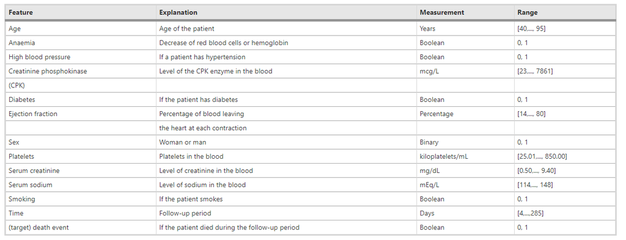

```python
filename="C:\\Users\\gentib\\Documents\\Teaching\\Spring 2021\\CSCI 440 Machine Learning\\Datasets\\Heart Failure\\heart_failure_clinical_records_dataset.csv"
hfd=np.loadtxt(filename, delimiter=",", skiprows=1)

Y_hfd=hfd[:,-1]
X_hfd=hfd[:,:-1]
print("Dimensions of the X data : ", np.shape(X_hfd),"\n")

print("The first 5 data entries : ")
print(X_hfd[:5,:])

print("All labels :")
print(Y_hfd)
```

```
Dimensions of the X data :  (299, 12)

The first 5 data entries :
[[7.5000000e+01 0.0000000e+00 5.8200000e+02 0.0000000e+00 2.0000000e+01
  1.0000000e+00 2.6500000e+05 1.9000000e+00 1.3000000e+02 1.0000000e+00
  0.0000000e+00 4.0000000e+00]
 [5.5000000e+01 0.0000000e+00 7.8610000e+03 0.0000000e+00 3.8000000e+01
  0.0000000e+00 2.6335803e+05 1.1000000e+00 1.3600000e+02 1.0000000e+00
  0.0000000e+00 6.0000000e+00]
 [6.5000000e+01 0.0000000e+00 1.4600000e+02 0.0000000e+00 2.0000000e+01
  0.0000000e+00 1.6200000e+05 1.3000000e+00 1.2900000e+02 1.0000000e+00
  1.0000000e+00 7.0000000e+00]
 [5.0000000e+01 1.0000000e+00 1.1100000e+02 0.0000000e+00 2.0000000e+01
  0.0000000e+00 2.1000000e+05 1.9000000e+00 1.3700000e+02 1.0000000e+00
  0.0000000e+00 7.0000000e+00]
 [6.5000000e+01 1.0000000e+00 1.6000000e+02 1.0000000e+00 2.0000000e+01
  0.0000000e+00 3.2700000e+05 2.7000000e+00 1.1600000e+02 0.0000000e+00
  0.0000000e+00 8.0000000e+00]]
All labels :
[1. 1. 1. 1. 1. 1. 1. 1. 1. 1. 1. 1. 1. 1. 0. 1. 1. 1. 1. 1. 0. 1. 1. 0.
 1. 1. 1. 1. 1. 1. 1. 1. 1. 0. 1. 1. 1. 1. 0. 1. 1. 1. 1. 0. 1. 1. 1. 1.
 1. 1. 1. 1. 1. 1. 1. 1. 0. 0. 1. 1. 1. 1. 0. 1. 0. 1. 1. 1. 1. 1. 0. 0.
 1. 0. 1. 1. 0. 0. 0. 0. 0. 0. 1. 0. 1. 0. 0. 0. 0. 0. 0. 0. 0. 1. 0. 0.
 0. 0. 0. 0. 0. 0. 0. 0. 0. 1. 0. 0. 0. 0. 1. 0. 0. 1. 0. 0. 0. 0. 0. 1.
 0. 0. 0. 0. 1. 0. 1. 0. 0. 0. 0. 0. 0. 0. 0. 0. 0. 0. 0. 0. 1. 0. 0. 0.
 1. 0. 0. 0. 1. 0. 1. 0. 0. 0. 0. 0. 0. 0. 0. 0. 0. 0. 0. 1. 1. 1. 0. 1.
 0. 0. 0. 0. 0. 0. 0. 0. 0. 0. 0. 0. 0. 1. 1. 1. 1. 1. 1. 1. 0. 0. 0. 0.
 0. 0. 1. 1. 0. 0. 0. 0. 0. 0. 0. 0. 0. 0. 0. 0. 0. 0. 0. 0. 0. 1. 0. 0.
 0. 1. 0. 0. 1. 0. 0. 0. 0. 0. 0. 0. 0. 0. 1. 0. 0. 0. 0. 0. 0. 0. 0. 0.
 0. 0. 0. 0. 0. 0. 1. 0. 0. 0. 0. 0. 0. 0. 0. 0. 0. 0. 0. 0. 0. 0. 1. 0.
 0. 0. 1. 0. 0. 0. 0. 0. 0. 0. 0. 0. 0. 0. 0. 0. 0. 0. 0. 0. 0. 0. 0. 0.
 0. 0. 0. 0. 0. 0. 0. 0. 0. 0. 0.]
```

### HCV Dataset

> Modified the HCV data set found at https://archive.ics.uci.edu/ml/datasets/HCV+data

> Removed the record with missing data. Removed the first column (the patient id). Converted categories and sex into numerical values  
> The target attribute for classification is Category (blood donors vs. Hepatitis C (including its progress ('just' Hepatitis C, Fibrosis, Cirrhosis).

> The laboratory data are the attributes 4-13.
> 1. Category (diagnosis) (values: '0=Blood Donor', '0.5=suspect Blood Donor', '1=Hepatitis', '2=Fibrosis', '3=Cirrhosis')
> 2. Age (in years)
> 3. Sex (1=f,0=m)
> 4. ALB
> 5. ALP
> 6. ALT
> 7. AST
> 8. BIL
> 9. CHE
> 10. CHOL
> 11. CREA
> 12. GGT
> 13. PROT

> Relevant Papers:  
> Lichtinghagen R et al. J Hepatol 2013; 59: 236-42 Hoffmann G et al. Using machine learning techniques to generate laboratory diagnostic pathways â€“ a case study. J Lab Precis Med 2018; 3: 58-67

```python
filename="C:\\Users\\gentib\\Documents\\Teaching\\Spring 2021\\CSCI 440 Machine Learning\\Datasets\\HCV data set\\hcvdat0_mod.csv"
hcv=np.loadtxt(filename, delimiter=",", skiprows=1)

Y_hcv=hcv[:,0]
X_hcv=hcv[:,1:]
print("Dimensions of the X data : ", np.shape(X_hcv),"\n")

print("The first 5 data entries : ")
print(X_hcv[:5,:])

print("All labels :")
print(Y_hcv)
```

```
Dimensions of the X data :  (589, 12)

The first 5 data entries :
[[ 32.     0.    38.5   52.5    7.7   22.1    7.5    6.93   3.23 106.
   12.1   69.  ]
 [ 32.     0.    38.5   70.3   18.    24.7    3.9   11.17   4.8   74.
   15.6   76.5 ]
 [ 32.     0.    46.9   74.7   36.2   52.6    6.1    8.84   5.2   86.
   33.2   79.3 ]
 [ 32.     0.    43.2   52.    30.6   22.6   18.9    7.33   4.74  80.
   33.8   75.7 ]
 [ 32.     0.    39.2   74.1   32.6   24.8    9.6    9.15   4.32  76.
   29.9   68.7 ]]
All labels :
[0.  0.  0.  0.  0.  0.  0.  0.  0.  0.  0.  0.  0.  0.  0.  0.  0.  0.
 0.  0.  0.  0.  0.  0.  0.  0.  0.  0.  0.  0.  0.  0.  0.  0.  0.  0.
 0.  0.  0.  0.  0.  0.  0.  0.  0.  0.  0.  0.  0.  0.  0.  0.  0.  0.
 0.  0.  0.  0.  0.  0.  0.  0.  0.  0.  0.  0.  0.  0.  0.  0.  0.  0.
 0.  0.  0.  0.  0.  0.  0.  0.  0.  0.  0.  0.  0.  0.  0.  0.  0.  0.
 0.  0.  0.  0.  0.  0.  0.  0.  0.  0.  0.  0.  0.  0.  0.  0.  0.  0.
 0.  0.  0.  0.  0.  0.  0.  0.  0.  0.  0.  0.  0.  0.  0.  0.  0.  0.
 0.  0.  0.  0.  0.  0.  0.  0.  0.  0.  0.  0.  0.  0.  0.  0.  0.  0.
 0.  0.  0.  0.  0.  0.  0.  0.  0.  0.  0.  0.  0.  0.  0.  0.  0.  0.
 0.  0.  0.  0.  0.  0.  0.  0.  0.  0.  0.  0.  0.  0.  0.  0.  0.  0.
 0.  0.  0.  0.  0.  0.  0.  0.  0.  0.  0.  0.  0.  0.  0.  0.  0.  0.
 0.  0.  0.  0.  0.  0.  0.  0.  0.  0.  0.  0.  0.  0.  0.  0.  0.  0.
 0.  0.  0.  0.  0.  0.  0.  0.  0.  0.  0.  0.  0.  0.  0.  0.  0.  0.
 0.  0.  0.  0.  0.  0.  0.  0.  0.  0.  0.  0.  0.  0.  0.  0.  0.  0.
 0.  0.  0.  0.  0.  0.  0.  0.  0.  0.  0.  0.  0.  0.  0.  0.  0.  0.
 0.  0.  0.  0.  0.  0.  0.  0.  0.  0.  0.  0.  0.  0.  0.  0.  0.  0.
 0.  0.  0.  0.  0.  0.  0.  0.  0.  0.  0.  0.  0.  0.  0.  0.  0.  0.
 0.  0.  0.  0.  0.  0.  0.  0.  0.  0.  0.  0.  0.  0.  0.  0.  0.  0.
 0.  0.  0.  0.  0.  0.  0.  0.  0.  0.  0.  0.  0.  0.  0.  0.  0.  0.
 0.  0.  0.  0.  0.  0.  0.  0.  0.  0.  0.  0.  0.  0.  0.  0.  0.  0.
 0.  0.  0.  0.  0.  0.  0.  0.  0.  0.  0.  0.  0.  0.  0.  0.  0.  0.
 0.  0.  0.  0.  0.  0.  0.  0.  0.  0.  0.  0.  0.  0.  0.  0.  0.  0.
 0.  0.  0.  0.  0.  0.  0.  0.  0.  0.  0.  0.  0.  0.  0.  0.  0.  0.
 0.  0.  0.  0.  0.  0.  0.  0.  0.  0.  0.  0.  0.  0.  0.  0.  0.  0.
 0.  0.  0.  0.  0.  0.  0.  0.  0.  0.  0.  0.  0.  0.  0.  0.  0.  0.
 0.  0.  0.  0.  0.  0.  0.  0.  0.  0.  0.  0.  0.  0.  0.  0.  0.  0.
 0.  0.  0.  0.  0.  0.  0.  0.  0.  0.  0.  0.  0.  0.  0.  0.  0.  0.
 0.  0.  0.  0.  0.  0.  0.  0.  0.  0.  0.  0.  0.  0.  0.  0.  0.  0.
 0.  0.  0.  0.  0.  0.  0.  0.  0.  0.  0.  0.  0.  0.  0.  0.  0.  0.
 0.  0.  0.  0.  0.5 0.5 0.5 0.5 0.5 0.5 0.5 1.  1.  1.  1.  1.  1.  1.
 1.  1.  1.  1.  1.  1.  1.  1.  1.  1.  1.  1.  1.  2.  2.  2.  2.  2.
 2.  2.  2.  2.  2.  2.  2.  3.  3.  3.  3.  3.  3.  3.  3.  3.  3.  3.
 3.  3.  3.  3.  3.  3.  3.  3.  3.  3.  3.  3.  3. ]
```

### Diabetes Dataset (Bangladesh hospital)

> Modified the Diabetes data set found at https://archive.ics.uci.edu/ml/datasets/Early+stage+diabetes+risk+prediction+dataset.

> Data Set Information:  
> This has been collected using direct questionnaires from the patients of Sylhet Diabetes Hospital in Sylhet, Bangladesh and approved by a doctor.

> Attribute Information:
> 1. Age 1.20-65
> 2. Sex 0. Male, 1.Female
> 3. Polyuria 1.Yes, 0.No.
> 4. Polydipsia 1.Yes, 0.No.
> 5. sudden weight loss 1.Yes, 0.No.
> 6. weakness 1.Yes, 0.No.
> 7. Polyphagia 1.Yes, 0.No.
> 8. Genital thrush 1.Yes, 0.No.
> 9. visual blurring 1.Yes, 0.No.
> 10. Itching 1.Yes, 0.No.
> 11. Irritability 1.Yes, 0.No.
> 12. delayed healing 1.Yes, 0.No.
> 13. partial paresis 1.Yes, 0.No.
> 14. muscle stiffness 1.Yes, 0.No.
> 15. Alopecia 1.Yes, 0.No.
> 16. Obesity 1.Yes, 0.No.
> 17. Class 1.Positive, -1.Negative.

```python
filename="C:\\Users\\gentib\\Documents\\Teaching\\Spring 2021\\CSCI 440 Machine Learning\\Datasets\\Diabetes dataset\\diabetes_data_mod.csv"
dia=np.loadtxt(filename, delimiter=",", skiprows=1)

Y_dia=dia[:,-1]
X_dia=dia[:,:-1]
print("Dimensions of the X data : ", np.shape(X_dia),"\n")

print("The first 5 data entries : ")
print(X_dia[:5,:])

print("All labels :")
print(Y_dia)
```

```
Dimensions of the X data :  (520, 16)

The first 5 data entries :
[[40.  0.  0.  1.  0.  1.  0.  0.  0.  1.  0.  1.  0.  1.  1.  1.]
 [58.  0.  0.  0.  0.  1.  0.  0.  1.  0.  0.  0.  1.  0.  1.  0.]
 [41.  0.  1.  0.  0.  1.  1.  0.  0.  1.  0.  1.  0.  1.  1.  0.]
 [45.  0.  0.  0.  1.  1.  1.  1.  0.  1.  0.  1.  0.  0.  0.  0.]
 [60.  0.  1.  1.  1.  1.  1.  0.  1.  1.  1.  1.  1.  1.  1.  1.]]
All labels :
[ 1.  1.  1.  1.  1.  1.  1.  1.  1.  1.  1.  1.  1.  1.  1.  1.  1.  1.
  1.  1.  1.  1.  1.  1.  1.  1.  1.  1.  1.  1.  1.  1.  1.  1.  1.  1.
  1.  1.  1.  1.  1.  1.  1.  1.  1.  1.  1.  1.  1.  1.  1.  1.  1.  1.
  1.  1.  1.  1.  1.  1.  1.  1.  1.  1.  1.  1.  1.  1.  1.  1.  1.  1.
  1.  1.  1.  1.  1.  1.  1.  1.  1.  1.  1.  1.  1.  1.  1.  1.  1.  1.
  1.  1.  1.  1.  1.  1.  1.  1.  1.  1.  1.  1.  1.  1.  1.  1.  1.  1.
  1.  1.  1.  1.  1.  1.  1.  1.  1.  1.  1.  1.  1.  1.  1.  1.  1.  1.
  1.  1.  1.  1.  1.  1.  1.  1.  1.  1.  1.  1.  1.  1.  1.  1.  1.  1.
  1.  1.  1.  1.  1.  1.  1.  1.  1.  1.  1.  1.  1.  1.  1.  1.  1.  1.
  1.  1.  1.  1.  1.  1.  1.  1.  1.  1.  1.  1.  1.  1.  1.  1.  1.  1.
  1.  1.  1.  1.  1.  1.  1.  1.  1.  1.  1.  1.  1.  1.  1.  1.  1.  1.
  1.  1. -1. -1. -1. -1. -1. -1. -1. -1. -1. -1. -1. -1. -1. -1. -1. -1.
 -1. -1. -1. -1. -1. -1. -1. -1. -1. -1. -1. -1. -1. -1. -1. -1. -1. -1.
 -1. -1. -1. -1. -1. -1. -1. -1. -1. -1. -1. -1. -1. -1. -1.  1.  1.  1.
  1.  1.  1.  1.  1.  1.  1.  1.  1.  1.  1.  1.  1.  1.  1.  1.  1.  1.
  1.  1. -1. -1. -1. -1. -1. -1. -1. -1. -1. -1. -1. -1. -1. -1. -1. -1.
 -1. -1. -1. -1. -1. -1. -1.  1.  1.  1.  1.  1.  1.  1.  1.  1.  1. -1.
 -1. -1. -1. -1. -1. -1. -1. -1. -1. -1. -1. -1. -1. -1. -1. -1. -1. -1.
 -1. -1. -1. -1. -1. -1. -1. -1. -1. -1. -1. -1. -1.  1.  1.  1.  1.  1.
  1.  1.  1.  1.  1. -1. -1. -1. -1. -1. -1. -1. -1. -1. -1. -1.  1.  1.
  1.  1.  1.  1.  1.  1.  1.  1.  1. -1. -1. -1. -1. -1. -1. -1. -1. -1.
  1.  1.  1.  1.  1.  1.  1.  1. -1. -1. -1. -1. -1. -1. -1. -1. -1. -1.
 -1. -1. -1. -1. -1. -1. -1. -1. -1. -1. -1. -1. -1. -1. -1. -1. -1. -1.
  1.  1.  1.  1.  1.  1.  1.  1.  1.  1.  1.  1.  1.  1.  1.  1.  1.  1.
  1.  1.  1.  1.  1.  1.  1.  1.  1.  1.  1.  1.  1.  1.  1.  1.  1.  1.
  1.  1.  1.  1.  1.  1.  1.  1.  1.  1. -1. -1. -1. -1. -1. -1. -1. -1.
 -1. -1. -1. -1. -1. -1. -1. -1. -1. -1. -1. -1. -1. -1. -1.  1.  1.  1.
  1.  1. -1. -1. -1. -1. -1. -1. -1. -1. -1. -1.  1. -1.  1. -1. -1. -1.
 -1. -1. -1. -1. -1. -1. -1. -1. -1.  1.  1.  1.  1.  1. -1. -1.]
```

# K-Nearest Neighbors and Naive Bayes Classifiers with SciKit

> We'll run a couple of classification learning models on a few of the datasets.  
> We are going to use Naive Bayes classifier and Nearest Neighbors classifier.

> We will first split the dataset into two sets:
> 1. A training set used to train the model on
> 2. A test set to check how well we learning

> After we load the data, for each model we are going to perform the following steps:
> 1. Build the model (i.e., set up the model type and structure)
> 2. Train the model using the training data (i.e., adjust the parameters)
> 3. Make predictions using the testing data
> 4. Evaluate the performace of the model

```python
import numpy as np
import matplotlib.pyplot as plt
from sklearn import (datasets, naive_bayes, neighbors, model_selection)
```

## Iris Dataset

### Load the dataset and split into training and testing sets

```python
iris=datasets.load_iris()
(Xtrain_iris, Xtest_iris, Ytrain_iris, Ytest_iris)=model_selection.train_test_split(iris.data, iris.target, test_size=.3)

print("Dimensions of the training set X data : ", Xtrain_iris.shape,"\n")
print("Dimensions of the testing set X data : ", Xtest_iris.shape,"\n")

print("Feature Names :", iris.feature_names)
print("Categories : ", iris.target_names)
```

```
Dimensions of the training set X data :  (105, 4)

Dimensions of the testing set X data :  (45, 4)

Feature Names : ['sepal length (cm)', 'sepal width (cm)', 'petal length (cm)', 'petal width (cm)']
Categories :  ['setosa' 'versicolor' 'virginica']
```

### K-Nearest Neighbors Classifier

> https://scikit-learn.org/stable/modules/neighbors.html#neighbors

> We are going to perform the following steps
> 1. Build a 3-NN (three nearest neighbors) model
> 2. Train the model using the training data (i.e., adjust the parameters)
> 3. Make predictions using the testing data
> 4. Evaluate the performace of the model

```python
knn=neighbors.KNeighborsClassifier(n_neighbors=3)  #step 1
knn_fit=knn.fit(Xtrain_iris, Ytrain_iris)          #step 2
```

```python
Ypred_iris_knn=knn_fit.predict(Xtest_iris)         #step 3 - get the predicted labels given the feature inputs for the test set
# step 4
print ("Actual Labels   :", Ytest_iris)
print ("Predicted Labels:", Ypred_iris_knn)
test_size=len(Ytest_iris)
knn_accuracy=100*np.sum(Ytest_iris==Ypred_iris_knn)/test_size
print("Accuracy         :", knn_accuracy, "%.")
print("Error            :", 100-knn_accuracy, "%.\n")
```

```
Actual Labels   : [0 1 0 2 2 2 2 1 1 2 2 2 2 1 2 2 1 2 0 0 2 1 2 0 1 0 2 2 1 2 2 0 0 1 0 0 2
 1 2 1 1 0 0 1 0]
Predicted Labels: [0 1 0 2 2 2 2 1 1 2 1 2 2 1 2 2 1 1 0 0 2 1 2 0 1 0 2 2 1 2 2 0 0 1 0 0 2
 1 2 1 1 0 0 1 0]
Accuracy         : 95.55555555555556 %.
Error            : 4.444444444444443 %.
```

### Naive Bayes Classifier

> https://scikit-learn.org/stable/modules/naive_bayes.html#naive-bayes

> We are going to perform the following steps
> 1. Build a naive bayes (gaussian) model
> 2. Train the model using the training data (i.e., adjust the parameters)
> 3. Make predictions using the testing data
> 4. Evaluate the performace of the model

```python
nb=naive_bayes.GaussianNB()                      #step 1
nb_fit=nb.fit(Xtrain_iris, Ytrain_iris)          #step 2
```

```python
Ypred_iris_nb=nb_fit.predict(Xtest_iris)         #step 3 - get the predicted labels given the feature inputs for the test set

# step 4
print ("Actual Labels   :", Ytest_iris)
print ("Predicted Labels:", Ypred_iris_nb)
test_size=len(Ytest_iris)
nb_accuracy=100*np.sum(Ytest_iris==Ypred_iris_nb)/test_size
print("Accuracy         :", nb_accuracy, "%.")
print("Error            :", 100-nb_accuracy, "%.\n")
```

```
Actual Labels   : [0 1 0 2 2 2 2 1 1 2 2 2 2 1 2 2 1 2 0 0 2 1 2 0 1 0 2 2 1 2 2 0 0 1 0 0 2
 1 2 1 1 0 0 1 0]
Predicted Labels: [0 1 0 2 2 2 2 1 1 2 1 2 2 1 2 2 1 2 0 0 2 1 2 0 1 0 2 2 1 2 2 0 0 1 0 0 2
 1 2 1 2 0 0 1 0]
Accuracy         : 95.55555555555556 %.
Error            : 4.444444444444443 %.
```

## Handwritten Digits

> The dataset used in the video lectures.  
> Normalized handwritten digits, automatically scanned from envelopes by the U.S. Postal Service. The original scanned digits are binary and of different sizes and orientations; the images here have been deslanted and size normalized, resulting in 16 x 16 grayscale images (Le Cun et al., 1990).

### Load the dataset and split into training and testing sets

```python
tfilename="C:\\Users\\gentib\\Documents\\Teaching\\Spring 2021\\CSCI 440 Machine Learning\\Datasets\\Handwritten Digits\\zip.train"
digit_data=np.loadtxt(tfilename)
Y_dig=digit_data[:,0]
X_dig=digit_data[:,1:]
print("Dimensions of the X data : ", X_dig.shape,"\n")

(Xtrain_dig, Xtest_dig, Ytrain_dig, Ytest_dig)=model_selection.train_test_split(X_dig, Y_dig, test_size=.3)

print("Dimensions of the training set X data : ", Xtrain_dig.shape,"\n")
print("Dimensions of the testing set X data  : ", Xtest_dig.shape,"\n")
```

```
Dimensions of the X data :  (7291, 256)

Dimensions of the training set X data :  (5103, 256)

Dimensions of the testing set X data  :  (2188, 256)
```

### K-Nearest Neighbors Classifier

> We are going to perform the following steps
> 1. Build a 3-NN (three nearest neighbors) model
> 2. Train the model using the training data (i.e., adjust the parameters)
> 3. Make predictions using the testing data
> 4. Evaluate the performace of the model

```python
dknn=neighbors.KNeighborsClassifier(n_neighbors=3)  #step 1
dknn_fit=dknn.fit(Xtrain_dig, Ytrain_dig)          #step 2
```

```python
Ypred_dig_knn=dknn_fit.predict(Xtest_dig)         #step 3 - get the predicted labels given the feature inputs for the test set

# step 4
dtest_size=len(Ytest_dig)
dknn_accuracy=100*np.sum(Ytest_dig==Ypred_dig_knn)/dtest_size
print("Accuracy         :", dknn_accuracy, "%.")
print("Error            :", 100-dknn_accuracy, "%.\n")
```

```
Accuracy         : 96.52650822669104 %.
Error            : 3.4734917733089645 %.
```

### Naive Bayes Classifier

We are going to perform the following steps

1. Build a naive bayes (gaussian) model
2. Train the model using the training data (i.e., adjust the parameters)
3. Make predictions using the testing data
4. Evaluate the performace of the model

```python
dnb=naive_bayes.GaussianNB()                      #step 1
dnb_fit=dnb.fit(Xtrain_dig, Ytrain_dig)          #step 2
```

```python
Ypred_dig_nb=dnb_fit.predict(Xtest_dig)         #step 3 - get the predicted labels given the feature inputs for the test set
# step 4
dnb_accuracy=100*np.sum(Ytest_dig==Ypred_dig_nb)/dtest_size
print("Accuracy         :", dnb_accuracy, "%.")
print("Error            :", 100-dnb_accuracy, "%.\n")
```

```
Accuracy         : 75.54844606946983 %.
Error            : 24.451553930530167 %.
```

```python
#visualizing the first 30 images of the test set 3-NN
fig, axes = plt.subplots(2,15, figsize=(20,3))
for i in range(15):
    ax=axes[0,i]
    im=Xtest_dig[i,:].reshape(16,16)
    ax.matshow(im, cmap='gray')
    ax.axis("off")
    ax.set_title(int(Ypred_dig_knn[i]))
    ax=axes[1,i]
    im=Xtest_dig[i+15,:].reshape(16,16)
    ax.matshow(im, cmap='gray')
    ax.axis("off")
    ax.set_title(int(Ypred_dig_knn[i+15]))
```

[figure not shown]

```python
#visualizing the first 30 images of the test set NB
fig, axes = plt.subplots(2,15, figsize=(20,3))
for i in range(15):
    ax=axes[0,i]
    im=Xtest_dig[i,:].reshape(16,16)
    ax.matshow(im, cmap='gray')
    ax.axis("off")
    ax.set_title(int(Ypred_dig_nb[i]))
    ax=axes[1,i]
    im=Xtest_dig[i+15,:].reshape(16,16)
    ax.matshow(im, cmap='gray')
    ax.axis("off")
    ax.set_title(int(Ypred_dig_nb[i+15]))
```

[figure not shown]

## Breast cancer wisconsin (diagnostic) dataset

### Load the dataset and split into training and testing sets

```python
bcw=datasets.load_breast_cancer()

(Xtrain_bcw, Xtest_bcw, Ytrain_bcw, Ytest_bcw)=model_selection.train_test_split(bcw.data, bcw.target, test_size=.3)

print("Dimensions of the training set X data : ", Xtrain_bcw.shape,"\n")
print("Dimensions of the testing set X data : ", Xtest_bcw.shape,"\n")

print("Feature Names :", bcw.feature_names)
print("Categories : ", bcw.target_names)
```

```
Dimensions of the training set X data :  (398, 30)

Dimensions of the testing set X data :  (171, 30)

Feature Names : ['mean radius' 'mean texture' 'mean perimeter' 'mean area'
 'mean smoothness' 'mean compactness' 'mean concavity'
 'mean concave points' 'mean symmetry' 'mean fractal dimension'
 'radius error' 'texture error' 'perimeter error' 'area error'
 'smoothness error' 'compactness error' 'concavity error'
 'concave points error' 'symmetry error' 'fractal dimension error'
 'worst radius' 'worst texture' 'worst perimeter' 'worst area'
 'worst smoothness' 'worst compactness' 'worst concavity'
 'worst concave points' 'worst symmetry' 'worst fractal dimension']
Categories :  ['malignant' 'benign']
```

### K-Nearest Neighbors Classifier

> We are going to perform the following steps
> 1. Build a 3-NN (three nearest neighbors) model
> 2. Train the model using the training data (i.e., adjust the parameters)
> 3. Make predictions using the testing data
> 4. Evaluate the performace of the model

```python
bknn=neighbors.KNeighborsClassifier(n_neighbors=3)  #step 1
bknn_fit=dknn.fit(Xtrain_bcw, Ytrain_bcw)          #step 2
```

```python
Ypred_bcw_knn=bknn_fit.predict(Xtest_bcw)         #step 3 - get the predicted labels given the feature inputs for the test set

# step 4
btest_size=len(Ytest_bcw)
bknn_accuracy=100*np.sum(Ytest_bcw==Ypred_bcw_knn)/btest_size
print("Accuracy         :", bknn_accuracy, "%.")
print("Error            :", 100-bknn_accuracy, "%.\n")
```

```
Accuracy         : 92.39766081871345 %.
Error            : 7.602339181286553 %.
```

### Naive Bayes Classifier

> We are going to perform the following steps
> 1. Build a naive bayes (gaussian) model
> 2. Train the model using the training data (i.e., adjust the parameters)
> 3. Make predictions using the testing data
> 4. Evaluate the performace of the model

```python
bnb=naive_bayes.GaussianNB()                      #step 1
bnb_fit=bnb.fit(Xtrain_bcw, Ytrain_bcw)          #step 2
```

```python
Ypred_bcw_nb=bnb_fit.predict(Xtest_bcw)         #step 3 - get the predicted labels given the feature inputs for the test set
# step 4
bnb_accuracy=100*np.sum(Ytest_bcw==Ypred_bcw_nb)/btest_size
print("Accuracy         :", bnb_accuracy, "%.")
print("Error            :", 100-bnb_accuracy, "%.\n")
```

```
Accuracy         : 96.49122807017544 %.
Error            : 3.5087719298245617 %.
```

# Simple but Complete Learning Process

Diabetes Dataset

```python
import numpy as np
import matplotlib.pyplot as plt
from sklearn import (datasets, model_selection)
```

## Getting the Data

Diabetes Dataset

> Regression dataset  
> target : a quantitative measure of disease progression one year after baseline

```python
diabetesData=datasets.load_diabetes()
(Input, Xtest, Output, Ytest)=model_selection.train_test_split(diabetesData.data, diabetesData.target, test_size=.25)

[N,d]=np.shape(Input);
print("Dimensions of the X data : ",N, "by", d, "\n")

print("Feature Names :", diabetesData.feature_names)
print("The first 5 data entries : ")
print(Input[:5,:])

#print("Categories : ", diabetes.target_names)
print("First 5 target values:")
print(Output[:5])
```

```
Dimensions of the X data :  331 by 10

Feature Names : ['age', 'sex', 'bmi', 'bp', 's1', 's2', 's3', 's4', 's5', 's6']
The first 5 data entries :
[[-0.07816532 -0.04464164 -0.0730303  -0.05731367 -0.08412613 -0.07427747
  -0.02499266 -0.03949338 -0.01811827 -0.08391984]
 [-0.10722563 -0.04464164 -0.01159501 -0.04009932  0.0493413   0.0644473
  -0.01394774  0.03430886  0.00702686 -0.03007245]
 [ 0.03444337  0.05068012  0.02828403 -0.03321358 -0.04559945 -0.00976889
  -0.05076412 -0.00259226 -0.0594727  -0.02178823]
 [ 0.04534098  0.05068012 -0.03530688  0.0631868  -0.00432087 -0.00162703
  -0.01026611 -0.00259226  0.01556684  0.0569118 ]
 [-0.02730979 -0.04464164  0.08001901  0.09876313 -0.00294491  0.01810133
  -0.01762938  0.00331192 -0.02952762  0.03620126]]
First 5 target values:
[142. 200. 145. 185. 257.]
```

## Error Measure

- It is a regression problem (not classification)
- No error measure is give to us, other than the vague description to predict the target
- It seems reasonable (and mathematically convenient) to use the square error measure. I.e. for a given hypothesis $h$ and any input $\mathbf{x}$ penalize by the square of how much it missed the target y \begin{equation*} e\left(h(\mathbf{x}),y\right)=\left(h(\mathbf{x})-y\right)^2 \end{equation*}
- The in-sample error of a given hypothesis is the average of errors for all the points in the training set \begin{equation*} E_{in}(h)=\frac{1}{N}\sum_{k=1}^{N}\left(h(\mathbf{x}_k)-y_k\right)^2 \end{equation*} where $N$ is the size of the training set and $(x_k, y_k)$ are the points in the training set.
- We are going to extimate the out of sample error for a given hypothesis $h$ by averaging the error over a set of new points drawn from the same distribution as the training set. We will call this set the *test* set. \begin{equation*} E_{out}(h)\approx\frac{1}{M}\sum_{k=1}^{M}\left(h(\mathbf{x}_k)-y_k\right)^2 \end{equation*} where $M$ is the size of the test set and $(\mathbf{x}_k, y_k)$ are the points in the test set (different points than the ones in the training set).

## Picking the Hypothesis Set and the Algorithm

- This requires quite a bit of thought and investigation, but for now let's pick a linear model as the hypothesis set. i.e. for any input $\mathbf{x}=\left(x_1, x_2, \ldots, x_{10}\right)$, \begin{equation*} h(\mathbf{x})=w_0+w_1x_1+\cdots+w_{10}x_{10} \end{equation*} To remove any ambiguition, we will denote $h$ by $h_\mathbf{w}$ so that it is clear that each $\mathbf{w}$ produces a hypothesis.
- The algorithm pick is automatic in this case once we picked the hypothesis set and the error measure : **linear regression** is the best (optimal) tool for the job.

### Picking the best linear model using linear regression

- Construct $\mathbf{X}$, and $\mathbf{y}$

```python
X=np.ones((N, d+1))
X[:,1:]=Input
y=Output
```

- Solve $\mathbf{X}\mathbf{w}=\mathbf{y}$ to get the wegiths $\mathbf{w}$ for the best hypothesis

```python
sol=np.linalg.lstsq(X,y,rcond=None)
w=sol[0]
print("w : ", w)
```

```
w :  [ 151.44882069    5.71876565 -242.734522    489.04655164  348.74117513
 -877.59677683  550.08605133  150.86832586  251.69454041  717.59450286
   33.33083865]
```

## Get the In-Sample Error

- Using $\mathbf{w}$ from above, get the prediction for each point $\mathbf{x}$ \begin{equation*} g(\mathbf{x})=w_0+w_1x_1+\cdots+w_{10}x_{10} \end{equation*}
- Using matrix notation this can be done using \begin{equation*} \mathbf{g}=\mathbf{X}\mathbf{w} \end{equation*} where $ \mathbf{g}$ is the vector of all predictions
- The error of $ \mathbf{g}$ is $\text{np.mean}(\left(\mathbf{g}-\mathbf{y}\right)^2)$

```python
g = X @ w
Ein=np.mean((g-y)**2)
print(np.sqrt(Ein))
```

```
54.129740814401714
```

## Get the Out-of-Sample Error Estimate

- Using $\mathbf{w}$ from above, get the prediction for each point $\mathbf{x}$ in the test set. Let denote by $\mathbf{x_t}$ and $y_t$ the input and output of the points in the test set.
- Using matrix notation this can be done using \begin{equation*} \mathbf{g_t}=\mathbf{X_t}\mathbf{w} \end{equation*} where $ \mathbf{g_t}$ is the vector of all predictions for the test set
- The error of $ \mathbf{g_t}$ is $\text{np.mean}(\left(\mathbf{g_t}-\mathbf{y_t}\right)^2)$

```python
[M, d]=np.shape(Xtest)
Xt=np.ones((M, d+1))
Xt[:,1:]=Xtest
yt=Ytest

gt=Xt @ w
Eout=np.mean((gt-yt)**2)
print(np.sqrt(Eout))
```

```
51.97039279773035
```

# More On Nonlinear Transforms

```python
import numpy as np
import matplotlib.pyplot as plt
from mpl_toolkits import mplot3d
```

## A simple transform $\mathbb{R}^2$ to $\mathbb{R}^2$

Let's consider the simple transformation below and visualize how different points transform from $\mathbf{X}$-space to $\mathbf{Z}$-space

```python
def transforma(x1, x2):
    z1=x1**2+x2**2
    z2=x2
    return [z1,z2]
```

```python
xp1, xp2=np.mgrid[-5: 5: .5, -5: 5: .5]
xn1, xn2=np.mgrid[-4.75: 5.25: .5, -5: 5: .5]

zp1,zp2=transforma(xp1,xp2)
zn1, zn2=transforma(xn1,xn2)
```

```python
fig, ax=plt.subplots(1,2, figsize=(10,3))
ax[0].plot(xp1, xp2, 'ro')
ax[0].plot(xn1, xn2, 'bo')
ax[0].set_xlabel('$x_1$')
ax[0].set_ylabel('$x_2$')
ax[0].set_title('$\mathbf{X}$-space')

ax[1].plot(zp1, zp2, 'ro')
ax[1].plot(zn1, zn2, 'bo')
ax[1].set_xlabel('$z_1$')
ax[1].set_ylabel('$z_2$')
ax[1].set_title('$\mathbf{Z}$-space')
```

[figure not shown]

## A simple transform $\mathbb{R}^2$ to $\mathbb{R}^3$

Let's consider the simple transformation below and visualize how different points transform from $\mathbf{X}$-space to $\mathbf{Z}$-space

```python
def transformb(x1, x2):
    z1=x1**2 + x2**2
    z2=x2
    z3=x1
    return [z1,z2, z3]
```

```python
xp1, xp2=np.mgrid[-5: 5: .5, -5: 5: .5]
xn1, xn2=np.mgrid[-4.75: 5.25: .5, -5: 5: .5]

zp1,zp2, zp3=transformb(xp1,xp2)
zn1, zn2, zn3=transformb(xn1,xn2)
```

```python
fig, ax=plt.subplots(1,2, figsize=(10,3))
ax[0].plot(xp1, xp2, 'ro')
ax[0].plot(xn1, xn2, 'bo')
ax[0].set_xlabel('$x_1$')
ax[0].set_ylabel('$x_2$')
ax[0].set_title('$\mathbf{X}$-space')


ax[1].remove()
ax[1]=fig.add_subplot(1,2,2,projection='3d')

ax[1].scatter(zp1, zp2, zp3, 'ro')
ax[1].scatter(zn1, zn2, zn3, 'bo')
ax[1].set_xlabel('$z_1$')
ax[1].set_ylabel('$z_2$')
ax[1].set_zlabel('$z_3$')
ax[1].set_title('$\mathbf{Z}$-space')
```

[figure not shown]

## Some classification examples in $\mathbb{R}$

### Example 1

```python
N=30
xa=np.random.rand(N,1)*10-5
ya=2*((xa<3)*(xa>-1))-1
fig, ax=plt.subplots()
ax.plot(  xa[ya>0], xa[ya>0]*0,'r+')
ax.plot( xa[ya<0], xa[ya<0]*0, 'bo')
ax.set_xlabel('$x$')
ax.set_title('$\mathbf{X}$-space')
```

[figure not shown]

It is clear that the data above is not linearly separable. Let's transform the data using the following transformation $T_2$ \begin{equation*} T_2:\mathbb{R}\rightarrow\mathbb{R}^2 \end{equation*} defined by \begin{equation*} z=T_2\left(x\right)=\left(x,x^2\right) \end{equation*}

```python
def transform2(x):
    z1=x
    z2=x**2
    return [z1,z2]
```

```python
z1, z2=transform2(xa)

fig, ax=plt.subplots(1,2, figsize=(10,3))
ax[0].plot(  xa[ya>0], xa[ya>0]*0,'r+')
ax[0].plot( xa[ya<0], xa[ya<0]*0, 'bo')
ax[0].set_xlabel('$x$')
ax[0].set_title('$\mathbf{X}$-space')

ax[1].plot(z1[ya>0], z2[ya>0], 'r+')
ax[1].plot(z1[ya<0], z2[ya<0], 'bo')
ax[1].set_xlabel('$z_1$')
ax[1].set_xlabel('$z_2$')
ax[1].set_title('$\mathbf{Z}$-space')
```

[figure not shown]

In the $\mathbf{Z}$-space the data is linearly separable.

### Example 2

```python
N=30
xa=np.random.rand(N,1)*10-5
ya1=(xa<-3)
ya2=(xa<3)*(xa>-1)
ya=2*(ya1+ya2)-1;

fig, ax=plt.subplots()
ax.plot(  xa[ya>0], xa[ya>0]*0,'r+')
ax.plot( xa[ya<0], xa[ya<0]*0, 'bo')
ax.set_xlabel('$x$')
ax.set_title('$\mathbf{X}$-space')
```

[figure not shown]

The data above is not linearly separable. Let's transform the data using the following transformation $T_2$

```python
fig, ax=plt.subplots(1,2, figsize=(10,3))
ax[0].plot(  xa[ya>0], xa[ya>0]*0,'r+')
ax[0].plot( xa[ya<0], xa[ya<0]*0, 'bo')
ax[0].set_xlabel('$x$')
ax[0].set_title('$\mathbf{X}$-space')

z1, z2 = transform2(xa);
ax[1].plot(z1[ya>0], z2[ya>0], 'r+')
ax[1].plot(z1[ya<0], z2[ya<0], 'bo')
ax[1].set_xlabel('$z_1$')
ax[1].set_xlabel('$z_2$')
ax[1].set_title('$\mathbf{Z}$-space')
```

[figure not shown]

Even after using $T_2$ the data is still not linearly separable. Let's transform the data using a different transformation $T_3$ defined as \begin{equation*} T_3:\mathbb{R}\rightarrow\mathbb{R}^3 \end{equation*} defined by \begin{equation*} z=T_3\left(x\right)=\left(x,x^2,x^3\right) \end{equation*}

```python
def transform3(x):
    z1=x
    z2=x**2
    z3=x**3
    return [z1,z2,z3]
```

```python
z1,z2,z3=transform3(xa)
```

```python
fig, ax=plt.subplots(1,2, figsize=(10,3))
ax[0].plot(  xa[ya>0], xa[ya>0]*0,'r+')
ax[0].plot( xa[ya<0], xa[ya<0]*0, 'bo')
ax[0].set_xlabel('$x$')
ax[0].set_title('$\mathbf{X}$-space')

ax[1].remove()
ax[1]=fig.add_subplot(1,2,2, projection='3d')

ax[1].scatter(z1[ya>0], z2[ya>0], z3[ya>0], 'r')
ax[1].scatter(z1[ya<0], z2[ya<0], z3[ya<0], 'b')
ax[1].set_xlabel('$z_1$')
ax[1].set_ylabel('$z_2$')
ax[1].set_zlabel('$z_3$')
ax[1].set_title('$\mathbf{Z}$-space')
```

[figure not shown]

In this $\mathbf{Z}$-space the data is linearly separable. To get a better view of it, let's rotate te plot.

```python
angle=80
ax[1].view_init(0, angle)
ax[1].get_figure()
```

[figure not shown]

#### Note

You do not need to go to $\mathbb{R}^3$ to get the data to be linearly separable. Indeed we can use the following transformation \begin{equation*} \tilde{T}:\mathbb{R}\rightarrow\mathbb{R} \end{equation*} defined by \begin{equation*} z=\tilde{T}\left(x\right)=\left(x+1\right)\left(x^2-9\right) \end{equation*}

```python
fig, ax=plt.subplots(1,2, figsize=(10,3))
ax[0].plot(  xa[ya>0], xa[ya>0]*0,'r+')
ax[0].plot( xa[ya<0], xa[ya<0]*0, 'bo')
ax[0].set_xlabel('$x$')
ax[0].set_title('$\mathbf{X}$-space')

z = (xa+1)*(xa**2-9);
ax[1].plot(z[ya>0], z[ya>0]*0, 'r+')
ax[1].plot(z[ya<0], z[ya<0]*0, 'bo')
ax[1].set_xlabel('$z_1$')
ax[1].set_xlabel('$z_2$')
ax[1].set_title('$\mathbf{Z}$-space')
```

[figure not shown]

Notice that in this $\mathbf{Z}$-space the data is linearly separable. However we *cheated* because we guessed the right transformation by looking at the data. We will learn later in the class why this is a **bad** idea.

# Theory of Generalization; Training and Testing using Heart Failure Dataset

```python
import numpy as np
import matplotlib.pyplot as plt
from sklearn import (datasets, naive_bayes, model_selection)
```

**Heart Failure Dataset**

> https://archive.ics.uci.edu/ml/datasets/Heart+failure+clinical+records

> Thirteen (13) clinical features:
> - age: age of the patient (years)
> - anaemia: decrease of red blood cells or hemoglobin (boolean)
> - high blood pressure: if the patient has hypertension (boolean)
> - creatinine phosphokinase (CPK): level of the CPK enzyme in the blood (mcg/L)
> - diabetes: if the patient has diabetes (boolean)
> - ejection fraction: percentage of blood leaving the heart at each contraction (percentage)
> - platelets: platelets in the blood (kiloplatelets/mL)
> - sex: woman or man (binary)
> - serum creatinine: level of serum creatinine in the blood (mg/dL)
> - serum sodium: level of serum sodium in the blood (mEq/L)
> - smoking: if the patient smokes or not (boolean)
> - time: follow-up period (days)
> - [target] death event: if the patient deceased during the follow-up period (boolean)

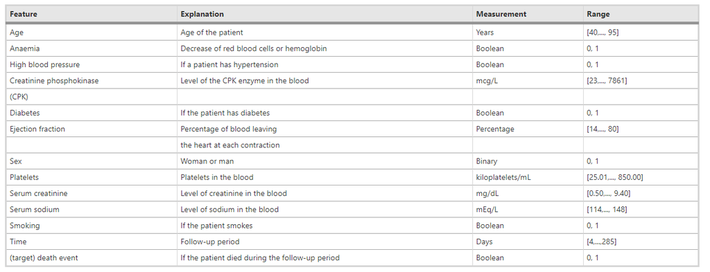

```python
filename="C:\\Users\\gentib\\Documents\\Teaching\\Spring 2021\\CSCI 440 Machine Learning\\Datasets\\Heart Failure\\heart_failure_clinical_records_dataset.csv"
hfd=np.loadtxt(filename, delimiter=",", skiprows=1)

Y_hfd=hfd[:,-1]
X_hfd=hfd[:,:-1]
print("Dimensions of the X data : ", np.shape(X_hfd),"\n")

print("The first 2 ata entries : ")
print(X_hfd[:2:])

print("All labels :")
print(Y_hfd)
```

```
Dimensions of the X data :  (299, 12)

The first 2 ata entries :
[[7.5000000e+01 0.0000000e+00 5.8200000e+02 0.0000000e+00 2.0000000e+01
  1.0000000e+00 2.6500000e+05 1.9000000e+00 1.3000000e+02 1.0000000e+00
  0.0000000e+00 4.0000000e+00]
 [5.5000000e+01 0.0000000e+00 7.8610000e+03 0.0000000e+00 3.8000000e+01
  0.0000000e+00 2.6335803e+05 1.1000000e+00 1.3600000e+02 1.0000000e+00
  0.0000000e+00 6.0000000e+00]]
All labels :
[1. 1. 1. 1. 1. 1. 1. 1. 1. 1. 1. 1. 1. 1. 0. 1. 1. 1. 1. 1. 0. 1. 1. 0.
 1. 1. 1. 1. 1. 1. 1. 1. 1. 0. 1. 1. 1. 1. 0. 1. 1. 1. 1. 0. 1. 1. 1. 1.
 1. 1. 1. 1. 1. 1. 1. 1. 0. 0. 1. 1. 1. 1. 0. 1. 0. 1. 1. 1. 1. 1. 0. 0.
 1. 0. 1. 1. 0. 0. 0. 0. 0. 0. 1. 0. 1. 0. 0. 0. 0. 0. 0. 0. 0. 1. 0. 0.
 0. 0. 0. 0. 0. 0. 0. 0. 0. 1. 0. 0. 0. 0. 1. 0. 0. 1. 0. 0. 0. 0. 0. 1.
 0. 0. 0. 0. 1. 0. 1. 0. 0. 0. 0. 0. 0. 0. 0. 0. 0. 0. 0. 0. 1. 0. 0. 0.
 1. 0. 0. 0. 1. 0. 1. 0. 0. 0. 0. 0. 0. 0. 0. 0. 0. 0. 0. 1. 1. 1. 0. 1.
 0. 0. 0. 0. 0. 0. 0. 0. 0. 0. 0. 0. 0. 1. 1. 1. 1. 1. 1. 1. 0. 0. 0. 0.
 0. 0. 1. 1. 0. 0. 0. 0. 0. 0. 0. 0. 0. 0. 0. 0. 0. 0. 0. 0. 0. 1. 0. 0.
 0. 1. 0. 0. 1. 0. 0. 0. 0. 0. 0. 0. 0. 0. 1. 0. 0. 0. 0. 0. 0. 0. 0. 0.
 0. 0. 0. 0. 0. 0. 1. 0. 0. 0. 0. 0. 0. 0. 0. 0. 0. 0. 0. 0. 0. 0. 1. 0.
 0. 0. 1. 0. 0. 0. 0. 0. 0. 0. 0. 0. 0. 0. 0. 0. 0. 0. 0. 0. 0. 0. 0. 0.
 0. 0. 0. 0. 0. 0. 0. 0. 0. 0. 0.]
```

## Training, Testing and Generalization Bounds

> Using Naive Bayes
> 1. Split the data 50/50 between training and testing
> 2. Estimate $E_{out}-E_{in}$
> 3. Repeat T times 1. and 2. to get a distribution of $E_{out}-E_{in}$

```python
T=10000
alpha=0.5
e_in=[]
e_out=[]
for i in range(T):
    (Xtrain, Xtest, Ytrain, Ytest)=model_selection.train_test_split(X_hfd, 2*Y_hfd-1, test_size=alpha)
    nb=naive_bayes.GaussianNB()
    nb_fit=nb.fit(Xtrain, Ytrain)
    gtrain=nb_fit.predict(Xtrain)
    gtest=nb_fit.predict(Xtest)

    e_in.append(np.mean(gtrain!=Ytrain))
    e_out.append(np.mean(gtest!=Ytest))

e_in=np.array(e_in)
e_out=np.array(e_out)
```

```python
fig2, ax2=plt.subplots()
ax2.plot(e_in, e_out,'k.')
ax2.set_xlabel('$e_{in}$')
ax2.set_ylabel('$e_{out}$')
ax2.set_title('$E_{in}$ vs $E_{out}$ for Different 50/50 Splits')
ax2.grid()
```

[figure not shown]

```python
delta_e=e_out-e_in

f3, ax3 = plt.subplots()

ax3.hist(delta_e, 100);
ax3.set_title("Distribution of $E_{out}-E_{in}$ for Different 50/50 Splits")
ax3.set_ylabel("Count")
ax3.set_xlabel("$E_{out}-E_{in}$")
```

[figure not shown]

```python
eps=np.sort(e_out-e_in)
n=len(eps)
prob=np.array(range(n))/n
fig4, ax4=plt.subplots()
ax4.plot(prob, eps, 'k.')
ax4.set_ylabel('$e_{out}-e_{in}$')
ax4.set_xlabel('Probability')
ax4.set_title('$E_{out}-E_{in}$ for Different 50/50 Splits')
ax4.set_xticks(np.mgrid[0:1.1:.1], minor=False)
ax4.set_xticks(np.mgrid[0.05:1.1:.1], minor=True)

ax4.grid(True, which='both')
```

[figure not shown]

## Effect of Training Data Size on $E_{in}$ and $E_{out}$

```python
aa=np.mgrid[0.9:0:-0.1]
T=10000 #number of tries for each alpha

Ein=[]
Eout=[]

sEin=[]
sEout=[]

for alpha in aa:

    e_in=[]
    e_out=[]
    for i in range(T):
        (Xtrain, Xtest, Ytrain, Ytest)=model_selection.train_test_split(X_hfd, 2*Y_hfd-1, test_size=alpha)
        nb=naive_bayes.GaussianNB()
        nb_fit=nb.fit(Xtrain, Ytrain)
        gtrain=nb_fit.predict(Xtrain)
        gtest=nb_fit.predict(Xtest)

        e_in.append(np.mean(gtrain!=Ytrain))
        e_out.append(np.mean(gtest!=Ytest))
    Ein.append(np.mean(e_in))
    Eout.append(np.mean(e_out))
    sEin.append(np.std(e_in))
    sEout.append(np.std(e_out))
```

```python
vv=(1-aa)*299
fig, ax=plt.subplots()
ax.plot(vv, Ein,'-b*')
ax.plot(vv, Eout,'-r*')
ax.set_xlabel('Training Set Size')
ax.set_ylabel('Error Rate')
ax.legend(('Ein', 'Eout'))
ax.grid()
```

[figure not shown]

# VC Dimension

The VC inequality \begin{equation*} \mathbb{P}\left[ \left|E_{in}\left(g\right)-E_{out}\left(g\right)\right|>\epsilon\right]\leq 4 m_{\mathcal{H}}\left(2N\right)e^{-\frac{1}{8}\epsilon^2N} \end{equation*}

Let's define

\begin{equation*} \begin{matrix} \delta= 4 m_{\mathcal{H}}\left(2N\right)e^{-\frac{1}{8}\epsilon^2N} & \implies & \epsilon=\sqrt{\frac{8}{N}\text{ln}\frac{4 m_{\mathcal{H}}\left(2N\right)}{\delta}} \\ \end{matrix} \end{equation*}

and

\begin{equation*} \Omega\left(N,\mathcal{H},\delta\right)=\sqrt{\frac{8}{N}\text{ln}\frac{4 m_{\mathcal{H}}\left(2N\right)}{\delta}} \end{equation*}

Then the VC inequality transforms to:

> with probability $\geq 1-\delta$, \begin{equation*} \left|E_{in}\left(g\right)-E_{out}\left(g\right)\right| \leq \Omega\left(N,\mathcal{H},\delta\right) \end{equation*}

i.e., with probability $\geq1-\delta$, \begin{equation*} E_{out} \leq E_{in} + \Omega \end{equation*}

Generalization bound $\Omega$

1. Gets smaller for larger training set size $N$
2. Gets larger for larger VC dimension (more complex $\mathcal{H}$)

*Next we illustrate the effect of $N$ and $d_{VC}$ on the generalization bound $\Omega$ using the handwritten digits dataset.*

```python
import numpy as np
import matplotlib.pyplot as plt
from sklearn import (datasets, linear_model, model_selection)
```

## Handwritten Digits

> The dataset used in the video lectures.  
> Normalized handwritten digits, automatically scanned from envelopes by the U.S. Postal Service. The original scanned digits are binary and of different sizes and orientations; the images here have been deslanted and size normalized, resulting in 16 x 16 grayscale images (Le Cun et al., 1990).

**Load the dataset**

> We are only going to use only two of the digits (to see if we can distinguish between the two of them)

```python
tfilename="C:\\Users\\gentib\\Documents\\Teaching\\Spring 2021\\CSCI 440 Machine Learning\\Datasets\\Handwritten Digits\\zip.train"
digit_data=np.loadtxt(tfilename)
Y_dig=digit_data[:,0]
X_dig=digit_data[:,1:]

dig1=2
dig2=5

Yfilter=(Y_dig==dig1)+(Y_dig==dig2)

Input=X_dig[Yfilter, :]
Output=Y_dig[Yfilter]
Output=2*(Output==dig1)-1
```

## Effect of $N$ on $\Omega$

**Using the Perceptron Learning Model**

### One Run with a 50/50 Split (Train/Test)

```python
alpha=0.5
(Xtrain, Xtest, Ytrain, Ytest)=model_selection.train_test_split(Input, Output, test_size=alpha)
pmodel=linear_model.Perceptron()
pmodel_fit=pmodel.fit(Xtrain, Ytrain)
gtrain=pmodel_fit.predict(Xtrain)
gtest=pmodel_fit.predict(Xtest)
e_in=np.mean(gtrain!=Ytrain)
e_out=np.mean(gtest!=Ytest)

print("Ein = %.2f"%(e_in*100),"%")
print("Eout = %.2f"%(e_out*100), "%")
```

```
Ein = 0.00 %
Eout = 1.40 %
```

```python
#visualizing the first 30 images of the test set
fig, axes = plt.subplots(2,15, figsize=(20,3))
for i in range(15):
    ax=axes[0,i]
    im=Xtest[i,:].reshape(16,16)
    ax.matshow(im, cmap='gray')
    ax.axis("off")
    ax.set_title(int(gtest[i]))
    ax=axes[1,i]
    im=Xtest[i+15,:].reshape(16,16)
    ax.matshow(im, cmap='gray')
    ax.axis("off")
    ax.set_title(int(gtest[i+15]))
```

[figure not shown]

### Multiple Runs at Different Splits

```python
T=1000
aa=np.array([0.1,0.2, 0.3, 0.4, 0.5, 0.6, 0.7, 0.8, 0.9])
Ein=[]
Eout=[]

for alpha in aa:
    e_in=[]
    e_out=[]
    for i in range(T):
        (Xtrain, Xtest, Ytrain, Ytest)=model_selection.train_test_split(Input, Output, test_size=alpha)
        pmodel=linear_model.Perceptron()
        pmodel_fit=pmodel.fit(Xtrain, Ytrain)
        gtrain=pmodel_fit.predict(Xtrain)
        gtest=pmodel_fit.predict(Xtest)

        e_in.append(np.mean(gtrain!=Ytrain))
        e_out.append(np.mean(gtest!=Ytest))

    Ein.append(np.mean(e_in))
    Eout.append(np.mean(e_out))

Ein=np.array(Ein)
Eout=np.array(Eout)
Omega=Eout-Ein
```

```python
fig, ax=plt.subplots()
N=len(Input)
ax.plot((1-aa)*N, Ein, '-k*')
ax.plot((1-aa)*N, Eout, '-b*')
ax.plot((1-aa)*N, Omega, '-r')
ax.set_xlabel('N')
ax.set_ylabel('Error')
ax.legend(["$E_{in}$", "$E_{out}$", "$\Omega$"])
ax.set_title("Effect of Training Size on the Generalization Bound")
```

[figure not shown]

## Effect of $d_{VC}$ on $\Omega$

**Using the Perceptron Learning Model**

- $d_{VC}=257$ for the perceptron model used above.
- We are going to extract two features from the data (the average pixel intensity and the *symmetry*) and use the perceptron in the new space. The VC dimension of the perceptron in the new space is 3.

**Transform the Data to Make it 2 Dimensional**

```python
def fsTransform(x):
    z=np.zeros((len(x),2))
    z[:,0]=np.mean(x,1)
    z[:,1]=np.mean(x[:,:128],1)-np.mean(x[:,128:],1)
    return z
```

```python
T=1000
alpha=0.5
e_in=[]
e_out=[]
ez_in=[]
ez_out=[]

for i in range(T):
    (Xtrain, Xtest, Ytrain, Ytest)=model_selection.train_test_split(Input, Output, test_size=alpha)
    pmodel=linear_model.Perceptron()
    pmodel_fit=pmodel.fit(Xtrain, Ytrain)
    gtrain=pmodel_fit.predict(Xtrain)
    gtest=pmodel_fit.predict(Xtest)

    e_in.append(np.mean(gtrain!=Ytrain))
    e_out.append(np.mean(gtest!=Ytest))

    Ztrain=fsTransform(Xtrain)
    Ztest=fsTransform(Xtest)
    pmodelZ=linear_model.Perceptron()
    pmodelZ_fit=pmodelZ.fit(Ztrain, Ytrain)
    gZtrain=pmodelZ_fit.predict(Ztrain)
    gZtest=pmodelZ_fit.predict(Ztest)

    ez_in.append(np.mean(gZtrain!=Ytrain))
    ez_out.append(np.mean(gZtest!=Ytest))

e_in=np.array(e_in)
e_out=np.array(e_out)
ez_in=np.array(ez_in)
ez_out=np.array(ez_out)

print("Ein = %.2f"%(np.mean(e_in)*100),"%")
print("Eout = %.2f"%(np.mean(e_out)*100), "%")
print("Z-space Ein = %.2f"%(np.mean(ez_in)*100),"%")
print("Z-space Eout = %.2f"%(np.mean(ez_out)*100), "%")
```

```
Ein = 0.03 %
Eout = 2.42 %
Z-space Ein = 26.99 %
Z-space Eout = 27.11 %
```

**Let's plot the last classifier**

```python
w=pmodelZ.coef_[0]
print("W : ", w)
b=pmodelZ.intercept_[0]
print("b : ",b)
fig, ax1=plt.subplots()
t=np.linspace(-1,0,10)
ft=-(b+w[0]*t)/w[1]
a1=Ztest[:,0]
a2=Ztest[:,1]
ax1.plot(a1[Ytest>0],a2[Ytest>0], 'r+')
ax1.plot(a1[Ytest<0],a2[Ytest<0], 'bo')
ax1.axis('tight')
ax1.plot(t,ft, 'k')
ax1.set_xlabel('$z_1$')
ax1.set_ylabel('$z_2$')
```

```
W :  [-0.13954688 -3.89084375]
b :  -1.0
```

[figure not shown]

### $\Omega$ Dependance on $N$ in the New Space

```python
T=10000
aa=np.array([0.1,0.2, 0.3, 0.4, 0.5, 0.6, 0.7, 0.8, 0.9])
zEin=[]
zEout=[]

for alpha in aa:
    e_in=[]
    e_out=[]
    for i in range(T):
        (Xtrain, Xtest, Ytrain, Ytest)=model_selection.train_test_split(Input, Output, test_size=alpha)
        Ztrain=fsTransform(Xtrain)
        Ztest=fsTransform(Xtest)
        pmodel=linear_model.Perceptron(tol=0.0001)
        pmodel_fit=pmodel.fit(Ztrain, Ytrain)
        gtrain=pmodel_fit.predict(Ztrain)
        gtest=pmodel_fit.predict(Ztest)

        e_in.append(np.mean(gtrain!=Ytrain))
        e_out.append(np.mean(gtest!=Ytest))

    zEin.append(np.mean(e_in))
    zEout.append(np.mean(e_out))

zEin=np.array(zEin)
zEout=np.array(zEout)
zOmega=zEout-zEin
```

```python
fig, ax2=plt.subplots(1,2, figsize=(10,3))
N=len(Input)
ax2[0].plot((1-aa)*N, zEin, '-k*')
ax2[0].plot((1-aa)*N, zEout, '-b*')
ax2[0].set_xlabel('N')
ax2[0].set_ylabel('Error')
ax2[0].legend(["$E_{in}$", "$E_{out}$"])
ax2[0].set_title("Error in the Transformed Space")


ax2[1].plot((1-aa)*N, zOmega, '-r*')
ax2[1].set_xlabel('N')
ax2[1].set_ylabel('$\Omega$')
ax2[1].set_title("Generalization Bound as a Function of N")
```

[figure not shown]

# Bias Variance Decomposition

\begin{equation*} \begin{matrix} \textbf{bias} & = & \mathbb{E}_{x}\left[\left(\bar{g}\left(x\right)-f\left(x\right)\right)^2\right]\\ \textbf{var} & = & \mathbb{E}_{x}\left[\mathbb{E}_{\mathcal{D}}\left[\left(g^{\left(\mathcal{D}\right)}\left(x\right)-\bar{g}\left(x\right)\right)^2\right]\right]\\ \end{matrix} \end{equation*}

```python
import numpy as np
import matplotlib.pyplot as plt
from sklearn import (datasets, linear_model, model_selection)
from sklearn.preprocessing import PolynomialFeatures
```

## A Simple Example

Let's look at the example discussed in the lectures and solve it exactly.

- Target function: \begin{equation*} f(x)=sin(\pi x), x\in[-1,1] \end{equation*}
- N=2 (two training points available)
- Two hypotheses sets: \begin{equation*} \begin{matrix} \mathcal{H}_0: & h(x) =b \\ \mathcal{H}_1: & h(x) =ax+b \\ \end{matrix} \end{equation*}

**Generate a test set**

```python
Ntest=10000
Xtest=np.random.rand(Ntest)*2-1
Xtest.sort()
Ytest=np.sin(np.pi*Xtest)
```

### One 2-point dataset

```python
#Generate training set
Ntrain=2
Xtrain=np.random.rand(Ntrain)*2-1
Ytrain=np.sin(np.pi*Xtrain)

#H0, h(x)=b0
#Get b0 using LR
X0=np.ones((Ntrain,1))
sol=np.linalg.lstsq(X0,Ytrain,rcond=None)
b0=sol[0][0]

#H1, h(x)=a1 x + b1
#Get a1,b1 using LR
X1=np.ones((Ntrain,2))
X1[:, 1]=Xtrain
sol=np.linalg.lstsq(X1,Ytrain,rcond=None)
b1, a1=sol[0]

fig, ax1=plt.subplots()
ax1.plot([-1,1],[b0,b0], 'r')
ax1.plot([-1,1],[-a1+b1,a1+b1], 'b')
ax1.plot(Xtest,Ytest,'g')
ax1.plot(Xtrain,Ytrain,'k.',  markersize=15)
ax1.legend(["g(x)=b","g(x)=ax+b", "target function", "Dataset"])
ax1.set_xlabel("x")
ax1.set_ylabel("y")
ax1.grid()
```

[figure not shown]

### Several 2-point Datasets

```python
P=10;
abar=0;
bbar=0;

fig2, ax2=plt.subplots(1,2, figsize=(10,3))

for i in range(P):
    #Generate training set
    Ntrain=2
    Xtrain=np.random.rand(Ntrain)*2-1
    Ytrain=np.sin(np.pi*Xtrain)

    #H0, h(x)=b0
    #Get b0 using LR
    X0=np.ones((Ntrain,1))
    sol=np.linalg.lstsq(X0,Ytrain,rcond=None)
    b0=sol[0][0]

    #H0, h(x)=a1 x + b1
    #Get a1,b1 using LR
    X1=np.ones((Ntrain,2))
    X1[:, 1]=Xtrain
    sol=np.linalg.lstsq(X1,Ytrain,rcond=None)
    b1, a1=sol[0]
    abar=abar+a1;
    bbar=bbar+b1;
    #plot

    ax2[0].plot([-1,1],[b0,b0], 'r', linewidth=0.5)
    if i==0:
        ax2[0].plot(Xtest,Ytest,'g', linewidth=3)
        ax2[0].legend(["h(x)=b", "target function"])
        ax2[0].set_xlabel("x")
        ax2[0].set_ylabel("y")
    ax2[0].plot(Xtrain,Ytrain,'k.', markersize=15)


    ax2[1].plot([-1,1],[-a1+b1,a1+b1], 'b', linewidth=0.5)
    if i==0:
        ax2[1].plot(Xtest,Ytest,'g', linewidth=3)
        ax2[1].legend(["h(x)=ax+b", "target function"])
        ax2[1].set_xlabel("x")
        ax2[1].set_ylabel("y")
    ax2[1].plot(Xtrain,Ytrain,'k.', markersize=15)

ax2[0].axis([-1,1, -2, 2])
ax2[1].axis([-1,1, -2, 2])
ax2[0].grid()
ax2[1].grid()
```

[figure not shown]

### Bias Variance Decomposition

**Recall**

- Target function: \begin{equation*} f(x)=sin(\pi x), x\in[-1,1] \end{equation*}
- N=2 (two training points available)
- Two hypotheses sets: \begin{equation*} \begin{matrix} \mathcal{H}_0: & h(x) =b \\ \mathcal{H}_1: & h(x) =ax+b \\ \end{matrix} \end{equation*}

\begin{equation*} \begin{matrix} \textbf{bias} & = & \mathbb{E}_{x}\left[\left(\bar{g}\left(x\right)-f\left(x\right)\right)^2\right]\\ \textbf{var} & = & \mathbb{E}_{x}\left[\mathbb{E}_{\mathcal{D}}\left[\left(g^{\left(\mathcal{D}\right)}\left(x\right)-\bar{g}\left(x\right)\right)^2\right]\right]\\ \end{matrix} \end{equation*}

**Here is an outline of the process**  
For any hypothesis set $\mathcal{H}$ and some number of iterations $T$

1. Generate a large enough test set $\mathcal{X}_{test}$
2. For $k$ in range($T$):
   > - Generate a set $\mathcal{D}^{\left(k\right)}$ composed of 2 points
   > - Pick the hypothesis $g^{\left(k\right)}$ from $\mathcal{H}$ that best fits the data $\mathcal{D}^{\left(k\right)}$
   > - For all $x\in\mathcal{X}_{test}$, calculate $g^{\left(k\right)}\left(x\right)$
3. For all $x\in\mathcal{X}_{test}$, calculate $\bar{g}\left(x\right)$ as the average over all $g^{\left(k\right)}\left(x\right)$
4. Calculate the **bias** and **variance** using the formulas above.

**Note**  
In general, given two points $(x_1,y_1)$ and $(x_2,y_2)$,

- The best constant fit is given by $g(x)=b_0$ where $b_0=\frac{y_1+y_2}{2}$
- The best linear fit is given by $g(x)=b_1+a_1x$ where $a_1=\frac{y_1-y_2}{x_1-x_2}$, $b_1=\frac{x_1y_2-x_2y_1}{x_1-x_2}$

```python
#Generate N=100000 datasets of size 2
N=10000
Xtt=np.random.rand(N,2)*2-1
Ytt=np.sin(np.pi*Xtt)

#calculate b0 for each dataset
bb0=np.mean(Ytt,1)
b0bar=np.mean(bb0)

err0=0
var0=0
bias0=0
for i in range(N):
    err0=err0+np.mean(pow(Ytest-bb0[i],2))
    var0=var0+np.mean(pow(b0bar-bb0[i],2))
    bias0=bias0+np.mean(pow(b0bar-Ytest,2))

err0=err0/N
var0=var0/N
bias0=bias0/N
print("Hypothesis Set H0")
print("Error    : %.3f"%err0)
print("Variance : %.3f"%var0)
print("Bias     : %.3f"%bias0)
```

```
Hypothesis Set H0
Error    : 0.746
Variance : 0.250
Bias     : 0.495
```

```python
#calculate a1, b1 for each dataset
Y1=Ytt[:,0]
Y2=Ytt[:,1]
X1=Xtt[:,0]
X2=Xtt[:,1]

aa1=(Y1-Y2)/(X1-X2)
bb1=(X1*Y2-X2*Y1)/(X1-X2)


a1bar=np.mean(aa1)
b1bar=np.mean(bb1)

err1=0
var1=0
bias1=0
for i in range(N):
    h1=bb1[i]+aa1[i]*Xtest
    h1bar=b1bar+a1bar*Xtest
    err1=err1+np.mean(pow(Ytest-h1,2))
    var1=var1+np.mean(pow(h1bar-h1,2))
    bias1=bias1+np.mean(pow(h1bar-Ytest,2))

err1=err1/N
var1=var1/N
bias1=bias1/N
print("Hypothesis Set H1")
print("Error    : %.3f"%err1)
print("Variance : %.3f"%var1)
print("Bias     : %.3f"%bias1)
```

```
Hypothesis Set H1
Error    : 1.904
Variance : 1.698
Bias     : 0.207
```

```python
fig, ax3=plt.subplots(1,3, figsize=(13,3))
ax3[0].plot([-1,1],[b0bar,b0bar], 'm')
ax3[0].plot([-1,1],[-a1bar+b1bar,a1bar+b1bar], 'k')
ax3[0].plot(Xtest,Ytest,'g')
ax3[0].legend(["$\~g_0(x)=b$","$\~g_1(x)=ax+b$", "target function"])
ax3[0].set_xlabel("x")
ax3[0].set_ylabel("y")
ax3[0].axis([-1,1,-1.5,1.5])

ax3[1].plot([-1,1],[b0bar,b0bar], 'm')
ax3[1].set_xlabel("x")
ax3[1].set_ylabel("y")
ax3[1].plot(Xtt[0,:], Ytt[0,:], 'k*')
ax3[1].plot([-1,1],[bb0[0],bb0[0]], 'r')
ax3[1].legend(["$\~g_0(x)=b$", "dataset","g(x)" ])
ax3[1].plot(Xtest,Ytest,'g')
ax3[1].axis([-1,1,-1.5,1.5])

ax3[2].plot([-1,1],[-a1bar+b1bar,a1bar+b1bar], 'k')
ax3[2].set_xlabel("x")
ax3[2].set_ylabel("y")
ax3[2].plot(Xtt[0,:], Ytt[0,:], 'k*')
ax3[2].plot([-1,1],[-aa1[0]+bb1[0],aa1[0]+bb1[0]], 'b')
ax3[2].legend(["$\~g_1(x)=ax+b$", "dataset", "g(x)"])
ax3[2].plot(Xtest,Ytest,'g')
ax3[2].axis([-1,1,-1.5,1.5])
ax3[0].grid()
ax3[1].grid()
ax3[2].grid()
```

[figure not shown]

## Using the Diabetes Dataset

> Regression dataset  
> target : a quantitative measure of disease progression one year after baseline

```python
diabetes=datasets.load_diabetes()

Y_dia=diabetes.target
X_dia=diabetes.data
print("Dimensions of the X data : ", np.shape(X_dia),"\n")

print("Feature Names :", diabetes.feature_names)
print("The first 2 data entries : ")
print(X_dia[:2,:])

#print("Categories : ", diabetes.target_names)
print("First 2 target values:")
print(Y_dia[:2])
```

```
Dimensions of the X data :  (442, 10)

Feature Names : ['age', 'sex', 'bmi', 'bp', 's1', 's2', 's3', 's4', 's5', 's6']
The first 2 data entries :
[[ 0.03807591  0.05068012  0.06169621  0.02187235 -0.0442235  -0.03482076
  -0.04340085 -0.00259226  0.01990842 -0.01764613]
 [-0.00188202 -0.04464164 -0.05147406 -0.02632783 -0.00844872 -0.01916334
   0.07441156 -0.03949338 -0.06832974 -0.09220405]]
First 2 target values:
[151.  75.]
```

**Recall**

\begin{equation*} \begin{matrix} \textbf{bias} & = & \mathbb{E}_{x}\left[\left(\bar{g}\left(x\right)-f\left(x\right)\right)^2\right]\\ \textbf{var} & = & \mathbb{E}_{x}\left[\mathbb{E}_{\mathcal{D}}\left[\left(g^{\left(\mathcal{D}\right)}\left(x\right)-\bar{g}\left(x\right)\right)^2\right]\right]\\ \end{matrix} \end{equation*}

- To get an estimation of $\mathbb{E}_x$, we are going to preserve **20%** of the data as a test set to average over
- Assume our dataset is of about size 106, i.e., $\left|\mathcal{D}\right|=106$
- To get an estimation of $\mathbb{E}_\mathcal{D}$, we are going to randomly generate $\mathcal{D}$ by picking 30% of the training data. Repeating the process multiple times and average.

  > The approach is ok as long as the set of training data is large enough. If it is not, the estimate of $\bar{g}$ could be off by a lot. To get a better estimate we would need a much bigger training set to pick from, but we have to make due with what we have.

**Here is an outline of the process**  
For any hypothesis set $\mathcal{H}$ and some number of iterations $T$

1. Set aside 20% of the data. Call this set $\mathcal{X}_{test}$ and the remaining points form set $\mathcal{X}$
2. For $k$ in range($T$):
   > - Generate a set $\mathcal{D}^{\left(k\right)}$ randomly picking 30% of the points in $\mathcal{X}$
   > - Pick the hypothesis $g^{\left(k\right)}$ from $\mathcal{H}$ that best fits the data $\mathcal{D}^{\left(k\right)}$
   > - For all $x\in\mathcal{X}_{test}$, calculate $g^{\left(k\right)}\left(x\right)$
3. For all $x\in\mathcal{X}_{test}$, calculate $\bar{g}\left(x\right)$ as the average over all $g^{\left(k\right)}\left(x\right)$
4. Calculate the **bias** and **variance** using the formulas above.

```python
[Xsp, Xtest, Ysp, Ytest]=model_selection.train_test_split(diabetes.data, diabetes.target, test_size=.2)
T=10000
```

### Hypothesis set $\mathcal{H}_0$, constant functions

```python
gg0=np.zeros((T, len(Xtest)))
for k in range(T):
    [Dx, xx , Dy,  yy]=model_selection.train_test_split(Xsp, Ysp, test_size=.7)
    gg0[k,:]=np.mean(Dy)
gbar0=np.mean(gg0,0)

bias0=np.mean((Ytest-gbar0)**2)
var0=np.mean((gg0-gbar0)**2)
error0= np.mean((gg0-Ytest)**2)
print("bias   = %.3f"%bias0)
print("var    = %.3f"%var0)
print("Error  = %.3f"%error0)
```

```
bias   = 6018.544
var    = 40.078
Error  = 6058.622
```

### Hypothesis set $\mathcal{H}_1$, linear functions

```python
gg1=np.zeros((T, len(Xtest)))
for k in range(T):
    [Dx, xx , Dy,  yy]=model_selection.train_test_split(Xsp, Ysp, test_size=.7)
    poly = PolynomialFeatures(degree=1)
    X1=poly.fit_transform(Dx)
    m1=linear_model.LinearRegression()
    m1_fit=m1.fit(X1, Dy)
    X1test=poly.fit_transform(Xtest)
    xpred=m1_fit.predict(X1test)
    gg1[k,:]=xpred
gbar1=np.mean(gg1,0)

bias1=np.mean((Ytest-gbar1)**2)
var1=np.mean((gg1-gbar1)**2)
error1= np.mean((gg1-Ytest)**2)
print("bias   = %.3f"%bias1)
print("var    = %.3f"%var1)
print("Error  = %.3f"%error1)
```

```
bias   = 3143.901
var    = 247.511
Error  = 3391.411
```

### Hypothesis set $\mathcal{H}_2$, quadratic functions

```python
gg2=np.zeros((T, len(Xtest)))
for k in range(T):
    [Dx, xx , Dy,  yy]=model_selection.train_test_split(Xsp, Ysp, test_size=.7)
    poly = PolynomialFeatures(degree=2)
    X2=poly.fit_transform(Dx)
    m2=linear_model.LinearRegression()
    m2_fit=m2.fit(X2, Dy)
    X2test=poly.fit_transform(Xtest)
    xpred=m2_fit.predict(X2test)
    gg2[k,:]=xpred
gbar2=np.mean(gg2,0)

bias2=np.mean((Ytest-gbar2)**2)
var2=np.mean((gg2-gbar2)**2)
error2= np.mean((gg2-Ytest)**2)
print("bias   = %.3f"%bias2)
print("var    = %.3f"%var2)
print("Error  = %.3f"%error2)
```

```
bias   = 3367.422
var    = 38742.835
Error  = 42110.257
```

# Logistic Regression

```python
import numpy as np
import matplotlib.pyplot as plt
from mpl_toolkits import mplot3d
from matplotlib import cm
```

Recall some definitions

- Linear signal: \begin{equation*} s=\sum_{i=0}^{d}w_ix_i=\mathbf{w}^T\mathbf{x} \end{equation*}
- Logistic regression \begin{equation*} h\left(x\right)=\theta\left(s\right) \end{equation*}

  > where \begin{equation*} \theta\left(s\right)=\frac{e^s}{1+e^s} \end{equation*}

```python
s=np.linspace(-5,5,100)
theta=np.exp(s)/(1+np.exp(s))

fig1, ax1=plt.subplots(1,3, figsize=(14,3))
ax1[0].plot(s,theta,'b', linewidth=3)
ax1[0].grid()
ax1[0].set_xlabel('s')
ax1[0].set_ylabel(r'$\theta$')
ax1[0].set_title('Sigmoid Function')

ax1[1].plot(s,np.log(theta),'b', linewidth=3)
ax1[1].grid()
ax1[1].set_xlabel('s')
ax1[1].set_ylabel(r'log($\theta$)')
ax1[1].set_title('Log of Sigmoid Function')

ax1[2].plot(s,-np.log(theta),'b', linewidth=3)
ax1[2].grid()
ax1[2].set_xlabel('s')
ax1[2].set_ylabel(r'-log($\theta$)')
ax1[2].set_title('Negative of Log of Sigmoid Function');
```

[figure not shown]

- Given +1/-1 labeled data, $P\left(y|x\right)$ (i.e. probability of having label $y$ given input $x$) is given by \begin{equation*} P\left(y\:|\:\mathbf{x}\right) = \left\{ \begin{matrix} h(\mathbf{x}) & \text{for}& y=+1 \\ 1-h(\mathbf{x}) & \text{for}& y=-1 \\ \end{matrix} \right. \end{equation*}

  > and \begin{equation*} P\left(y\:|\:\mathbf{x}\right) = \theta\left(y\:\mathbf{w}^T\mathbf{x}\right) \end{equation*}
- The likelihood of a dataset $\mathcal{D}=\left\{\left(\mathbf{x}_1,y_1\right),\ldots,\left(\mathbf{x}_N,y_N\right)\right\}$ is given by

\begin{equation*} \prod_{n=1}^{N}P\left(y_n\:|\:\mathbf{x_n}\right)=\prod_{n=1}^{N} \theta\left(y\:\mathbf{w}^T\mathbf{x}\right) \end{equation*}

- Maximizing the likelihood is the same as minimizing the negative ofthe log-likelihood, which is equivalet to minimizing $E_{in}$ given by \begin{equation*} E_{in}\left(\mathbf{w}\right)=\frac{1}{N}\sum_{n=1}^{N}\text{ln}\left(1+e^{-y_n\:\mathbf{w}^T\mathbf{x}_n}\right) \end{equation*} This is known as the cross entropy error.
- Minimized using gradient descent

> **Logistic Regression Algorithm**
> 1. Initialize the weights at $t=0$ to $\mathbf{w}\left(0\right)$
> 2. While not stopping criteria is not met
>    > - compute the gradient \begin{equation*} \nabla E_{in}=-\frac{1}{N}\sum_{n=1}^{N}\frac{y_n\:\mathbf{x}_n}{\left(1+e^{\,y_n\,\mathbf{w}^T\mathbf{x}_n}\right)} \end{equation*}
>    > - update the weights: \begin{equation*} \mathbf{w}\left(t+1\right)=\mathbf{w}\left(t\right)-\eta\nabla E_{in} \end{equation*}
>    > - t=t+1
> 3. Return the final weights $\mathbf{w}$

## Example in $\mathbb{R}$

```python
N=50
x=2*np.random.rand(N)-1
r=np.random.rand(N);
mx=10*(x+1)**4
px=mx/(5+mx)
y=2*(r<px)-1

a=np.linspace(-1,1,100)
a.sort()
m=10*(a+1)**4
pa=m/(5+m)

Wrange=np.linspace(-2,17,200)
Ein=[]
for W in Wrange:
    Ein.append(np.mean(np.log(1+np.exp(-y*(1+W*x)))))
```

```python
fig2, ax2=plt.subplots(1,3, figsize=(20,3))
ax2[0].plot(a,pa,'r', linewidth=3)
ax2[0].grid()
ax2[0].set_xlabel('signal')
ax2[0].set_ylabel('probability')
ax2[0].set_title('P(y=+1|x)')

ax2[1].plot(x,y,'b.', markersize=7)
ax2[1].grid()
ax2[1].set_xlabel('x')
ax2[1].set_ylabel('y')
ax2[1].set_title('Data')


ax2[2].plot(Wrange,Ein,'k', linewidth=3)
ax2[2].grid()
ax2[2].set_xlabel('w')
ax2[2].set_ylabel('$E_{in}$')
ax2[2].set_title('Error Profile');
```

[figure not shown]

```python
def LogisticReg1D(x,y, eta=10, tol=0.01, w0=0, maxI=10):

    wt=w0
    ein=np.mean(np.log(1+np.exp(-y*(1+wt*x))))
    W=[w0]
    Ein=[ein]

    t=0
    deltaE=10
    while (t<maxI):
        gt=np.mean((-y*x)/(1+np.exp(y*(1+wt*x))))
        wt=wt-eta*gt
        ein=np.mean(np.log(1+np.exp(-y*(1+wt*x))))
        deltaE=np.abs(ein-Ein[t])
        W.append(wt)
        Ein.append(ein)
        t=t+1
    return [np.array(W), np.array(Ein)]
```

```python
WW, EE=LogisticReg1D(x,y, eta=10, w0=0)
figa, axa=plt.subplots()
lb=np.min(WW)-0.5
ub=np.max(WW)+0.5

W1=np.linspace(lb,ub,200)
E1=[]
for W in W1:
    E1.append(np.mean(np.log(1+np.exp(-y*(1+W*x)))))

axa.plot(W1,E1,'k', linewidth=3)
axa.plot(WW,EE,'-r', linewidth=3, )
axa.plot(WW,EE,'bo', markersize=7)
axa.grid()
axa.set_xlabel('w')
axa.set_ylabel('$E_{in}$')
axa.set_title('Error Profile');
```

[figure not shown]

```python
fig2, ax2=plt.subplots(1,4, figsize=(20,3))
ax2[0].plot(a,pa,'r', linewidth=3)
ax2[0].grid()
ax2[0].set_xlabel('signal')
ax2[0].set_ylabel('probability')
ax2[0].set_title('P(y=+1|x)')

ax2[1].plot(x,y,'b.', markersize=7)
ax2[1].grid()
ax2[1].set_xlabel('x')
ax2[1].set_ylabel('y')
ax2[1].set_title('Data')

Wrange=np.linspace(-2,17,200)
Ein=[]
for W in Wrange:
    Ein.append(np.mean(np.log(1+np.exp(-y*(1+W*x)))))

ax2[2].plot(Wrange,Ein,'k', linewidth=3)
ax2[2].grid()
ax2[2].set_xlabel('w')
ax2[2].set_ylabel('$E_{in}$')
ax2[2].set_title('Error Profile')

ax2[3].plot(a,pa,'r', linewidth=3)
s=1+WW[-1]*a;
theta=np.exp(s)/(1+np.exp(s))
ax2[3].plot(a, theta, '--k')
ax2[3].grid()
ax2[3].set_xlabel('signal')
ax2[3].set_ylabel('probability of event')
ax2[3].legend(['True Probability', 'Estimated Probability'])
ax2[3].set_title('Probability Estimation');
```

[figure not shown]

## Example in $\mathbb{R}^2$

```python
N=100
x1=2*np.random.rand(N)-1
x2=2*np.random.rand(N)-1

rx=np.random.rand(N);
mxx=10*(x1+1+0.5*(x2+1))**4
pxx=mxx/(5+mxx)
yx=2*(rx<pxx)-1


a1, a2=np.mgrid[-1: 1: .1, -1: 1: .1]

mx=10*(a1+1+0.2*(a2+1))**4
pax=mx/(5+mx)

wr1, wr2=np.mgrid[-3: 7: .1, -6: 7: .1]
N1, N2=wr1.shape
Einx=np.zeros((N1,N2))
for i1 in range(N1):
    for i2 in range(N2):
        Einx[i1, i2]=np.mean(np.log(1+np.exp(-yx*(1+wr1[i1, i2]*x1+wr2[i1,i2]*x2))))
```

```python
fig3, ax3=plt.subplots(1,3, figsize=(20,3))

ax3[0].remove()
ax3[0]=fig3.add_subplot(1,3,1,projection='3d')
ax3[0].plot_surface(a1,a2,pax, cmap=cm.coolwarm)
ax3[0].grid()
ax3[0].set_xlabel('$x_1$')
ax3[0].set_ylabel('$x_2$')
ax3[0].set_zlabel('probability')
ax3[0].set_title('P(y=+1|x)')

ax3[1].remove()
ax3[1]=fig3.add_subplot(1,3,2,projection='3d')
ax3[1].scatter(x1,x2,yx,'b')
ax3[1].grid()
ax3[1].set_xlabel('$x_1$')
ax3[1].set_ylabel('$x_2$')
ax3[1].set_zlabel('y')
ax3[1].set_title('Data')

ax3[2].remove()
ax3[2]=fig3.add_subplot(1,3,3,projection='3d')
ax3[2].plot_surface(wr1,wr2,Einx, cmap=cm.coolwarm)
ax3[2].grid()
ax3[2].set_xlabel('$w_1$')
ax3[2].set_ylabel('$w_2$')
ax3[2].set_zlabel('$E_{in}$')
ax3[2].set_title('Error Profile')
```

[figure not shown]

```python
def LogisticReg2D(x1,x2,y, eta=10, tol=0.01, w0=[0,0], maxI=10):

    wt1=w0[0]
    wt2=w0[1]
    ein=np.mean(np.log(1+np.exp(-y*(1+wt1*x1+wt2*x2))))
    W1=[wt1]
    W2=[wt2]
    Ein=[ein]

    t=0
    deltaE=10
    while (t<maxI):
        gt1=np.mean((-y*x1)/(1+np.exp(y*(1+wt1*x1+wt2*x2))))
        gt2=np.mean((-y*x2)/(1+np.exp(y*(1+wt1*x1+wt2*x2))))
        wt1=wt1-eta*gt1
        wt2=wt2-eta*gt2
        ein=np.mean(np.log(1+np.exp(-y*(1+wt1*x1+wt2*x2))))
        deltaE=np.abs(ein-Ein[t])
        W1.append(wt1)
        W2.append(wt2)
        Ein.append(ein)
        t=t+1
    return [np.array(W1),np.array(W2), np.array(Ein)]
```

```python
WW1,WW2, EEb=LogisticReg2D(x1,x2,yx, eta=4, maxI=30, w0=[-5,4])
figb, axb=plt.subplots()
lb1=np.min(WW1)-1
ub1=np.max(WW1)+1
lb2=np.min(WW2)-1
ub2=np.max(WW2)+1

#lb1=-4; ub1=4; lb2=-4; ub2=4;

wr1x, wr2x=np.mgrid[lb1: ub1: .3, lb2: ub2: .3]
N1x, N2x=wr1x.shape
Einxx=np.zeros((N1x,N2x))
print(EEb)
for i1 in range(N1x):
    for i2 in range(N2x):
        Einxx[i1, i2]=np.mean(np.log(1+np.exp(-yx*(1+wr1x[i1, i2]*x1+wr2x[i1,i2]*x2))))

axb.remove()
axb=figb.add_subplot(1,1,1,projection='3d')
axb.plot_wireframe(wr1x,wr2x,Einxx, color='gray')
axb.plot(WW1,WW2,EEb, '-ro', linewidth=2)
axb.grid()
axb.set_xlabel('$w_1$')
axb.set_ylabel('$w_2$')
axb.set_zlabel('$E_{in}$')
axb.set_title('Error Profile');
```

```
[2.26687656 1.7523248  1.28594508 0.89843076 0.62671301 0.47735682
 0.40846482 0.37711995 0.36196951 0.3541142  0.34976873 0.34722393
 0.3456587  0.34465519 0.34398933 0.34353499 0.34321798 0.34299288
 0.34283082 0.34271292 0.34262641 0.34256255 0.34251517 0.34247987
 0.3424535  0.34243376 0.34241894 0.3424078  0.34239942 0.34239311
 0.34238836]
```

[figure not shown]

# Neural Networks Using SciKit

https://scikit-learn.org/stable/modules/neural_networks_supervised.html

- We are going to be working with the Wisconsin Breast Cancer dataset

```python
import numpy as np
import matplotlib.pyplot as plt
from sklearn import (datasets, neural_network, model_selection)
```

**Loading the Dataset**

```python
bcw=datasets.load_breast_cancer()

(Xtrain, Xtest, Ytrain, Ytest)=model_selection.train_test_split(bcw.data, bcw.target, test_size=.3)

print("Dimensions of the training set X data : ", Xtrain.shape,"\n")
print("Dimensions of the testing set X data : ", Xtest.shape,"\n")

print("Feature Names :", bcw.feature_names)
print("Categories : ", bcw.target_names)

print(Xtrain[:1,:])
print(Ytrain[:10])
```

```
Dimensions of the training set X data :  (398, 30)

Dimensions of the testing set X data :  (171, 30)

Feature Names : ['mean radius' 'mean texture' 'mean perimeter' 'mean area'
 'mean smoothness' 'mean compactness' 'mean concavity'
 'mean concave points' 'mean symmetry' 'mean fractal dimension'
 'radius error' 'texture error' 'perimeter error' 'area error'
 'smoothness error' 'compactness error' 'concavity error'
 'concave points error' 'symmetry error' 'fractal dimension error'
 'worst radius' 'worst texture' 'worst perimeter' 'worst area'
 'worst smoothness' 'worst compactness' 'worst concavity'
 'worst concave points' 'worst symmetry' 'worst fractal dimension']
Categories :  ['malignant' 'benign']
[[1.426e+01 1.817e+01 9.122e+01 6.331e+02 6.576e-02 5.220e-02 2.475e-02
  1.374e-02 1.635e-01 5.586e-02 2.300e-01 6.690e-01 1.661e+00 2.056e+01
  3.169e-03 1.377e-02 1.079e-02 5.243e-03 1.103e-02 1.957e-03 1.622e+01
  2.526e+01 1.058e+02 8.197e+02 9.445e-02 2.167e-01 1.565e-01 7.530e-02
  2.636e-01 7.676e-02]]
[1 1 0 0 1 1 1 1 0 1]
```

## Building the NN Model

```python
nnmodel = neural_network.MLPClassifier(solver='adam', hidden_layer_sizes=(10, 3 ), activation='tanh', alpha=0,
                                       learning_rate_init=0.01, max_iter=300, tol=1e-6, verbose=True)
nnmodelfit=nnmodel.fit(Xtrain, Ytrain)
```

```
Iteration 1, loss = 0.98597258
Iteration 2, loss = 0.81829245
Iteration 3, loss = 0.76104261
Iteration 4, loss = 0.65133252
Iteration 5, loss = 0.60505794
Iteration 6, loss = 0.61504694
Iteration 7, loss = 0.62479025
Iteration 8, loss = 0.62671196
Iteration 9, loss = 0.61930981
Iteration 10, loss = 0.61221015
Iteration 11, loss = 0.59407919
Iteration 12, loss = 0.56665750
Iteration 13, loss = 0.57096660
Iteration 14, loss = 0.56378514
Iteration 15, loss = 0.52917569
Iteration 16, loss = 0.52487472
Iteration 17, loss = 0.54449546
Iteration 18, loss = 0.52672009
Iteration 19, loss = 0.49034458
Iteration 20, loss = 0.49744109
Iteration 21, loss = 0.47669549
Iteration 22, loss = 0.46939441
Iteration 23, loss = 0.48713396
Iteration 24, loss = 0.46605343
Iteration 25, loss = 0.43603753
Iteration 26, loss = 0.44125393
Iteration 27, loss = 0.43950646
Iteration 28, loss = 0.41135294
Iteration 29, loss = 0.41976845
Iteration 30, loss = 0.41551495
Iteration 31, loss = 0.40768046
Iteration 32, loss = 0.40476242
Iteration 33, loss = 0.37152723
Iteration 34, loss = 0.45430411
Iteration 35, loss = 0.40249392
Iteration 36, loss = 0.37481413
Iteration 37, loss = 0.40203313
Iteration 38, loss = 0.42622313
Iteration 39, loss = 0.37877029
Iteration 40, loss = 0.36739034
```

[output cut: 20 more lines]

```
Iteration 61, loss = 0.35212199
Iteration 62, loss = 0.34747827
Iteration 63, loss = 0.31429574
Iteration 64, loss = 0.34649636
Iteration 65, loss = 0.38019393
Iteration 66, loss = 0.32240439
Iteration 67, loss = 0.32046360
Iteration 68, loss = 0.33433240
Iteration 69, loss = 0.32822147
Iteration 70, loss = 0.33610771
Iteration 71, loss = 0.33403527
Iteration 72, loss = 0.32696236
Iteration 73, loss = 0.31836035
Iteration 74, loss = 0.33128263
Training loss did not improve more than tol=0.000001 for 10 consecutive epochs. Stopping.
```

```python
gtrain=nnmodelfit.predict(Xtrain)
gtest=nnmodelfit.predict(Xtest)

Ein=np.mean(gtrain!=Ytrain)
Eout=np.mean(gtest!=Ytest)
print("Ein = %.2f"%(100*Ein))
print("Eout = %.2f"%(100*Eout))
```

```
Ein = 14.07
Eout = 15.20
```

## Preprocessing the Data

```python
from sklearn.preprocessing import StandardScaler
scaler = StandardScaler()
scaler.fit(Xtrain)
XtrainS = scaler.transform(Xtrain)
XtestS = scaler.transform(Xtest)
```

```python
nnmodelS = neural_network.MLPClassifier(solver='adam', hidden_layer_sizes=(10,3 ), activation='tanh', alpha=0,
                                       learning_rate_init=0.001, max_iter=500, tol=1e-6, verbose=True)
nnmodelfitS=nnmodelS.fit(XtrainS, Ytrain)
```

```
Iteration 1, loss = 0.67341816
Iteration 2, loss = 0.65720952
Iteration 3, loss = 0.64141769
Iteration 4, loss = 0.62599557
Iteration 5, loss = 0.61078215
Iteration 6, loss = 0.59583141
Iteration 7, loss = 0.58226718
Iteration 8, loss = 0.56779392
Iteration 9, loss = 0.55421185
Iteration 10, loss = 0.54128133
Iteration 11, loss = 0.52832127
Iteration 12, loss = 0.51629039
Iteration 13, loss = 0.50442855
Iteration 14, loss = 0.49272739
Iteration 15, loss = 0.48223842
Iteration 16, loss = 0.47184675
Iteration 17, loss = 0.46132470
Iteration 18, loss = 0.45170065
Iteration 19, loss = 0.44240682
Iteration 20, loss = 0.43387523
Iteration 21, loss = 0.42504322
Iteration 22, loss = 0.41684497
Iteration 23, loss = 0.40912990
Iteration 24, loss = 0.40120799
Iteration 25, loss = 0.39419432
Iteration 26, loss = 0.38718681
Iteration 27, loss = 0.38031683
Iteration 28, loss = 0.37367175
Iteration 29, loss = 0.36756846
Iteration 30, loss = 0.36171317
Iteration 31, loss = 0.35571189
Iteration 32, loss = 0.35030278
Iteration 33, loss = 0.34494281
Iteration 34, loss = 0.33965952
Iteration 35, loss = 0.33468447
Iteration 36, loss = 0.32987210
Iteration 37, loss = 0.32523338
Iteration 38, loss = 0.32073559
Iteration 39, loss = 0.31627343
Iteration 40, loss = 0.31214053
```

[output cut: 445 more lines]

```
Iteration 486, loss = 0.05162215
Iteration 487, loss = 0.05151654
Iteration 488, loss = 0.05138198
Iteration 489, loss = 0.05126560
Iteration 490, loss = 0.05115846
Iteration 491, loss = 0.05104155
Iteration 492, loss = 0.05090889
Iteration 493, loss = 0.05079098
Iteration 494, loss = 0.05070771
Iteration 495, loss = 0.05056513
Iteration 496, loss = 0.05043736
Iteration 497, loss = 0.05034646
Iteration 498, loss = 0.05021414
Iteration 499, loss = 0.05010023
Iteration 500, loss = 0.04999608
```

```python
gtrainS=nnmodelfitS.predict(XtrainS)
gtestS=nnmodelfitS.predict(XtestS)

EinS=np.mean(gtrainS!=Ytrain)
EoutS=np.mean(gtestS!=Ytest)

print("EinS = %.2f"%(100*EinS))
print("EoutS = %.2f"%(100*EoutS))
```

```
EinS = 0.75
EoutS = 1.75
```

```python
nnmodelfitS.get_params()
```

```
{'activation': 'tanh',
 'alpha': 0,
 'batch_size': 'auto',
 'beta_1': 0.9,
 'beta_2': 0.999,
 'early_stopping': False,
 'epsilon': 1e-08,
 'hidden_layer_sizes': (10, 3),
 'learning_rate': 'constant',
 'learning_rate_init': 0.001,
 'max_fun': 15000,
 'max_iter': 500,
 'momentum': 0.9,
 'n_iter_no_change': 10,
 'nesterovs_momentum': True,
 'power_t': 0.5,
 'random_state': None,
 'shuffle': True,
 'solver': 'adam',
 'tol': 1e-06,
 'validation_fraction': 0.1,
 'verbose': True,
 'warm_start': False}
```

# Neural Networks Using TensorFlow

- We are going to use the Fashion MNIST dataset
- Following this tutorial https://www.tensorflow.org/tutorials/keras/classification

```python
import tensorflow as tf
from tensorflow import keras
import numpy as np
import matplotlib.pyplot as plt
```

## Load the Data Using Keras

- Data is split between training and testing

```python
data=keras.datasets.fashion_mnist
(trainx, trainy), (testx, testy)=data.load_data()
print("Training data dimensions : ", trainx.shape)
print("Testing data dimensions : ", testx.shape)

Nx, n2, n3 = trainx.shape
```

```
Training data dimensions :  (60000, 28, 28)
Testing data dimensions :  (10000, 28, 28)
```

- Each data point is a 28x28 image
- Each label is a value 0 to 9 corresponding to the following classes

  ```
  0    T-shirt/top
  1    Trouser
  2    Pullover
  3    Dress
  4    Coat
  5    Sandal
  6    Shirt
  7    Sneaker
  8    Bag
  9    Ankle boot
  ```

- We normalize each image by dividing by 255 (so that each pixel is between 0 and 1, better for using in NN)

```python
class_names = ['T-shirt/top', 'Trouser', 'Pullover', 'Dress', 'Coat',
               'Sandal', 'Shirt', 'Sneaker', 'Bag', 'Ankle boot']
trainxn=trainx/255.0
testxn=testx/255.0
fig, ax=plt.subplots()
ax.imshow(trainxn[0], cmap=plt.cm.binary)
ax.set_title(class_names[trainy[0]])
ax.axis('off');
```

[figure not shown]

## Building the NN Model

```python
model=keras.Sequential([
    keras.layers.Flatten(input_shape=(28,28)),
    keras.layers.Dense(100, activation="relu"),
    keras.layers.Dense(30, activation="relu"),
    keras.layers.Dense(10, activation="softmax")
])
model.compile(optimizer="adam", loss="sparse_categorical_crossentropy", metrics=["accuracy"])
```

```python
model.fit(trainxn, trainy, epochs=10)
```

```
Train on 60000 samples
```

```
<tensorflow.python.keras.callbacks.History at 0x2a868fdf7c8>
```

### Let's see how well it performs

```python
test_loss, test_acc=model.evaluate(testxn,testy)
print("Testing set loss :  %.3f"%test_loss)
print("Testing set accuracy :  %.2f"%(100*test_acc), "%")
```

```
Testing set loss :  0.339
Testing set accuracy :  87.71 %
```

```python
prediction=model.predict(testxn)
print("Prediction probabilities for each class (for the first test image): ")
print(prediction[0])

predictiony=np.argmax(prediction,1)
print("Best prediction for the first test : ")
print(class_names[predictiony[0]])
```

```
Prediction probabilities for each class (for the first test image):
[2.4820030e-08 1.7276420e-06 9.6129054e-07 8.8507541e-08 1.7073783e-07
 1.7096147e-04 1.0076718e-06 2.3633298e-03 3.4350400e-08 9.9746168e-01]
Best prediction for the first test :
Ankle boot
```

```python
fig2, ax2=plt.subplots(1,15, figsize=(60,3))
for i in range(15):
    ax2[i].grid(False)
    ax2[i].imshow(testxn[i], cmap=plt.cm.binary)
    ax2[i].set_title("Prediction: " + class_names[predictiony[i]])
    ax2[i].set_xticklabels([])
    ax2[i].get_yaxis().set_visible(False)
    ax2[i].set_xlabel("Actual: " + class_names[testy[i]])
```

[figure not shown]

## A Note about Processing the Data

- We can change the format of each data point using reshape
- From 28x28 array we can convert to a 784 feature vector (hence match the datasets we have work on before

```python
n1, n2, n3 = trainx.shape
print(trainx.shape)
ddx=np.reshape(trainx, (n1, n2*n3))
print(ddx.shape)
```

```
(60000, 28, 28)
(60000, 784)
```

- Here how we can separate the training set 70/30 randomly

```python
s=0.3
tt=np.random.rand(n1)
dd1=ddx[tt>s,:]
dd2=ddx[tt<=s, :]
print(dd1.shape, dd2.shape)
```

```
(42143, 784) (17857, 784)
```

# Overfitting

```python
import numpy as np
import matplotlib.pyplot as plt
from sklearn import (datasets, neural_network, model_selection)
```

## Overfitting Example : Neural Networks

**Using the Wisconsin Breast Cancer dataset**

```python
bcw=datasets.load_breast_cancer()

(Xtrain, Xtest, Ytrain, Ytest)=model_selection.train_test_split(bcw.data, bcw.target, test_size=.3)

print("Dimensions of the training set X data : ", Xtrain.shape,"\n")
print("Dimensions of the testing set X data : ", Xtest.shape,"\n")

print("Feature Names :", bcw.feature_names)
print("Categories : ", bcw.target_names)

print(Xtrain[:1,:])
print(Ytrain[:10])
```

```
Dimensions of the training set X data :  (398, 30)

Dimensions of the testing set X data :  (171, 30)

Feature Names : ['mean radius' 'mean texture' 'mean perimeter' 'mean area'
 'mean smoothness' 'mean compactness' 'mean concavity'
 'mean concave points' 'mean symmetry' 'mean fractal dimension'
 'radius error' 'texture error' 'perimeter error' 'area error'
 'smoothness error' 'compactness error' 'concavity error'
 'concave points error' 'symmetry error' 'fractal dimension error'
 'worst radius' 'worst texture' 'worst perimeter' 'worst area'
 'worst smoothness' 'worst compactness' 'worst concavity'
 'worst concave points' 'worst symmetry' 'worst fractal dimension']
Categories :  ['malignant' 'benign']
[[1.513e+01 2.981e+01 9.671e+01 7.195e+02 8.320e-02 4.605e-02 4.686e-02
  2.739e-02 1.852e-01 5.294e-02 4.681e-01 1.627e+00 3.043e+00 4.538e+01
  6.831e-03 1.427e-02 2.489e-02 9.087e-03 3.151e-02 1.750e-03 1.726e+01
  3.691e+01 1.101e+02 9.314e+02 1.148e-01 9.866e-02 1.547e-01 6.575e-02
  3.233e-01 6.165e-02]]
[0 1 1 1 0 1 1 1 1 1]
```

- **Scale the data, and train a NN network**

```python
from sklearn.preprocessing import StandardScaler
scaler = StandardScaler()
scaler.fit(Xtrain)
XtrainS = scaler.transform(Xtrain)
XtestS = scaler.transform(Xtest)
```

```python
nnmodelS = neural_network.MLPClassifier(solver='adam', hidden_layer_sizes=(20,5 ), activation='tanh', alpha=0,
                                       learning_rate_init=0.1, max_iter=500, tol=1e-6, verbose=True)
nnmodelfitS=nnmodelS.fit(XtrainS, Ytrain)
```

```
Iteration 1, loss = 0.39933101
Iteration 2, loss = 0.25113951
Iteration 3, loss = 0.14998096
Iteration 4, loss = 0.10707496
Iteration 5, loss = 0.10982699
Iteration 6, loss = 0.07416380
Iteration 7, loss = 0.05765989
Iteration 8, loss = 0.05570314
Iteration 9, loss = 0.04615298
Iteration 10, loss = 0.04276936
Iteration 11, loss = 0.03748454
Iteration 12, loss = 0.03509447
Iteration 13, loss = 0.03189758
Iteration 14, loss = 0.02821618
Iteration 15, loss = 0.02470567
Iteration 16, loss = 0.02238418
Iteration 17, loss = 0.01906160
Iteration 18, loss = 0.01697007
Iteration 19, loss = 0.01632332
Iteration 20, loss = 0.01381244
Iteration 21, loss = 0.01203110
Iteration 22, loss = 0.01054896
Iteration 23, loss = 0.00997309
Iteration 24, loss = 0.00854649
Iteration 25, loss = 0.00804458
Iteration 26, loss = 0.00720576
Iteration 27, loss = 0.00655943
Iteration 28, loss = 0.00538282
Iteration 29, loss = 0.00447315
Iteration 30, loss = 0.00408302
Iteration 31, loss = 0.00341670
Iteration 32, loss = 0.00319444
Iteration 33, loss = 0.00301645
Iteration 34, loss = 0.00270213
Iteration 35, loss = 0.00255394
Iteration 36, loss = 0.00234996
Iteration 37, loss = 0.00222131
Iteration 38, loss = 0.00209378
Iteration 39, loss = 0.00200927
Iteration 40, loss = 0.00187114
```

[output cut: 235 more lines]

```
Iteration 276, loss = 0.00015883
Iteration 277, loss = 0.00015834
Iteration 278, loss = 0.00015732
Iteration 279, loss = 0.00015684
Iteration 280, loss = 0.00015604
Iteration 281, loss = 0.00015510
Iteration 282, loss = 0.00015460
Iteration 283, loss = 0.00015391
Iteration 284, loss = 0.00015316
Iteration 285, loss = 0.00015238
Iteration 286, loss = 0.00015171
Iteration 287, loss = 0.00015092
Iteration 288, loss = 0.00015030
Iteration 289, loss = 0.00014955
Training loss did not improve more than tol=0.000001 for 10 consecutive epochs. Stopping.
```

**Let's see how the loss function improved over the different epochs for the training set**

```python
lc=nnmodelfitS.loss_curve_
fig, ax=plt.subplots()
ax.plot(lc,'-')
ax.set_xlabel('Epoch #')
ax.set_ylabel('loss')
ax.set_title('In-sample Loss Curve')
ax.grid()
```

[figure not shown]

- **Let's see how the in-sample and out-of-sample error changes after each epoch** Using different network architectures and settings

```python
Nx=len(XtrainS)
nn1 = neural_network.MLPClassifier(solver='adam', hidden_layer_sizes=(200,50 ), activation='tanh', alpha=0,
                                       learning_rate_init=0.1, max_iter=500, tol=1e-6, verbose=False, batch_size=Nx)


K=400
classes=np.unique(Ytrain)
Ein=[]
Eout=[]
for i in range(K):
    nn1.partial_fit(XtrainS, Ytrain, classes)
    Ein.append(1-nn1.score(XtrainS, Ytrain))
    Eout.append(1-nn1.score(XtestS, Ytest))
```

```python
fig2, ax2=plt.subplots()
ax2.plot(Ein,'-b')
ax2.plot(Eout,'-r')
ax2.set_xlabel('Epoch #')
ax2.set_ylabel('Error')
ax2.set_title('In-Sample vs Out-of-Sample Error')
ax2.grid()
ax2.legend(['E_in', 'E_out'])
ax2.axis([0,K,0, 0.1])
```

```
[0, 400, 0, 0.1]
```

[figure not shown]

*Overfitting happens when $E_{out}$ increases while $E_{in}$ decreases*

## Overfitting Example : Polynomials

```python
from scipy.special import eval_legendre
```

```python
def evaluateRandPoly(x, coeff):
    d=len(coeff)
    y=np.zeros(len(x))
    for i in range(d):
        y=y+coeff[i]*eval_legendre(i, x)
    return y

def Pol(X, p=None):
    """
    Given the 1 dimensional input data x
    transform that data to [1, x, x^2, ..., x^p]
    """
    N=np.shape(X)[0]
    if p is None:
        k=1
    Z=np.ones((N, p+1))
    for i in range(p):
        Z[:,i+1]=np.power(X, i+1)
    return Z
```

- **Legendre Polynomials** We are going to generate random polynomials of a given degree using Legendre polynomials as a basis

```python
figl, axl=plt.subplots(1,3, figsize=(14,3))
t1=np.linspace(-1,1)
d=5
yy=np.zeros((d,len(t1)))
for i in range(d):
    yy[i,:]=eval_legendre(i,t1)
    axl[0].plot(t1, yy[i,:], label=r'$P_{}(x)$'.format(i))

    axl[0].set_title('Legendre Polynomials')
    axl[0].set_xlabel('x')
    axl[0].set_ylabel('y')
    axl[0].grid()
    axl[0].legend()

axl[1].plot(t1, 0.6*yy[1,:]+0.4*yy[4,:])
axl[1].set_title('60/40 mixture of $P_1$ and $P_4$')
axl[1].set_xlabel('x')
axl[1].set_ylabel('y')
axl[1].grid()

alpha=np.random.rand(d);
alpha=alpha/np.sqrt(alpha @ alpha)
zz=  alpha @ yy
axl[2].plot(t1, zz)
axl[2].set_title('Random mixture of $P_0$ through $P_4$')
axl[2].set_xlabel('x')
axl[2].set_ylabel('y')
axl[2].grid()
```

[figure not shown]

### Effect of Noise in Overfitting

- Generate a random polynomial of degree 10
- Draw 15 points as a training set
- Add different levels of noise
- Learn using two models: second degree polynomials and 10th degree polynomials

```python
degree=10
w=np.random.rand(degree+1)
w=w/(np.sqrt(w @ w))
lb=-0.9
ub=0.9

t=(ub-lb)*np.random.rand(200)+lb
t.sort()
yt=evaluateRandPoly(t,w)

N=15
sigma=[0, 0.02, 0.05, 0.1]
Y=np.zeros((4,N))
x=(ub-lb)*np.random.rand(N)+lb
Y[0,:]=evaluateRandPoly(x,w)

for i in range(3):
    Y[i+1,:]=Y[0,:]+np.random.normal(0,sigma[i+1],N)



fig3, ax3=plt.subplots(1,4,figsize=(18,3))
for i in range(4):
    ax3[i].plot(t,yt, 'r')
    ax3[i].plot(x,Y[i], 'ko')
    ax3[i].set_xlabel('x')
    ax3[i].set_ylabel('y')
    ax3[i].grid()
    ax3[i].axis('tight')
    ax3[i].legend(['Target d=%.0f'%degree,'Data'])
    ax3[i].set_title('$\sigma = $ %.2f'%sigma[i])
```

[figure not shown]

```python
d1=2
Z1=Pol(x,d1)
T1=Pol(t,d1)
G1=np.zeros((4,len(t)))
for i in range(4):
    sol1=np.linalg.lstsq(Z1,Y[i,:],rcond=None)
    w1=sol1[0]
    G1[i,:]=T1 @ w1


fig4, ax4=plt.subplots(1,4,figsize=(18,3))
for i in range(4):
    ax4[i].plot(t,yt, 'r', linewidth=5)
    ax4[i].plot(x,Y[i], 'ko')
    ax4[i].axis('tight')
    ax4[i].plot(t,G1[i,:], 'b')
    ax4[i].set_xlabel('x')
    ax4[i].set_ylabel('y')
    ax4[i].grid()
    ax4[i].legend(['Target d=%.0f'%degree,'Data', 'Fit d=%.0f'%d1])
    ax4[i].set_title('$\sigma = $ %.2f'%sigma[i])

d2=10
Z2=Pol(x,d2)
T2=Pol(t,d2)
G2=np.zeros((4,len(t)))
for i in range(4):
    sol20=np.linalg.lstsq(Z2,Y[i,:],rcond=None)
    w20=sol20[0]
    G2[i,:]=T2 @ w20


fig5, ax5=plt.subplots(1,4,figsize=(18,3))
for i in range(4):
    ax5[i].plot(t,yt, 'r', linewidth=5)
    ax5[i].plot(x,Y[i], 'ko')
    ax5[i].axis('tight')
    ax5[i].plot(t,G2[i,:], 'b')
    ax5[i].set_xlabel('x')
    ax5[i].set_ylabel('y')
    ax5[i].grid()
    ax5[i].legend(['Target d=%.0f'%degree,'Data', 'Fit d=%.0f'%d2])
    ax5[i].set_title('$\sigma = $ %.2f'%sigma[i])
```

[figure not shown]

### Effect of Target Complexity in Overfitting

- Generate a random polynomials of various degrees
- Draw 15 points as a training set
- Learn using two models: second degree polynomials and 10th degree polynomials

```python
degs=[10, 15,25,40,50]
K=len(degs)
fig6, ax6=plt.subplots(1,K,figsize=(4*K+2,3))
fig7, ax7=plt.subplots(1,K,figsize=(4*K+2,3))

for i in range(K):

    degree=degs[i]
    w=np.random.rand(degree+1)
    w=w/(np.sqrt(w @ w))
    lb=-0.9
    ub=0.9

    t=(ub-lb)*np.random.rand(200)+lb
    t.sort()
    yt=evaluateRandPoly(t,w)

    N=15
    x=(ub-lb)*np.random.rand(N)+lb
    YY=evaluateRandPoly(x,w)


    d1=2
    Z1=Pol(x,d1)
    T1=Pol(t,d1)
    sol1=np.linalg.lstsq(Z1,YY,rcond=None)
    w1=sol1[0]
    G1=T1 @ w1


    ax6[i].plot(t,yt, 'r', linewidth=5)
    ax6[i].plot(x,YY, 'ko')
    ax6[i].axis('tight')
    ax6[i].plot(t,G1, 'b')
    ax6[i].set_xlabel('x')
    ax6[i].set_ylabel('y')
    ax6[i].grid()
    ax6[i].legend(['Target d=%.0f'%degree,'Data', 'Fit d=%.0f'%d1])
    ax6[i].set_title('Polynomial of Degree %.0f'%degree)

    d2=10
    Z2=Pol(x,d2)
    T2=Pol(t,d2)

    sol20=np.linalg.lstsq(Z2,YY,rcond=None)
    w20=sol20[0]
    G2=T2 @ w20


    ax7[i].plot(t,yt, 'r', linewidth=5)
    ax7[i].plot(x,YY, 'ko')
    ax7[i].axis('tight')
    ax7[i].plot(t,G2, 'b')
    ax7[i].set_xlabel('x')
    ax7[i].set_ylabel('y')
    ax7[i].grid()
    ax7[i].legend(['Target d=%.0f'%degree,'Data', 'Fit d=%.0f'%d2])
    ax7[i].set_title('Polynomial of Degree %.0f'%degree)
```

[figure not shown]

# Regularization

```python
import numpy as np
import matplotlib.pyplot as plt
from sklearn import (datasets, neural_network,linear_model, model_selection)
```

## Regularization in Neural Networks

**Using the Wisconsin Breast Cancer dataset**

```python
bcw=datasets.load_breast_cancer()

(Xtrain, Xtest, Ytrain, Ytest)=model_selection.train_test_split(bcw.data, bcw.target, test_size=.3)
print("Dimensions of the training set X data : ", Xtrain.shape,"\n")
print("Dimensions of the testing set X data : ", Xtest.shape,"\n")
```

```
Dimensions of the training set X data :  (398, 30)

Dimensions of the testing set X data :  (171, 30)
```

```python
from sklearn.preprocessing import StandardScaler
scaler = StandardScaler()
scaler.fit(Xtrain)
XtrainS = scaler.transform(Xtrain)
XtestS = scaler.transform(Xtest)
```

- **Using a network with 1 hidden layer of 10 perceptrons**

  > ~320 parameters (30 inputs x 10 hidden perceptrons x 1 output perceptron + biases)
- Batch gradient descent with regularization parameter *alpha2* in a range of values

  > take the results with a grain of salt. The split of the data provides a lot of randomness

```python
alpha2=[0, 0.1, 0.5, 1, 10, 100]
AK=len(alpha2)
fig, ax=plt.subplots(1, AK, figsize=(3*AK+2,3))
Nx=len(XtrainS)

for j in range(AK):
    reg_alpha=alpha2[j]


    nn1 = neural_network.MLPClassifier(solver='adam', hidden_layer_sizes=(10 ), activation='tanh', alpha=reg_alpha,
                                           learning_rate_init=0.1, max_iter=500, tol=1e-6, verbose=False, batch_size=Nx)


    K=200
    classes=np.unique(Ytrain)
    Ein=[]
    Eout=[]
    for i in range(K):
        nn1.partial_fit(XtrainS, Ytrain, classes)
        Ein.append(100*(1-nn1.score(XtrainS, Ytrain)))
        Eout.append(100*(1-nn1.score(XtestS, Ytest)))

    ax[j].plot(Ein,'-b')
    ax[j].plot(Eout,'-r')
    ax[j].set_xlabel('Epoch #')
    ax[j].set_ylabel('Error')
    ax[j].set_title('$\lambda$=%.3f'%reg_alpha)
    ax[j].grid()
    ax[j].legend(['E_in', 'E_out'])
    ax[j].axis([0,200,0,10])
```

[figure not shown]

## Regularization Example : Polynomials

https://scikit-learn.org/stable/modules/linear_model.html#ridge-regression-and-classification

- Using Ridge regression (L2 regularization). There are better regularizers, but just illustrating the point.
- A bit different from what I showed in class. I will be using the Lengrendre polynomials for the nonlinear transformation

```python
from scipy.special import eval_legendre
def evaluateRandPoly(x, coeff):
    d=len(coeff)
    y=np.zeros(len(x))
    for i in range(d):
        y=y+coeff[i]*eval_legendre(i, x)
    return y

def LPol(X, p=None):
    """
    Given the 1 dimensional input data x
    transform that data to [1, x, x^2, ..., x^p]
    """
    N=np.shape(X)[0]
    if p is None:
        k=1
    Z=np.ones((N, p+1))
    for i in range(p):
        Z[:,i+1]=eval_legendre(i+1, X)
    return Z
```

### Illustration of Legendre polynomials

```python
figl, axl=plt.subplots(1,3, figsize=(14,3))
t1=np.linspace(-1,1)
d=5
yy=np.zeros((d,len(t1)))
for i in range(d):
    yy[i,:]=eval_legendre(i,t1)
    axl[0].plot(t1, yy[i,:], label=r'$L_{}(x)$'.format(i))

    axl[0].set_title('Legendre Polynomials')
    axl[0].set_xlabel('x')
    axl[0].set_ylabel('y')
    axl[0].grid()
    axl[0].legend()

axl[1].plot(t1, 0.6*yy[1,:]+0.4*yy[4,:])
axl[1].set_title('60/40 mixture of $L_1$ and $L_4$')
axl[1].set_xlabel('x')
axl[1].set_ylabel('y')
axl[1].grid()

alpha=np.random.rand(d);
alpha=alpha/np.sqrt(alpha @ alpha)
zz=  alpha @ yy
axl[2].plot(t1, zz)
axl[2].set_title('Random mixture of $L_0$ through $L_4$')
axl[2].set_xlabel('x')
axl[2].set_ylabel('y')
axl[2].grid()
```

[figure not shown]

### Noisy Data

```python
degree=10
w=np.random.rand(degree+1)
w=w/(np.sqrt(w @ w))
lb=-0.9
ub=0.9

t=(ub-lb)*np.random.rand(200)+lb
t.sort()
yt=evaluateRandPoly(t,w)

N=15
sigma=[0, 0.02, 0.05, 0.1]
Y=np.zeros((4,N))
x=(ub-lb)*np.random.rand(N)+lb
Y[0,:]=evaluateRandPoly(x,w)

for i in range(3):
    Y[i+1,:]=Y[0,:]+np.random.normal(0,sigma[i+1],N)

fig3, ax3=plt.subplots(1,4,figsize=(18,3))
for i in range(4):
    ax3[i].plot(t,yt, 'r')
    ax3[i].plot(x,Y[i], 'ko')
    ax3[i].set_xlabel('x')
    ax3[i].set_ylabel('y')
    ax3[i].grid()
    ax3[i].axis('tight')
    ax3[i].legend(['Target d=%.0f'%degree,'Data'])
    ax3[i].set_title('$\sigma = $ %.2f'%sigma[i])
```

[figure not shown]

```python
rg_lambda=[0, 0.001, 0.01, 0.1, 1, 10]
KK=len(rg_lambda)
fig5, ax5=plt.subplots(KK,4,figsize=(18,3*KK+1))

for k in range(KK):
    lam=rg_lambda[k]
    d2=10
    Z2=LPol(x,d2)
    T2=LPol(t,d2)
    G2=np.zeros((4,len(t)))
    for i in range(4):
        reg = linear_model.Ridge(alpha=lam, fit_intercept=False)
        reg.fit(Z2, Y[i,:])
        w20=reg.coef_
        G2[i,:]=T2 @ w20



    for i in range(4):
        ax5[k][i].plot(t,yt, 'r', linewidth=5)
        ax5[k][i].plot(x,Y[i], 'ko')
        ax5[k][i].axis('tight')
        ax5[k][i].plot(t,G2[i,:], 'b')
        if (k==KK-1):
            ax5[k][i].set_xlabel('x')
        if (i==0):
            ax5[k][i].set_ylabel('$\lambda$=%1.4f'%lam)
        ax5[k][i].grid()
        ax5[k][i].legend(['Target d=%.0f'%degree,'Data', 'Fit'])
        if (k==0):
            ax5[k][i].set_title('$\sigma = $ %.2f'%sigma[i])
```

[figure not shown]

### High Order Polynomial Data

```python
rg_lambda=[0, 0.001, 0.01, 0.1, 1, 10]
degs=[10,25,40,50, 100]
K=len(degs)
KK=len(rg_lambda)
fig7, ax7=plt.subplots(KK,K,figsize=(3*K+2,3*KK+1))
Err=np.zeros((KK, K))
for i in range(K):
    degree=degs[i]
    w=np.random.rand(degree+1)
    w=w/(np.sqrt(w @ w))
    lb=-0.9
    ub=0.9

    t=(ub-lb)*np.random.rand(200)+lb
    t.sort()
    yt=evaluateRandPoly(t,w)

    N=15
    x=(ub-lb)*np.random.rand(N)+lb
    YY=evaluateRandPoly(x,w)

    d2=10
    Z2=LPol(x,d2)
    T2=LPol(t,d2)

    for j in range(KK):
        lam=rg_lambda[j]

        regc = linear_model.Ridge(alpha=lam, fit_intercept=False)
        regc.fit(Z2, YY)
        w20c=regc.coef_
        G2=T2 @ w20c

        Err[j,i]=np.mean((yt-G2)**2)
        ax7[j][i].plot(t,yt, 'r', linewidth=5)
        ax7[j][i].plot(x,YY, 'ko')
        ax7[j][i].axis('tight')
        ax7[j][i].plot(t,G2, 'b')
        if (j==KK-1):
            ax7[j][i].set_xlabel('x')
        if (i==0):
            ax7[j][i].set_ylabel('$\lambda$=%1.4f'%lam)
        ax7[j][i].grid()
        ax7[j][i].legend(['Target','Data', 'Fit'])
        if (j==0):
            ax7[j][i].set_title('Polynomial of Degree %.0f'%degree)
```

[figure not shown]

```python
fig8, ax8=plt.subplots()
for i in range(K):
    ax8.plot(rg_lambda[1:], Err[1:,i],'-o', label=r'$d_{%.0f}(x)$'%degs[i])
    ax8.axis('tight')
    ax8.set_yscale('log')
    ax8.set_xscale('log')
    ax8.set_xlabel('$\lambda$')
    ax8.set_ylabel('$E_{out}$')
    ax8.legend()
    ax8.grid()
```

[figure not shown]

# SVMs and Cross Validation

```python
import numpy as np
import matplotlib.pyplot as plt
from sklearn import svm
```

## Generate Some Synthetic Data

```python
N=100
w=np.random.rand(3)*2-1
X=np.random.rand(N,2)*4-2
Y=((w[0]+w[1]*X[:,0]+w[2]*X[:,1])>0)*2-1
fig, ax=plt.subplots()
ax.plot(X[Y>0,0],X[Y>0,1],'r+')
ax.plot(X[Y<0,0],X[Y<0,1],'bo')
ax.set_xlabel("$x_1$")
ax.set_ylabel("$x_2$")
```

[figure not shown]

## Splitting the Data for Cross Validation

10 fold cross validation

```python
tt=np.random.permutation(N) #generate a random permutation
m=N/10 #the size of the validation set
figc, axc=plt.subplots(1,10,figsize=(50,4))
for k in range(10):
    lb=k*m
    ub=(k+1)*m
    #lb and ub establish a range for the indexes to be included in the validation set
    #e.g. N=100, m=10
    # k=0 ->   lb=0, ub=10
    # k=1 ->   lb=10, ub=20 etc.


    valind=(tt<ub) & (tt>=lb) #indexes of the points in the validation set (true if it falls in the range)
    trainind=~(valind) #indexes of the points in the training set

    Xval=X[valind, :]
    Yval=Y[valind]  #the validation set
    Xtrain=X[trainind, :]
    Ytrain=Y[trainind]  #the training set (both depend on k, so will get 10 different ones)

    #now we have a 9:1 split of the data into train and validation sets
    #for each k, we get a different split

    #let's try doing smth, like plotting

    axc[k].plot(Xtrain[Ytrain>0,0],Xtrain[Ytrain>0,1],'r+')
    axc[k].plot(Xtrain[Ytrain<0,0],Xtrain[Ytrain<0,1],'bo')
    axc[k].plot(Xval[Yval>0,0],Xval[Yval>0,1],'k+')
    axc[k].plot(Xval[Yval<0,0],Xval[Yval<0,1],'ko')
    #black are the point in the validation set
    axc[k].set_xlabel("$x_1$")
    if k==0:
        axc[k].set_ylabel("$x_2$")
```

[figure not shown]

## SVM with Linear Kernel

```python
clf=svm.SVC(kernel='linear', C=10e6)
clf.fit(Xtrain, Ytrain)
g=clf.predict(Xval)
sv=clf.support_vectors_
```

```python
fig2, ax2=plt.subplots(figsize=(10,10))

t=np.linspace(-2,2)
ww=[clf.intercept_, clf.coef_[0][0], clf.coef_[0][1]]
y_svm=-(ww[1]*t+ww[0])/ww[2]
yt=-(w[1]*t+w[0])/w[2]

ax2.plot(t,y_svm,'k', label='svm')
ax2.plot(t,yt,'g', label='target')
ax2.plot(sv[:,0], sv[:,1], 'kx', label="Support Vectors", markersize=10)
ax2.plot(Xtrain[Ytrain>0,0],Xtrain[Ytrain>0,1],'r+')
ax2.plot(Xtrain[Ytrain<0,0],Xtrain[Ytrain<0,1],'bo')
ax2.plot(Xval[g>0,0],Xval[g>0,1],'m+')
ax2.plot(Xval[g<0,0],Xval[g<0,1],'go')
ax2.set_xlabel("$x_1$")
ax2.set_ylabel("$x_2$")
ax2.legend()
```

[figure not shown]

```python
fig3, ax3=plt.subplots(1,10,figsize=(50,4))

err=[]
nv=[]
for k in range(10):
    lb=k*m
    ub=(k+1)*m
    #lb and ub establish a range for the indexes to be included in the validation set
    #e.g. N=400, m=40
    # k=0 ->   lb=0, ub=40
    # k=1 ->   lb=40, ub=80 etc.


    valind=(tt<ub) & (tt>=lb) #indexes of the points in the validation set (true if it falls in the range)
    trainind=~(valind) #indexes of the points in the training set

    Xval=X[valind, :]
    Yval=Y[valind]  #the validation set
    Xtrain=X[trainind, :]
    Ytrain=Y[trainind]  #the training set (both depend on k, so will get 10 different ones)
    clf=svm.SVC(kernel='linear', C=10e6)
    clf.fit(Xtrain, Ytrain)
    g=clf.predict(Xval)
    sv=clf.support_vectors_
    err.append(np.sum(g!=Yval))
    nv.append(np.sum(clf.n_support_))

    t=np.linspace(-2,2)
    ww=[clf.intercept_, clf.coef_[0][0], clf.coef_[0][1]]
    y_svm=-(ww[1]*t+ww[0])/ww[2]
    yt=-(w[1]*t+w[0])/w[2]

    ax3[k].plot(t,y_svm,'k', label='svm')
    ax3[k].plot(t,yt,'g', label='target')
    ax3[k].plot(sv[:,0], sv[:,1], 'kx', label="Support Vectors", markersize=10)
    if k==0:
        ax3[k].legend()
    ax3[k].plot(Xtrain[Ytrain>0,0],Xtrain[Ytrain>0,1],'r+')
    ax3[k].plot(Xtrain[Ytrain<0,0],Xtrain[Ytrain<0,1],'bo')
    ax3[k].plot(Xval[g>0,0],Xval[g>0,1],'m+')
    ax3[k].plot(Xval[g<0,0],Xval[g<0,1],'go')
    ax3[k].set_xlabel("$x_1$")
    if k==0:
        ax3[k].set_ylabel("$x_2$")
    ax3[k].axis([-2.1, 2.1,-2.1, 2.1])
```

[figure not shown]

```python
fig4, ax4=plt.subplots()
nv=np.array(nv)
err=np.array(err)
ax4.plot(err, 'ro')
ax4.plot(nv, 'ko')
ax4.legend(["Validation Error", 'SV-based Error Estimate'])
```

[figure not shown]

```python
clfg=svm.SVC(kernel='linear', C=10e6)
clfg.fit(X, Y)
t=np.linspace(-2,2)
ww=[clfg.intercept_, clfg.coef_[0][0], clfg.coef_[0][1]]
y_svm=-(ww[1]*t+ww[0])/ww[2]
yt=-(w[1]*t+w[0])/w[2]

sv=clfg.support_vectors_

fig, ax=plt.subplots(figsize=(10,10))
ax.plot(sv[:,0], sv[:,1], 'kx', label="Support Vectors", markersize=10)
ax.plot(X[Y>0,0],X[Y>0,1],'r+')
ax.plot(X[Y<0,0],X[Y<0,1],'bo')
ax.plot(t,y_svm,'k', label='svm')
ax.plot(t,yt,'g', label='target')
ax.legend()
ax.set_xlabel("$x_1$")
ax.set_ylabel("$x_2$")
ax.axis([-2.1,2.1,-2.1,2.1])
```

```
[-2.1, 2.1, -2.1, 2.1]
```

[figure not shown]

```python
NN=10000
XX=np.random.rand(NN,2)*4-2
YY=((w[0]+w[1]*XX[:,0]+w[2]*XX[:,1])>0)*2-1
GG=((ww[0]+ww[1]*XX[:,0]+ww[2]*XX[:,1])>0)*2-1
Eout=np.mean(YY!=GG)
print("Eout         : %.1f"% (Eout*100), "%")
print("SV  estimate : %.1f"%(np.sum(clf.n_support_)*100/(N-1)), "%")
print("CV  estimate : %.1f"%(np.sum(err)*100/N), "%")
```

```
Eout         : 1.8 %
SV  estimate : 3.0 %
CV  estimate : 1.0 %
```

# SVMs and Kernel Methods

```python
import numpy as np
import matplotlib.pyplot as plt
from sklearn import svm
```

## Generate Some Synthetic Data

```python
N=100
Ntest=100000
X=np.random.rand(N,2)*4-2
Xtest=np.random.rand(Ntest,2)*4-2
tt=np.linspace(-2,2)

q=3
Y= 2*(X[:,1] > 3.7*(X[:,0]+2)**q/(1+(X[:,0]+2)**q)-2)-1
Ytest= 2*(Xtest[:,1] > 3.7*(Xtest[:,0]+2)**q/(1+(Xtest[:,0]+2)**q)-2)-1
Ytt=3.7*(tt+2)**q/(1+(tt+2)**q)-2

fig, ax=plt.subplots()
ax.plot(X[Y>0,0],X[Y>0,1],'r+')
ax.plot(X[Y<0,0],X[Y<0,1],'bo')
ax.plot(tt,Ytt,'g', label="target")
ax.set_xlabel("$x_1$")
ax.set_ylabel("$x_2$")
```

[figure not shown]

## SVMs with RBF Kernel

```python
clf=svm.SVC(kernel='rbf', C=10e6)
clf.fit(X, Y)
gtest=clf.predict(Xtest)
sv=clf.support_vectors_
```

```python
fig2, ax2=plt.subplots(figsize=(10,10))
ax2.plot(Xtest[gtest>0,0],Xtest[gtest>0,1],'.',color='m', markersize=1)
ax2.plot(Xtest[gtest<0,0],Xtest[gtest<0,1],'.',color='gray', markersize=1)
ax2.plot(sv[:,0], sv[:,1], 'ko', label="Support Vectors", markersize=10)
ax2.plot(X[Y>0,0],X[Y>0,1],'o', color='r', markersize=5)
ax2.plot(X[Y<0,0],X[Y<0,1],'o',color='b', markersize=5)
ax2.plot(tt,Ytt,'g',label="target", linewidth=4)
ax2.set_xlabel("$x_1$")
ax2.set_ylabel("$x_2$")
ax2.legend()
```

[figure not shown]

```python
fig2, ax2=plt.subplots(figsize=(10,10))
ax2.plot(Xtest[gtest>0,0],Xtest[gtest>0,1],'r.', markersize=1)
ax2.plot(Xtest[gtest<0,0],Xtest[gtest<0,1],'b.', markersize=1)
ax2.plot(sv[:,0], sv[:,1], 'ko', label="Support Vectors", markersize=10)
ax2.plot(tt,Ytt,'g',label="target", linewidth=4)
ax2.set_xlabel("$x_1$")
ax2.set_ylabel("$x_2$")
ax2.legend()
```

[figure not shown]

```python
Eout=np.mean(Ytest!=gtest)
print("Eout         : %.1f"% (Eout*100), "%")
print("SV  estimate : %.1f"%(np.sum(clf.n_support_)*100/(N-1)), "%")
```

```
Eout         : 4.6 %
SV  estimate : 9.1 %
```

## Soft Threshold SVMs

### Generate some data

```python
N=100
w=np.random.rand(3)*2-1
X=np.random.rand(N,2)*4-2
Y=((w[0]+w[1]*X[:,0]+w[2]*X[:,1])>0)*2-1

t=np.linspace(-2,2)
yt=-(w[1]*t+w[0])/w[2]

for i in range(3):
    m=np.random.randint(N)
    Y[m]=-Y[m]
fig, ax=plt.subplots()
ax.plot(X[Y>0,0],X[Y>0,1],'ro')
ax.plot(X[Y<0,0],X[Y<0,1],'bo')
ax.plot(t,yt,'g', label="target")
ax.set_xlabel("$x_1$")
ax.set_ylabel("$x_2$")
ax.axis([-2.1,2.1,-2.1,2.1])
```

```
[-2.1, 2.1, -2.1, 2.1]
```

[figure not shown]

### Soft Threshold

```python
maxC=10e1
clf=svm.SVC(kernel='linear', C=maxC)
clf.fit(X, Y)
sv=clf.support_vectors_
```

```python
f1=np.abs(clf.dual_coef_[0]) < maxC
sv1=sv[f1,:]
sv2=sv[f1<0.5,:]
ww=[clf.intercept_, clf.coef_[0][0], clf.coef_[0][1]]
y_svm=-(ww[1]*t+ww[0])/ww[2]
fig2, ax2=plt.subplots(figsize=(10,10))
ax2.plot(sv1[:,0], sv1[:,1], 'ko', label="Margin SV", markersize=12)
ax2.plot(sv2[:,0], sv2[:,1], 'o', color='yellow', label="Non-margin SV", markersize=12)
ax2.plot(t,y_svm,'k', label='svm')
ax2.plot(t,yt,'g', label="target")
ax2.plot(X[Y>0,0],X[Y>0,1],'ro')
ax2.plot(X[Y<0,0],X[Y<0,1],'bo')
ax2.set_xlabel("$x_1$")
ax2.set_ylabel("$x_2$")
ax2.axis([-2.1,2.1,-2.1,2.1])
ax2.legend()
```

[figure not shown]

```python
Ntest=10000
Xtest=np.random.rand(Ntest,2)*4-2
Ytest=((w[0]+w[1]*Xtest[:,0]+w[2]*Xtest[:,1])>0)*2-1
gtest=((ww[0]+ww[1]*Xtest[:,0]+ww[2]*Xtest[:,1])>0)*2-1
Eout=np.mean(Ytest!=gtest)
print("Eout               : %.1f"% (Eout*100), "%")
print("# of margin SV     : %.0f"%(len(sv1)))
print("# of non-margin SV : %.0f"%(len(sv2)))
```

```
Eout               : 3.0 %
# of margin SV     : 3
# of non-margin SV : 27
```

# Notes on Unsupervised Learning

```python
import numpy as np
import matplotlib.pyplot as plt
```

## Let's generate some data

```python
N=200
K=4
centers=np.random.rand(K,2)*15
X=np.random.normal(0,1,(N,2))
labels=np.random.randint(K, size=N)
for i in range(K):
    X[labels==i, :]-=centers[i,:]


fig, ax=plt.subplots(1,2, figsize=(10,4))
ax[0].plot(X[:,0], X[:,1], 'ko')
ax[0].set_xlabel('$x_1$')
ax[0].set_ylabel('$x_2$')
ax[0].set_title("%.0f Random Clusters"%K)


colors=['red', 'green', 'blue', 'yellow', 'magenta', 'brown']
for j in range(K):
    ax[1].plot(X[labels==j,0], X[labels==j,1], 'o', color=colors[j], label=str(j))
ax[1].set_xlabel('$x_1$')
ax[1].set_ylabel('$x_2$')
ax[1].set_title("%.0f Random Clusters"%K)
ax[1].legend()
```

[figure not shown]

## Lloyd's Algorithm

```python
#Step -0 Pick K random centers
ri=np.random.randint(N,size=K)
S=np.zeros((K,2))
for i in range(K):
    S[i,:]=X[ri[i],:]

fig, ax=plt.subplots(1,2, figsize=(12,5))
ax[0].plot(X[:,0], X[:,1], 'ko')
ax[0].set_xlabel('$x_1$')
ax[0].set_ylabel('$x_2$')
ax[0].set_title("%.0f Random Clusters"%K)

colors=['red', 'green', 'blue', 'yellow', 'magenta', 'brown']
for j in range(K):
    ax[1].plot(S[j,0],S[j,1], 'o', color=colors[j], label=str(j),markersize=7 )

ax[1].plot(X[:,0], X[:,1], 'k.')
ax[1].set_xlabel('$x_1$')
ax[1].set_ylabel('$x_2$')
ax[1].set_title("%.0f Random Clusters"%K)
ax[1].legend()
```

[figure not shown]

```python
# step 1 - update the cluster memberships
newlabels=np.zeros(N)
for i in range(N):
    newlabels[i]=np.argmin(np.sum((S-X[i,:])**2,1))


fig, ax=plt.subplots(1,2, figsize=(12,5))
colors=['red', 'green', 'blue', 'yellow', 'magenta', 'brown']
for j in range(K):
    ax[0].plot(S[j,0],S[j,1], 'o', color=colors[j], label=str(j),markersize=7 )

ax[0].plot(X[:,0], X[:,1], 'k.')
ax[0].set_xlabel('$x_1$')
ax[0].set_ylabel('$x_2$')
ax[0].set_title("%.0f Random Clusters"%K)
ax[0].legend()

for j in range(K):
    ax[1].plot(X[newlabels==j,0], X[newlabels==j,1], '.', color=colors[j])
    ax[1].plot(S[j,0],S[j,1], 'o', color='black',markersize=7,label="PC "+str(j) )
ax[1].set_xlabel('$x_1$')
ax[1].set_ylabel('$x_2$')
ax[1].set_title("%.0f Random Clusters"%K)


# step 2 - update the cluster means
for j in range(K):
    S[j,:]=np.mean(X[newlabels==j, :],0)
    ax[1].plot(S[j,0],S[j,1], 'x', color='black',markersize=7,label="NC "+str(j) )
ax[1].legend()
```

[figure not shown]

**Run the code in cell above until it converges**

# Illustrating Sampling Bias (using SVMs)

```python
import numpy as np
import matplotlib.pyplot as plt
from sklearn import svm
```

## Generate Synthetic Data

```python
N=200
Ntest=100000
X=np.random.rand(N,2)*4-2   #Training examples
Xtest=np.random.rand(Ntest,2)*4-2  #Test examples
tt=np.linspace(-2,2)

q=3
Y= 2*(X[:,1] > 3.7*(X[:,0]+2)**q/(1+(X[:,0]+2)**q)-2)-1
Ytest= 2*(Xtest[:,1] > 3.7*(Xtest[:,0]+2)**q/(1+(Xtest[:,0]+2)**q)-2)-1
Ytt=3.7*(tt+2)**q/(1+(tt+2)**q)-2


fig, ax=plt.subplots(1,2,figsize=(22,10))
ax[0].plot(X[Y>0,0],X[Y>0,1],'r+')
ax[0].plot(X[Y<0,0],X[Y<0,1],'bo')
#ax[0].plot(tt,Ytt,'g', label="target")
ax[0].set_xlabel("$x_1$")
ax[0].set_ylabel("$x_2$")

ax[1].plot(Xtest[Ytest>0,0],Xtest[Ytest>0,1],'.',color='m', markersize=1, label="test")
ax[1].plot(Xtest[Ytest<0,0],Xtest[Ytest<0,1],'.',color='gray', markersize=1, label="test")
ax[1].plot(X[Y>0,0],X[Y>0,1],'ro', label="train", markersize=5)
ax[1].plot(X[Y<0,0],X[Y<0,1],'bo', label="train", markersize=5)
#ax[1].plot(tt,Ytt,'g', label="target")
ax[1].set_xlabel("$x_1$")
ax[1].legend();
```

[figure not shown]

## SVM with RBF Kernel

```python
clf=svm.SVC(kernel='rbf', C=10e6)
clf.fit(X, Y)
gtest=clf.predict(Xtest)
sv=clf.support_vectors_
```

```python
fig2, ax2=plt.subplots(figsize=(10,10))
ax2.plot(Xtest[gtest>0,0],Xtest[gtest>0,1],'.',color='m', markersize=1)
ax2.plot(Xtest[gtest<0,0],Xtest[gtest<0,1],'.',color='gray', markersize=1)
ax2.plot(sv[:,0], sv[:,1], 'ko', label="Support Vectors", markersize=10)
ax2.plot(X[Y>0,0],X[Y>0,1],'o', color='r', markersize=5)
ax2.plot(X[Y<0,0],X[Y<0,1],'o',color='b', markersize=5)
ax2.plot(tt,Ytt,'g',label="target", linewidth=4)
ax2.set_xlabel("$x_1$")
ax2.set_ylabel("$x_2$")
ax2.legend()
```

[figure not shown]

```python
fig2, ax2=plt.subplots(figsize=(10,10))
ax2.plot(Xtest[gtest>0,0],Xtest[gtest>0,1],'r.', markersize=1)
ax2.plot(Xtest[gtest<0,0],Xtest[gtest<0,1],'b.', markersize=1)
ax2.plot(sv[:,0], sv[:,1], 'ko', label="Support Vectors", markersize=10)
ax2.plot(tt,Ytt,'g',label="target", linewidth=4)
ax2.set_xlabel("$x_1$")
ax2.set_ylabel("$x_2$")
ax2.legend()
```

[figure not shown]

```python
Eout=np.mean(Ytest!=gtest)
print("Eout         : %.1f"% (Eout*100), "%")
print("SV  estimate : %.1f"%(np.sum(clf.n_support_)*100/(N-1)), "%")
```

```
Eout         : 2.2 %
SV  estimate : 4.5 %
```

## Sampling Bias

**The training examples are drawn from a different distribution than the testing examples**

```python
N2=200
X2=np.random.rand(N2,2)*3-2  #Training examples drawn from a different distribution than test examples
Y2= 2*(X2[:,1] > 3.7*(X2[:,0]+2)**q/(1+(X2[:,0]+2)**q)-2)-1

fig3, ax3=plt.subplots(1,2,figsize=(22,10))
ax3[0].plot(X2[Y2>0,0],X2[Y2>0,1],'ro', markersize=5)
ax3[0].plot(X2[Y2<0,0],X2[Y2<0,1],'bo', markersize=5)
#ax3[0].plot(tt,Ytt,'g', label="target")
ax3[0].set_xlabel("$x_1$")
ax3[0].set_ylabel("$x_2$")
ax3[0].axis([-2,1,-2,1])

ax3[1].plot(Xtest[Ytest>0,0],Xtest[Ytest>0,1],'.',color='m', markersize=1, label="test")
ax3[1].plot(Xtest[Ytest<0,0],Xtest[Ytest<0,1],'.',color='gray', markersize=1, label="test")
ax3[1].plot(X2[Y2>0,0],X2[Y2>0,1],'ro', label="train", markersize=5)
ax3[1].plot(X2[Y2<0,0],X2[Y2<0,1],'bo', label="train", markersize=5)
#ax3[1].plot(tt,Ytt,'g', label="target")
ax3[1].set_xlabel("$x_1$")
ax3[1].legend();
```

[figure not shown]

```python
clf2=svm.SVC(kernel='rbf', C=10e6)
clf2.fit(X2, Y2)
gtest2=clf2.predict(Xtest)
sv2=clf2.support_vectors_
```

```python
fig4, ax4=plt.subplots(1,2,figsize=(22,10))
ax4[0].plot(Xtest[gtest2>0,0],Xtest[gtest2>0,1],'.',color='m', markersize=1)
ax4[0].plot(Xtest[gtest2<0,0],Xtest[gtest2<0,1],'.',color='gray', markersize=1)
ax4[0].plot(sv2[:,0], sv2[:,1], 'ko', label="Support Vectors", markersize=10)
ax4[0].plot(X2[Y2>0,0],X2[Y2>0,1],'o', color='r', markersize=5)
ax4[0].plot(X2[Y2<0,0],X2[Y2<0,1],'o',color='b', markersize=5)
ax4[0].plot(tt,Ytt,'g',label="target", linewidth=4)
ax4[0].set_xlabel("$x_1$")
ax4[0].set_ylabel("$x_2$")
ax4[0].axis([-2,1,-2,1])
ax4[0].legend()

ax4[1].plot(Xtest[gtest2>0,0],Xtest[gtest2>0,1],'.',color='m', markersize=1)
ax4[1].plot(Xtest[gtest2<0,0],Xtest[gtest2<0,1],'.',color='gray', markersize=1)
ax4[1].plot(sv2[:,0], sv2[:,1], 'ko', label="Support Vectors", markersize=10)
ax4[1].plot(X2[Y2>0,0],X2[Y2>0,1],'o', color='r', markersize=5)
ax4[1].plot(X2[Y2<0,0],X2[Y2<0,1],'o',color='b', markersize=5)
ax4[1].plot(tt,Ytt,'g',label="target", linewidth=4)
ax4[1].set_xlabel("$x_1$")
ax4[1].legend()
```

[figure not shown]

```python
fig5, ax5=plt.subplots(1,2, figsize=(22,10))
ax5[0].plot(Xtest[gtest2>0,0],Xtest[gtest2>0,1],'r.', markersize=1)
ax5[0].plot(Xtest[gtest2<0,0],Xtest[gtest2<0,1],'b.', markersize=1)
ax5[0].plot(sv2[:,0], sv2[:,1], 'ko', label="Support Vectors", markersize=10)
ax5[0].plot(tt,Ytt,'g',label="target", linewidth=4)
ax5[0].set_xlabel("$x_1$")
ax5[0].set_ylabel("$x_2$")
ax5[0].axis([-2,1,-2,1])
ax5[0].legend()

ax5[1].plot(Xtest[gtest2>0,0],Xtest[gtest2>0,1],'r.', markersize=1)
ax5[1].plot(Xtest[gtest2<0,0],Xtest[gtest2<0,1],'b.', markersize=1)
ax5[1].plot(sv2[:,0], sv2[:,1], 'ko', label="Support Vectors", markersize=10)
ax5[1].plot(tt,Ytt,'g',label="target", linewidth=4)
ax5[1].set_xlabel("$x_1$")
ax5[1].legend()
```

[figure not shown]

```python
Eout2=np.mean(Ytest!=gtest2)
print("Eout         : %.1f"% (Eout2*100), "%")
print("SV  estimate : %.1f"%(np.sum(clf2.n_support_)*100/(N2-1)), "%")
```

```
Eout         : 7.9 %
SV  estimate : 5.0 %
```

# Input Processing

```python
import numpy as np
import matplotlib.pyplot as plt
from scipy import linalg
```

## Generate Some Toy Data

```python
sig1=2
mu1=4
sig2=0.5
mu2=-2
N=200
x1o=np.random.normal(mu1,sig1, size=N)
x2o=np.random.normal(mu2,sig2, size=N)
alpha=0.3
x1=x1o
x2=(1-alpha)*x1o+alpha*x2o

X=np.array([x1,x2]).T
print(X.shape)
fig, ax=plt.subplots(figsize=(4,4))
ax.plot(X[:,0],X[:,1], '.', color='blue')
ax.set_xlabel('$x_1$')
ax.set_ylabel('$x_2$')
ax.grid()
ax.set_title('raw input')
```

```
(200, 2)
```

[figure not shown]

## Input Centering

```python
meanx=np.mean(X,0)
Xc=X-meanx
print(meanx)
```

```
[3.855663   2.10701488]
```

```python
fig, ax=plt.subplots(1,2,figsize=(9,4))
ax[0].plot(X[:,0],X[:,1], '.', color='blue')
ax[0].set_xlabel('$x_1$')
ax[0].set_ylabel('$x_2$')
ax[0].grid()
ax[0].set_title('raw input')
ax[0].axis([-10,10,-10,10])
ax[1].plot(Xc[:,0],Xc[:,1], '.', color='blue')
ax[1].set_xlabel('$x_1$')
ax[1].grid()
ax[1].set_title('centered')
ax[1].axis([-10,10,-10,10])
```

```
[-10, 10, -10, 10]
```

[figure not shown]

## Input Normalization

```python
stdx=np.std(Xc,0)
Xn=Xc/stdx

print(stdx)
```

```
[1.94444334 1.35496944]
```

```python
fig, ax=plt.subplots(1,3,figsize=(13,4))
ax[0].plot(X[:,0],X[:,1], '.', color='blue')
ax[0].set_xlabel('$x_1$')
ax[0].set_ylabel('$x_2$')
ax[0].grid()
ax[0].set_title('raw input')
ax[0].axis([-10,10,-10,10])
ax[1].plot(Xc[:,0],Xc[:,1], '.', color='blue')
ax[1].set_xlabel('$x_1$')
ax[1].grid()
ax[1].set_title('centered')
ax[1].axis([-10,10,-10,10])

ax[2].plot(Xn[:,0],Xn[:,1], '.', color='blue')
ax[2].set_xlabel('$x_1$')
ax[2].grid()
ax[2].set_title('normalized')
ax[2].axis([-10,10,-10,10])
```

```
[-10, 10, -10, 10]
```

[figure not shown]

## Input Whitening

```python
Sig=Xc.T @ Xc/N
Phi=linalg.inv(linalg.sqrtm(Sig))
Z=  Xc @ Phi
print("Phi")
print(Phi)
```

```
Phi
[[ 3.05772942 -3.78909693]
 [-3.78909693  5.87059128]]
```

```python
fig, ax=plt.subplots(1,4,figsize=(18,4))
ax[0].plot(X[:,0],X[:,1], '.', color='blue')
ax[0].set_xlabel('$x_1$')
ax[0].set_ylabel('$x_2$')
ax[0].grid()
ax[0].set_title('raw input')
ax[0].axis([-10,10,-10,10])
ax[1].plot(Xc[:,0],Xc[:,1], '.', color='blue')
ax[1].set_xlabel('$x_1$')
ax[1].grid()
ax[1].set_title('centered')
ax[1].axis([-10,10,-10,10])

ax[2].plot(Xn[:,0],Xn[:,1], '.', color='blue')
ax[2].set_xlabel('$x_1$')
ax[2].grid()
ax[2].set_title('normalized')
ax[2].axis([-10,10,-10,10])


ax[3].plot(Z[:,0],Z[:,1], '.', color='blue')
ax[3].set_xlabel('$z_1$')
ax[3].set_ylabel('$z_2$')
ax[3].grid()
ax[3].set_title('whitened')
ax[3].axis([-10,10,-10,10])
```

```
[-10, 10, -10, 10]
```

[figure not shown]

```python
print('x_bar : ', meanx)
print('Transformation :')
print(Phi)
print("Covariance matrix of Z")
print(Z.T@Z/N)
```

```
x_bar :  [3.855663   2.10701488]
Transformation :
[[ 3.05772942 -3.78909693]
 [-3.78909693  5.87059128]]
Covariance matrix of Z
[[ 1.00000000e+00 -5.48971447e-14]
 [-5.48971447e-14  1.00000000e+00]]
```

# PCA and SVD

```python
import numpy as np
import matplotlib.pyplot as plt
from scipy import linalg
```

**We will be working with the digits dataset used in the lectures**

```python
tfilename="C:\\Users\\gentib\\Documents\\Teaching\\Spring 2021\\CSCI 440 Machine Learning\\Datasets\\Handwritten Digits\\zip.train"
digit_data=np.loadtxt(tfilename)
#print(np.shape(digit_data))
#print(digit_data[:5,:])

Y=digit_data[:,0]
X=digit_data[:,1:]
print("Dimensions of the X data : ", X.shape,"\n")

print("The first 5 data entries : ")
print(X[:5,:])

print("First 100 labels :")
print(Y[:100])
```

```
Dimensions of the X data :  (7291, 256)

The first 5 data entries :
[[-1.    -1.    -1.    ... -1.    -1.    -1.   ]
 [-1.    -1.    -1.    ... -0.671 -0.828 -1.   ]
 [-1.    -1.    -1.    ... -1.    -1.    -1.   ]
 [-1.    -1.    -1.    ... -1.    -1.    -1.   ]
 [-1.    -1.    -1.    ... -0.883 -1.    -1.   ]]
First 100 labels :
[6. 5. 4. 7. 3. 6. 3. 1. 0. 1. 7. 0. 1. 1. 7. 7. 4. 8. 0. 1. 4. 8. 7. 4.
 8. 7. 3. 7. 4. 1. 3. 6. 7. 4. 1. 3. 7. 7. 4. 5. 4. 2. 7. 4. 1. 3. 7. 7.
 4. 0. 6. 3. 2. 0. 8. 6. 6. 2. 0. 8. 7. 8. 2. 0. 9. 0. 2. 2. 0. 8. 1. 2.
 0. 8. 3. 3. 2. 8. 2. 2. 0. 8. 1. 4. 4. 8. 9. 8. 9. 6. 7. 6. 1. 9. 7. 0.
 8. 0. 4. 6.]
```

```python
#visualizing the first 30 images (uncentered)
fig, axes = plt.subplots(2,15, figsize=(20,3))
for i in range(15):
    ax=axes[0,i]
    im=X[i,:].reshape(16,16)
    ax.matshow(im, cmap='gray')
    ax.axis("off")
    ax=axes[1,i]
    im=X[i+15,:].reshape(16,16)
    ax.matshow(im, cmap='gray')
    ax.axis("off")
```

[figure not shown]

**Center the data**

```python
mux=np.mean(X,0)
Xc=X-mux
print(mux.shape)
```

```
(256,)
```

```python
#visualizing the first 30 images
fig, axes = plt.subplots(2,15, figsize=(20,3))
for i in range(15):
    ax=axes[0,i]
    im=Xc[i,:].reshape(16,16)
    ax.matshow(im, cmap='gray')
    ax.axis("off")
    ax=axes[1,i]
    im=Xc[i+15,:].reshape(16,16)
    ax.matshow(im, cmap='gray')
    ax.axis("off")
```

[figure not shown]

**Perform the SVD**

```python
U, D, V =np.linalg.svd(Xc)
print(Xc.shape)
print(U.shape, D.shape, V.shape)
```

```
(7291, 256)
(7291, 7291) (256,) (256, 256)
```

```python
sst=np.cumsum(D**2)
kk=np.array(range(len(sst)))+1
ss=(1-sst/sst[-1])*100
fig, ax=plt.subplots(figsize=(10,10))
ax.plot(kk, ss)
ax.grid()
ax.set_xlabel('k')
ax.set_ylabel('Error')
ax.set_title('Recovery error')
```

[figure not shown]

**Note**

> I use the rows of V not the columns to get it to work.

```python
K=2
Vk=V[:K,:]
Z=Xc @ Vk.T

Z1=Z[Y==1,:]
Zr=Z[Y!=1,:]
print(Z1.shape, Zr.shape)
```

```
(1005, 2) (6286, 2)
```

```python
fig, ax=plt.subplots(figsize=(10,10))
ax.plot(Zr[:,0], Zr[:,1], 'b.', label='rest')
ax.plot(Z1[:,0], Z1[:,1], 'r.', label='1')
ax.set_title("Top two principal components")
ax.set_xlabel('$z_1$')
ax.set_ylabel('$z_2$')
```

[figure not shown]

**Recovering the data using only K principal components**  
**K=2**

```python
p=2
Vk=V[:p, :]
Xr=Xc @ Vk.T @ Vk
#visualizing the first 30 recovered images, using the first p componets
fig, axes = plt.subplots(2,15, figsize=(20,3))
for i in range(15):
    ax=axes[0,i]
    im=Xr[i,:].reshape(16,16)
    ax.matshow(im, cmap='gray')
    ax.axis("off")
    ax=axes[1,i]
    im=Xr[i+15,:].reshape(16,16)
    ax.matshow(im, cmap='gray')
    ax.axis("off")
```

[figure not shown]

**K=10**

```python
p=10
Vk=V[:p, :]
Xr=Xc @ Vk.T @ Vk
#visualizing the first 30 recovered images, using the first p componets
fig, axes = plt.subplots(2,15, figsize=(20,3))
for i in range(15):
    ax=axes[0,i]
    im=Xr[i,:].reshape(16,16)
    ax.matshow(im, cmap='gray')
    ax.axis("off")
    ax=axes[1,i]
    im=Xr[i+15,:].reshape(16,16)
    ax.matshow(im, cmap='gray')
    ax.axis("off")
```

[figure not shown]

**K=50**

```python
p=50
Vk=V[:p, :]
Xr=Xc @ Vk.T @ Vk
#visualizing the first 30 recovered images, using the first p componets
fig, axes = plt.subplots(2,15, figsize=(20,3))
for i in range(15):
    ax=axes[0,i]
    im=Xr[i,:].reshape(16,16)
    ax.matshow(im, cmap='gray')
    ax.axis("off")
    ax=axes[1,i]
    im=Xr[i+15,:].reshape(16,16)
    ax.matshow(im, cmap='gray')
    ax.axis("off")
```

[figure not shown]